# ANOVA test for pontuacao

Geiser C. Challco geiser@alumni.usp.br

- ANOVA: pontuacao ~ time
  - Data Preparation
  - Summary Statistics
  - ANOVA Computation
  - PairWise Computation
- ANOVA: pontuacao ~ time*gender + Error(id/time)
  - Data Preparation
    - Check assumptions: Identifying Outliers
    - Check assumptions: Normality Test
    - Summary Statistics
  - ANOVA Computation
  - ANOVA Computation after removing non.normal data
  - PairWise Computation
  - PairWise Computation after removing non.normal data
- ANOVA: pontuacao ~ time*localizacao + Error(id/time)
  - Data Preparation
    - Check assumptions: Identifying Outliers
    - Check assumptions: Normality Test
    - Summary Statistics
  - ANOVA Computation
  - ANOVA Computation after removing non.normal data
  - PairWise Computation
  - PairWise Computation after removing non.normal data
- ANOVA: pontuacao ~ time*regiao + Error(id/time)
  - Data Preparation
    - Check assumptions: Identifying Outliers
    - Check assumptions: Normality Test
    - Summary Statistics
  - ANOVA Computation
  - ANOVA Computation after removing non.normal data
  - PairWise Computation
  - PairWise Computation after removing non.normal data
- ANOVA: pontuacao ~ time*porte + Error(id/time)
  - Data Preparation
    - Check assumptions: Identifying Outliers
    - Check assumptions: Normality Test
    - Summary Statistics
  - ANOVA Computation
  - ANOVA Computation after removing non.normal data
  - PairWise Computation
  - PairWise Computation after removing non.normal data

```r
dat <- read_excel("../data/data.xlsx", sheet = "alunos_ef14")

escolas <- read_excel("../data/data.xlsx", sheet = "escolas")
edat <- merge(dat, escolas, by = "cod_escola", all.x = T)
```

# ANOVA: pontuacao ~ time

## Data Preparation

```r
data <- edat[,c("aluno_id","ciclo","pontuacao")]
data$ciclo <- factor(edat$ciclo, c("Primeiro Ciclo","Segundo Ciclo",
                                   "Terceiro Ciclo","Quarto Ciclo"))

wdat <- spread(data, ciclo, pontuacao)
wdat <- wdat[complete.cases(wdat),]
colnames(wdat) <- c("id","c1","c2","c3","c4")

ldat <- gather(wdat, key = time, value = pontuacao, c1, c2, c3, c4) %>%
  convert_as_factor(id, time)
ldat <- rshinystatistics::remove_group_data(ldat, "pontuacao", "time", n.limit = 30)
```

## Summary Statistics

```r
(sdat <- ldat %>% group_by(time) %>%
   get_summary_stats(pontuacao, type = "mean_sd"))
```

```
## # A tibble: 4 × 5
##   time  variable      n  mean    sd
##   <fct> <fct>     <dbl> <dbl> <dbl>
## 1 c1    pontuacao  1126  2.15 0.574
## 2 c2    pontuacao  1126  2.28 0.773
## 3 c3    pontuacao  1126  2.51 1.03
## 4 c4    pontuacao  1126  2.43 0.956
```

| time | variable | n | mean | sd |
| --- | --- | --- | --- | --- |
| c1 | pontuacao | 1126 | 2.153 | 0.574 |
| c2 | pontuacao | 1126 | 2.284 | 0.773 |
| c3 | pontuacao | 1126 | 2.507 | 1.029 |
| c4 | pontuacao | 1126 | 2.431 | 0.956 |

## ANOVA Computation

```r
(res.aov <- anova_test(ldat, dv = pontuacao, wid = id, within = time))
```

```
## ANOVA Table (type III tests)
##
## $ANOVA
##   Effect DFn  DFd      F        p p<.05   ges
## 1   time   3 3375 43.071 2.62e-27     * 0.025
##
## $`Mauchly's Test for Sphericity`
##   Effect     W        p p<.05
## 1   time 0.915 4.91e-20     *
##
## $`Sphericity Corrections`
##   Effect  GGe        DF[GG]   p[GG] p[GG]<.05   HFe        DF[HF]    p[HF] p[HF]<.05
## 1   time 0.95 2.85, 3205.97 4.5e-26         * 0.953 2.86, 3214.96 3.87e-26         *
```

| Effect | DFn | DFd | F | p | p<.05 | ges |
| --- | --- | --- | --- | --- | --- | --- |
| time | 3 | 3375 | 43.071 | 0 | * | 0.025 |

| Effect | W | p | p<.05 |
| --- | --- | --- | --- |
| time | 0.915 | 0 | * |

| Effect | GGe | DF[GG] | p[GG] | p[GG]<.05 | HFe | DF[HF] | p[HF] | p[HF]<.05 |
| --- | --- | --- | --- | --- | --- | --- | --- | --- |
| time | 0.95 | 2.85, 3205.97 | 0 | * | 0.953 | 2.86, 3214.96 | 0 | * |

## PairWise Computation

```r
(pwc <- ldat %>% emmeans_test(pontuacao ~ time, detailed = T, p.adjust.method = "bonferroni"))
```

```
## # A tibble: 6 × 14
##   term  .y.       group1 group2 null.value estimate     se    df conf.low conf.high statistic
## * <chr> <chr>     <chr>  <chr>       <dbl>    <dbl>  <dbl> <dbl>    <dbl>     <dbl>     <dbl>
## 1 time  pontuacao c1     c2              0  -0.131  0.0359  4500 -0.201     -0.0605     -3.65
## 2 time  pontuacao c1     c3              0  -0.354  0.0359  4500 -0.425     -0.284      -9.88
## 3 time  pontuacao c1     c4              0  -0.278  0.0359  4500 -0.349     -0.208      -7.76
## 4 time  pontuacao c2     c3              0  -0.224  0.0359  4500 -0.294     -0.153      -6.23
## 5 time  pontuacao c2     c4              0  -0.148  0.0359  4500 -0.218     -0.0772     -4.11
## 6 time  pontuacao c3     c4              0   0.0759 0.0359  4500  0.00560    0.146       2.12
## # ℹ 3 more variables: p <dbl>, p.adj <dbl>, p.adj.signif <chr>
```

| term | .y. | group1 | group2 | null.value | estimate | se | df | conf.low | conf.high | statistic | p | p.adj | p.adj.signif |
| --- | --- | --- | --- | --- | --- | --- | --- | --- | --- | --- | --- | --- | --- |
| time | pontuacao | c1 | c2 | 0 | -0.131 | 0.036 | 4500 | -0.201 | -0.061 | -3.647 | 0.000 | 0.002 | ** |
| time | pontuacao | c1 | c3 | 0 | -0.354 | 0.036 | 4500 | -0.425 | -0.284 | -9.877 | 0.000 | 0.000 | **** |
| time | pontuacao | c1 | c4 | 0 | -0.278 | 0.036 | 4500 | -0.349 | -0.208 | -7.760 | 0.000 | 0.000 | **** |
| time | pontuacao | c2 | c3 | 0 | -0.224 | 0.036 | 4500 | -0.294 | -0.153 | -6.230 | 0.000 | 0.000 | **** |
| time | pontuacao | c2 | c4 | 0 | -0.148 | 0.036 | 4500 | -0.218 | -0.077 | -4.113 | 0.000 | 0.000 | *** |
| time | pontuacao | c3 | c4 | 0 | 0.076 | 0.036 | 4500 | 0.006 | 0.146 | 2.116 | 0.034 | 0.206 | ns |

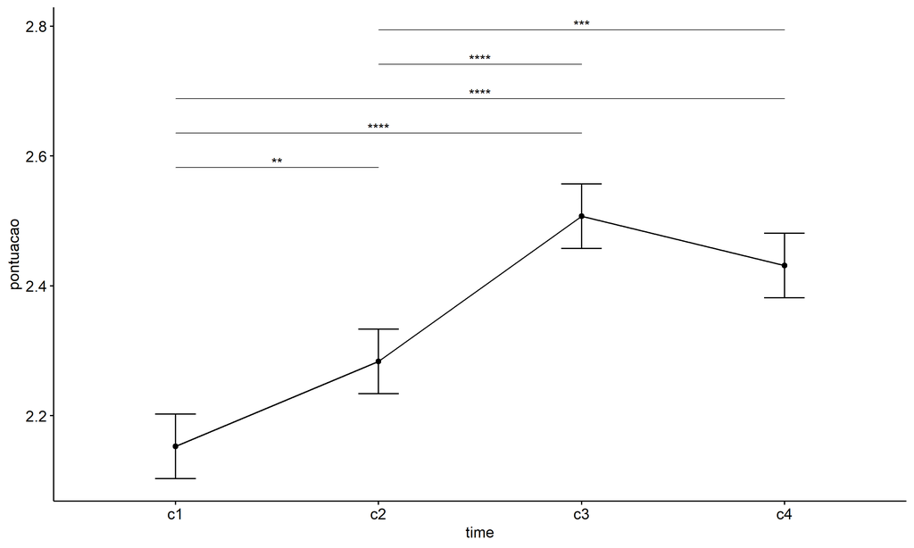

```r
pwc <- add_xy_position(pwc, x = "time", fun = "mean_se")
ggline(get_emmeans(pwc), x = "time", y = "emmean", ylab = "pontuacao") +
  geom_errorbar(aes(ymin = conf.low, ymax = conf.high), width = 0.2) +
  stat_pvalue_manual(pwc, hide.ns = T, tip.length = F)
```

# ANOVA: pontuacao ~ time*gender + Error(id/time)

## Data Preparation

```r
data <- edat[,c("aluno_id","gender","ciclo","pontuacao")]
data$ciclo <- factor(data$ciclo, c("Primeiro Ciclo","Segundo Ciclo",
                                   "Terceiro Ciclo","Quarto Ciclo"))

wdat <- spread(data, ciclo, pontuacao)
wdat <- wdat[complete.cases(wdat),]
colnames(wdat) <- c("id","gender","c1","c2","c3","c4")

ldat <- gather(wdat, key = time, value = pontuacao, c1, c2, c3, c4) %>%
  convert_as_factor(id, time)
ldat <- remove_group_data(ldat, "pontuacao", c("time", "gender"), n.limit = 30)
ldat$gender <- factor(ldat$gender, sort(unique(ldat$gender)))
```

### Check assumptions: Identifying Outliers

```r
outliers <- identify_outliers(group_by(ldat, time, gender), pontuacao)
(outliers <- outliers[outliers$is.extreme == T,])
```

```
## # A tibble: 650 × 6
##    gender time  id                   pontuacao is.outlier is.extreme
##    <fct>  <fct> <fct>                    <dbl> <lgl>      <lgl>
##  1 Female c1    0wDHSyctDDkjP6OPE3c8       5   TRUE       TRUE
##  2 Female c1    1DlydHhFt2IkhBETPR4s       3.5 TRUE       TRUE
##  3 Female c1    46nUNvt4sDOPsC9jnkiG       4.5 TRUE       TRUE
##  4 Female c1    55GlwifTTyiOSKTB9vc9       5   TRUE       TRUE
##  5 Female c1    5AeP0IQ84CerIQVenp2G       3   TRUE       TRUE
##  6 Female c1    6IoOZmGw52LYlznSYXzK       3   TRUE       TRUE
##  7 Female c1    6Xlhq905iNT5kvJFoSW5       5   TRUE       TRUE
##  8 Female c1    7AaMrLZQiyhSoBaer5VH       3.5 TRUE       TRUE
##  9 Female c1    A8Rx15QryUqDDm8ooiZr       3   TRUE       TRUE
## 10 Female c1    cy0oZFPyT8aGHBq7CR9A       3.5 TRUE       TRUE
## # ℹ 640 more rows
```

| gender | time | id | pontuacao | is.outlier | is.extreme |
| --- | --- | --- | --- | --- | --- |
| Female | c1 | 0wDHSyctDDkjP6OPE3c8 | 5.000 | TRUE | TRUE |
| Female | c1 | 1DlydHhFt2IkhBETPR4s | 3.500 | TRUE | TRUE |
| Female | c1 | 46nUNvt4sDOPsC9jnkiG | 4.500 | TRUE | TRUE |
| Female | c1 | 55GlwifTTyiOSKTB9vc9 | 5.000 | TRUE | TRUE |
| Female | c1 | 5AeP0IQ84CerIQVenp2G | 3.000 | TRUE | TRUE |
| Female | c1 | 6IoOZmGw52LYlznSYXzK | 3.000 | TRUE | TRUE |
| Female | c1 | 6Xlhq905iNT5kvJFoSW5 | 5.000 | TRUE | TRUE |
| Female | c1 | 7AaMrLZQiyhSoBaer5VH | 3.500 | TRUE | TRUE |
| Female | c1 | A8Rx15QryUqDDm8ooiZr | 3.000 | TRUE | TRUE |
| Female | c1 | cy0oZFPyT8aGHBq7CR9A | 3.500 | TRUE | TRUE |
| Female | c1 | dSM9U89FZYdICjBucW8v | 3.000 | TRUE | TRUE |
| Female | c1 | F5Ux4BYYqSnMt1Om6Trf | 3.500 | TRUE | TRUE |
| Female | c1 | g0SSATlv7RDhoBk6jsCz | 3.500 | TRUE | TRUE |
| Female | c1 | G2SUhDEavPTLyA8yz9AL | 3.500 | TRUE | TRUE |
| Female | c1 | G4NIt8gEc7nfeQ9k2OkL | 3.500 | TRUE | TRUE |
| Female | c1 | H8te97gR9TCOM0CiCXj1 | 3.500 | TRUE | TRUE |
| Female | c1 | I1x9Y5cYi4OfnwWUeTXz | 4.000 | TRUE | TRUE |
| Female | c1 | I5SKdDmPvNCpOHCfh7Is | 4.000 | TRUE | TRUE |
| Female | c1 | ixToGS5nyKWTy1PjTzZW | 3.000 | TRUE | TRUE |
| Female | c1 | Jgsj4or0goDAXdQU3UwR | 3.000 | TRUE | TRUE |
| Female | c1 | jVbbowshsqkUpPuGSIMu | 4.000 | TRUE | TRUE |
| Female | c1 | KPMkDhksSiEWVEIUT1LG | 3.500 | TRUE | TRUE |
| Female | c1 | KWsflPBHSK0g0ZYy9I1L | 5.000 | TRUE | TRUE |
| Female | c1 | lt4Za0V8VmneMBIicN4R | 3.000 | TRUE | TRUE |
| Female | c1 | m5yRlxfIj73j4ossfTOB | 5.000 | TRUE | TRUE |
| Female | c1 | MTyNplLkcaNxd9NT392Q | 3.500 | TRUE | TRUE |
| Female | c1 | N3zF1kdLVvTXfbcXiMqe | 3.500 | TRUE | TRUE |
| Female | c1 | pca9LmykrugFnjsHp7MR | 5.000 | TRUE | TRUE |
| Female | c1 | QasU7a9JiIu1XHAPVJk9 | 3.000 | TRUE | TRUE |
| Female | c1 | rijPm1LRjDwEh0XEZEeR | 4.000 | TRUE | TRUE |

[output cut: 620 more lines]

### Check assumptions: Normality Test

```r
(normality.df <- normality.test.per.groups(ldat, "pontuacao", c("time", "gender")))
```

```
##         var  variable time gender   n skewness  kurtosis symmetry statistic     method p
## 1 pontuacao pontuacao   c1 Female 552 4.218143 17.568957       NO  499.2658 D'Agostino 0
## 2 pontuacao pontuacao   c1   Male 513 3.521423 11.544590       NO  393.3180 D'Agostino 0
## 3 pontuacao pontuacao   c2 Female 552 2.631858  5.654764       NO  304.5950 D'Agostino 0
## 4 pontuacao pontuacao   c2   Male 513 2.898782  7.187295       NO  318.9391 D'Agostino 0
## 5 pontuacao pontuacao   c3 Female 552 1.745355  1.414569       NO  164.7113 D'Agostino 0
## 6 pontuacao pontuacao   c3   Male 513 1.688059  1.116492       NO  143.5729 D'Agostino 0
## 7 pontuacao pontuacao   c4 Female 552 1.925101  2.050858       NO  193.1415 D'Agostino 0
## 8 pontuacao pontuacao   c4   Male 513 2.074974  2.742117       NO  203.8188 D'Agostino 0
##   p.signif normality
## 1     ****         -
## 2     ****         -
## 3     ****         -
## 4     ****         -
## 5     ****         -
## 6     ****         -
## 7     ****         -
## 8     ****         -
```

| var | variable | time | gender | n | skewness | kurtosis | symmetry | statistic | method | p | p.signif | normality |
| --- | --- | --- | --- | --- | --- | --- | --- | --- | --- | --- | --- | --- |
| pontuacao | pontuacao | c1 | Female | 552 | 4.218 | 17.569 | NO | 499.266 | D’Agostino | 0 | **** | - |
| pontuacao | pontuacao | c1 | Male | 513 | 3.521 | 11.545 | NO | 393.318 | D’Agostino | 0 | **** | - |
| pontuacao | pontuacao | c2 | Female | 552 | 2.632 | 5.655 | NO | 304.595 | D’Agostino | 0 | **** | - |
| pontuacao | pontuacao | c2 | Male | 513 | 2.899 | 7.187 | NO | 318.939 | D’Agostino | 0 | **** | - |
| pontuacao | pontuacao | c3 | Female | 552 | 1.745 | 1.415 | NO | 164.711 | D’Agostino | 0 | **** | - |
| pontuacao | pontuacao | c3 | Male | 513 | 1.688 | 1.116 | NO | 143.573 | D’Agostino | 0 | **** | - |
| pontuacao | pontuacao | c4 | Female | 552 | 1.925 | 2.051 | NO | 193.142 | D’Agostino | 0 | **** | - |
| pontuacao | pontuacao | c4 | Male | 513 | 2.075 | 2.742 | NO | 203.819 | D’Agostino | 0 | **** | - |

```r
(non.ids <- unique(do.call(
  c, lapply(which(normality.df$normality == 'NO'), FUN = function(i) {
  idx = which(ldat$time == normality.df$time[i] &
                ldat$gender == normality.df$gender[i])
  getNonNormal(ldat$"pontuacao"[idx], ldat$id[idx])
}))))
```

```r
if (length(non.ids) > 0)
  ldat2 <- ldat[!ldat$id %in% non.ids,]
```

### Summary Statistics

```r
(sdat <- ldat %>% group_by(time, gender) %>%
   get_summary_stats(pontuacao, type = "mean_sd"))
```

```
## # A tibble: 8 × 6
##   gender time  variable      n  mean    sd
##   <fct>  <fct> <fct>     <dbl> <dbl> <dbl>
## 1 Female c1    pontuacao   552  2.14 0.536
## 2 Male   c1    pontuacao   513  2.19 0.637
## 3 Female c2    pontuacao   552  2.29 0.778
## 4 Male   c2    pontuacao   513  2.26 0.752
## 5 Female c3    pontuacao   552  2.49 1.00
## 6 Male   c3    pontuacao   513  2.52 1.05
## 7 Female c4    pontuacao   552  2.44 0.967
## 8 Male   c4    pontuacao   513  2.40 0.924
```

| gender | time | variable | n | mean | sd |
| --- | --- | --- | --- | --- | --- |
| Female | c1 | pontuacao | 552 | 2.136 | 0.536 |
| Male | c1 | pontuacao | 513 | 2.186 | 0.637 |
| Female | c2 | pontuacao | 552 | 2.289 | 0.778 |
| Male | c2 | pontuacao | 513 | 2.263 | 0.752 |
| Female | c3 | pontuacao | 552 | 2.493 | 1.003 |
| Male | c3 | pontuacao | 513 | 2.521 | 1.054 |
| Female | c4 | pontuacao | 552 | 2.438 | 0.967 |
| Male | c4 | pontuacao | 513 | 2.404 | 0.924 |

```r
if (length(non.ids) > 0)
  (sdat <- ldat2 %>% group_by(time, gender) %>%
      get_summary_stats(pontuacao, type = "mean_sd"))
```

| gender | time | variable | n | mean | sd |
| --- | --- | --- | --- | --- | --- |
| Female | c1 | pontuacao | 552 | 2.136 | 0.536 |
| Male | c1 | pontuacao | 513 | 2.186 | 0.637 |
| Female | c2 | pontuacao | 552 | 2.289 | 0.778 |
| Male | c2 | pontuacao | 513 | 2.263 | 0.752 |
| Female | c3 | pontuacao | 552 | 2.493 | 1.003 |
| Male | c3 | pontuacao | 513 | 2.521 | 1.054 |
| Female | c4 | pontuacao | 552 | 2.438 | 0.967 |
| Male | c4 | pontuacao | 513 | 2.404 | 0.924 |

## ANOVA Computation

```r
(res.aov <- anova_test(ldat, dv = pontuacao, wid = id, between = gender, within = time))
```

```
## ANOVA Table (type III tests)
##
## $ANOVA
##        Effect DFn  DFd      F        p p<.05      ges
## 1      gender   1 1063  0.024 8.78e-01       7.25e-06
## 2        time   3 3189 38.608 1.68e-24     * 2.40e-02
## 3 gender:time   3 3189  0.704 5.49e-01       4.47e-04
##
## $`Mauchly's Test for Sphericity`
##        Effect     W        p p<.05
## 1        time 0.914 5.07e-19     *
## 2 gender:time 0.914 5.07e-19     *
##
## $`Sphericity Corrections`
##        Effect  GGe        DF[GG]    p[GG] p[GG]<.05   HFe        DF[HF]    p[HF] p[HF]<.05
## 1        time 0.95 2.85, 3028.72 2.11e-23         * 0.953 2.86, 3037.71 1.83e-23         *
## 2 gender:time 0.95 2.85, 3028.72 5.42e-01           0.953 2.86, 3037.71 5.43e-01
```

| Effect | DFn | DFd | F | p | p<.05 | ges |
| --- | --- | --- | --- | --- | --- | --- |
| gender | 1 | 1063 | 0.024 | 0.878 |  | 0.000 |
| time | 3 | 3189 | 38.608 | 0.000 | * | 0.024 |
| gender:time | 3 | 3189 | 0.704 | 0.549 |  | 0.000 |

| Effect | W | p | p<.05 |
| --- | --- | --- | --- |
| time | 0.914 | 0 | * |
| gender:time | 0.914 | 0 | * |

| Effect | GGe | DF[GG] | p[GG] | p[GG]<.05 | HFe | DF[HF] | p[HF] | p[HF]<.05 |
| --- | --- | --- | --- | --- | --- | --- | --- | --- |
| time | 0.95 | 2.85, 3028.72 | 0.000 | * | 0.953 | 2.86, 3037.71 | 0.000 | * |
| gender:time | 0.95 | 2.85, 3028.72 | 0.542 |  | 0.953 | 2.86, 3037.71 | 0.543 |  |

## ANOVA Computation after removing non.normal data

```r
if (length(non.ids) > 0)
  (res.aov2 <- anova_test(ldat2, dv = pontuacao, wid = id, between = gender , within = time))
```

## PairWise Computation

```r
(pwc <- ldat %>% group_by(time) %>%
   emmeans_test(pontuacao ~ gender, detailed = T, p.adjust.method = "bonferroni"))
```

```
## # A tibble: 4 × 15
##   time  term   .y.    group1 group2 null.value estimate     se    df conf.low conf.high statistic
## * <fct> <chr>  <chr>  <chr>  <chr>       <dbl>    <dbl>  <dbl> <dbl>    <dbl>     <dbl>     <dbl>
## 1 c1    gender pontu… Female Male            0  -0.0503 0.0521  4252  -0.152     0.0518    -0.966
## 2 c2    gender pontu… Female Male            0   0.0258 0.0521  4252  -0.0763    0.128      0.496
## 3 c3    gender pontu… Female Male            0  -0.0287 0.0521  4252  -0.131     0.0734    -0.551
## 4 c4    gender pontu… Female Male            0   0.0349 0.0521  4252  -0.0672    0.137      0.670
## # ℹ 3 more variables: p <dbl>, p.adj <dbl>, p.adj.signif <chr>
```

| time | term | .y. | group1 | group2 | null.value | estimate | se | df | conf.low | conf.high | statistic | p | p.adj | p.adj.signif |
| --- | --- | --- | --- | --- | --- | --- | --- | --- | --- | --- | --- | --- | --- | --- |
| c1 | gender | pontuacao | Female | Male | 0 | -0.050 | 0.052 | 4252 | -0.152 | 0.052 | -0.966 | 0.334 | 0.334 | ns |
| c2 | gender | pontuacao | Female | Male | 0 | 0.026 | 0.052 | 4252 | -0.076 | 0.128 | 0.496 | 0.620 | 0.620 | ns |
| c3 | gender | pontuacao | Female | Male | 0 | -0.029 | 0.052 | 4252 | -0.131 | 0.073 | -0.551 | 0.582 | 0.582 | ns |
| c4 | gender | pontuacao | Female | Male | 0 | 0.035 | 0.052 | 4252 | -0.067 | 0.137 | 0.670 | 0.503 | 0.503 | ns |

```r
(emms <- get_emmeans(pwc))
```

```
## # A tibble: 8 × 8
##   time  gender emmean     se    df conf.low conf.high method
##   <fct> <fct>   <dbl>  <dbl> <dbl>    <dbl>     <dbl> <chr>
## 1 c1    Female   2.14 0.0361  4252     2.07      2.21 Emmeans test
## 2 c1    Male     2.19 0.0375  4252     2.11      2.26 Emmeans test
## 3 c2    Female   2.29 0.0361  4252     2.22      2.36 Emmeans test
## 4 c2    Male     2.26 0.0375  4252     2.19      2.34 Emmeans test
## 5 c3    Female   2.49 0.0361  4252     2.42      2.56 Emmeans test
## 6 c3    Male     2.52 0.0375  4252     2.45      2.59 Emmeans test
## 7 c4    Female   2.44 0.0361  4252     2.37      2.51 Emmeans test
## 8 c4    Male     2.40 0.0375  4252     2.33      2.48 Emmeans test
```

| time | gender | emmean | se | df | conf.low | conf.high | method |
| --- | --- | --- | --- | --- | --- | --- | --- |
| c1 | Female | 2.136 | 0.036 | 4252 | 2.065 | 2.207 | Emmeans test |
| c1 | Male | 2.186 | 0.037 | 4252 | 2.113 | 2.260 | Emmeans test |
| c2 | Female | 2.289 | 0.036 | 4252 | 2.218 | 2.360 | Emmeans test |
| c2 | Male | 2.263 | 0.037 | 4252 | 2.190 | 2.336 | Emmeans test |
| c3 | Female | 2.493 | 0.036 | 4252 | 2.422 | 2.564 | Emmeans test |
| c3 | Male | 2.521 | 0.037 | 4252 | 2.448 | 2.595 | Emmeans test |
| c4 | Female | 2.438 | 0.036 | 4252 | 2.368 | 2.509 | Emmeans test |
| c4 | Male | 2.404 | 0.037 | 4252 | 2.330 | 2.477 | Emmeans test |

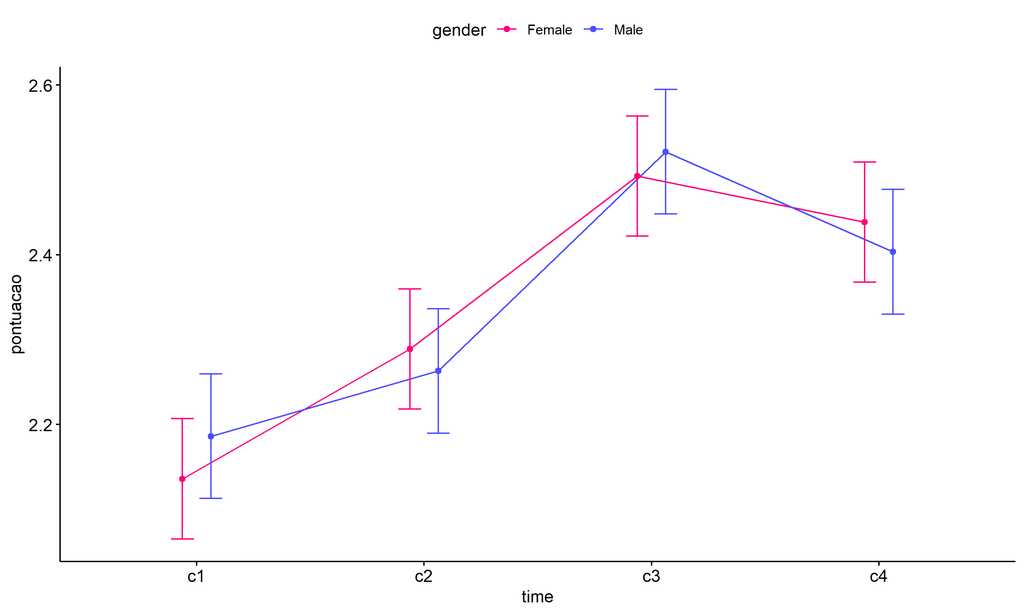

```r
pwc <- add_xy_position(pwc, x = "time", fun = "mean_se", dodge = 0.25)
pd <- position_dodge(width = 0.25)
ggline(emms, x = "time", y = "emmean", color = "gender",
       palette = c("#FF007F","#4D4DFF"),
       position = pd, ylab = "pontuacao") +
  geom_errorbar(aes(ymin = conf.low, ymax = conf.high, color = gender),
                position = pd, width = 0.2) +
  stat_pvalue_manual(pwc, hide.ns = T, tip.length = F, linetype = 1)
```

```r
(pwc <- ldat %>% group_by(gender) %>%
    emmeans_test(pontuacao ~ time, detailed = T, p.adjust.method = "bonferroni"))
```

```
## # A tibble: 12 × 15
##    gender term  .y.   group1 group2 null.value estimate     se    df conf.low conf.high statistic
##  * <fct>  <chr> <chr> <chr>  <chr>       <dbl>    <dbl>  <dbl> <dbl>    <dbl>     <dbl>     <dbl>
##  1 Female time  pont… c1     c2              0  -0.153  0.0511  4252  -0.253    -0.0527     -2.99
##  2 Female time  pont… c1     c3              0  -0.357  0.0511  4252  -0.457    -0.257      -6.98
##  3 Female time  pont… c1     c4              0  -0.303  0.0511  4252  -0.403    -0.202      -5.92
##  4 Female time  pont… c2     c3              0  -0.204  0.0511  4252  -0.304    -0.104      -3.99
##  5 Female time  pont… c2     c4              0  -0.150  0.0511  4252  -0.250    -0.0494     -2.93
##  6 Female time  pont… c3     c4              0   0.0543 0.0511  4252  -0.0458    0.155       1.06
##  7 Male   time  pont… c1     c2              0  -0.0768 0.0530  4252  -0.181     0.0271     -1.45
##  8 Male   time  pont… c1     c3              0  -0.335  0.0530  4252  -0.439    -0.231      -6.32
##  9 Male   time  pont… c1     c4              0  -0.217  0.0530  4252  -0.321    -0.113      -4.10
## 10 Male   time  pont… c2     c3              0  -0.258  0.0530  4252  -0.362    -0.155      -4.88
## 11 Male   time  pont… c2     c4              0  -0.141  0.0530  4252  -0.244    -0.0366     -2.65
## 12 Male   time  pont… c3     c4              0   0.118  0.0530  4252   0.0140    0.222       2.22
## # ℹ 3 more variables: p <dbl>, p.adj <dbl>, p.adj.signif <chr>
```

| gender | term | .y. | group1 | group2 | null.value | estimate | se | df | conf.low | conf.high | statistic | p | p.adj | p.adj.signif |
| --- | --- | --- | --- | --- | --- | --- | --- | --- | --- | --- | --- | --- | --- | --- |
| Female | time | pontuacao | c1 | c2 | 0 | -0.153 | 0.051 | 4252 | -0.253 | -0.053 | -2.992 | 0.003 | 0.017 | * |
| Female | time | pontuacao | c1 | c3 | 0 | -0.357 | 0.051 | 4252 | -0.457 | -0.257 | -6.983 | 0.000 | 0.000 | **** |
| Female | time | pontuacao | c1 | c4 | 0 | -0.303 | 0.051 | 4252 | -0.403 | -0.202 | -5.920 | 0.000 | 0.000 | **** |
| Female | time | pontuacao | c2 | c3 | 0 | -0.204 | 0.051 | 4252 | -0.304 | -0.104 | -3.991 | 0.000 | 0.000 | *** |
| Female | time | pontuacao | c2 | c4 | 0 | -0.150 | 0.051 | 4252 | -0.250 | -0.049 | -2.927 | 0.003 | 0.021 | * |
| Female | time | pontuacao | c3 | c4 | 0 | 0.054 | 0.051 | 4252 | -0.046 | 0.155 | 1.063 | 0.288 | 1.000 | ns |
| Male | time | pontuacao | c1 | c2 | 0 | -0.077 | 0.053 | 4252 | -0.181 | 0.027 | -1.449 | 0.147 | 0.884 | ns |
| Male | time | pontuacao | c1 | c3 | 0 | -0.335 | 0.053 | 4252 | -0.439 | -0.231 | -6.325 | 0.000 | 0.000 | **** |
| Male | time | pontuacao | c1 | c4 | 0 | -0.217 | 0.053 | 4252 | -0.321 | -0.113 | -4.100 | 0.000 | 0.000 | *** |
| Male | time | pontuacao | c2 | c3 | 0 | -0.258 | 0.053 | 4252 | -0.362 | -0.155 | -4.875 | 0.000 | 0.000 | **** |
| Male | time | pontuacao | c2 | c4 | 0 | -0.141 | 0.053 | 4252 | -0.244 | -0.037 | -2.651 | 0.008 | 0.048 | * |
| Male | time | pontuacao | c3 | c4 | 0 | 0.118 | 0.053 | 4252 | 0.014 | 0.222 | 2.225 | 0.026 | 0.157 | ns |

```r
(emms <- get_emmeans(pwc))
```

```
## # A tibble: 8 × 8
##   gender time  emmean     se    df conf.low conf.high method
##   <fct>  <fct>  <dbl>  <dbl> <dbl>    <dbl>     <dbl> <chr>
## 1 Female c1      2.14 0.0361  4252     2.07      2.21 Emmeans test
## 2 Female c2      2.29 0.0361  4252     2.22      2.36 Emmeans test
## 3 Female c3      2.49 0.0361  4252     2.42      2.56 Emmeans test
## 4 Female c4      2.44 0.0361  4252     2.37      2.51 Emmeans test
## 5 Male   c1      2.19 0.0375  4252     2.11      2.26 Emmeans test
## 6 Male   c2      2.26 0.0375  4252     2.19      2.34 Emmeans test
## 7 Male   c3      2.52 0.0375  4252     2.45      2.59 Emmeans test
## 8 Male   c4      2.40 0.0375  4252     2.33      2.48 Emmeans test
```

| gender | time | emmean | se | df | conf.low | conf.high | method |
| --- | --- | --- | --- | --- | --- | --- | --- |
| Female | c1 | 2.136 | 0.036 | 4252 | 2.065 | 2.207 | Emmeans test |
| Female | c2 | 2.289 | 0.036 | 4252 | 2.218 | 2.360 | Emmeans test |
| Female | c3 | 2.493 | 0.036 | 4252 | 2.422 | 2.564 | Emmeans test |
| Female | c4 | 2.438 | 0.036 | 4252 | 2.368 | 2.509 | Emmeans test |
| Male | c1 | 2.186 | 0.037 | 4252 | 2.113 | 2.260 | Emmeans test |
| Male | c2 | 2.263 | 0.037 | 4252 | 2.190 | 2.336 | Emmeans test |
| Male | c3 | 2.521 | 0.037 | 4252 | 2.448 | 2.595 | Emmeans test |
| Male | c4 | 2.404 | 0.037 | 4252 | 2.330 | 2.477 | Emmeans test |

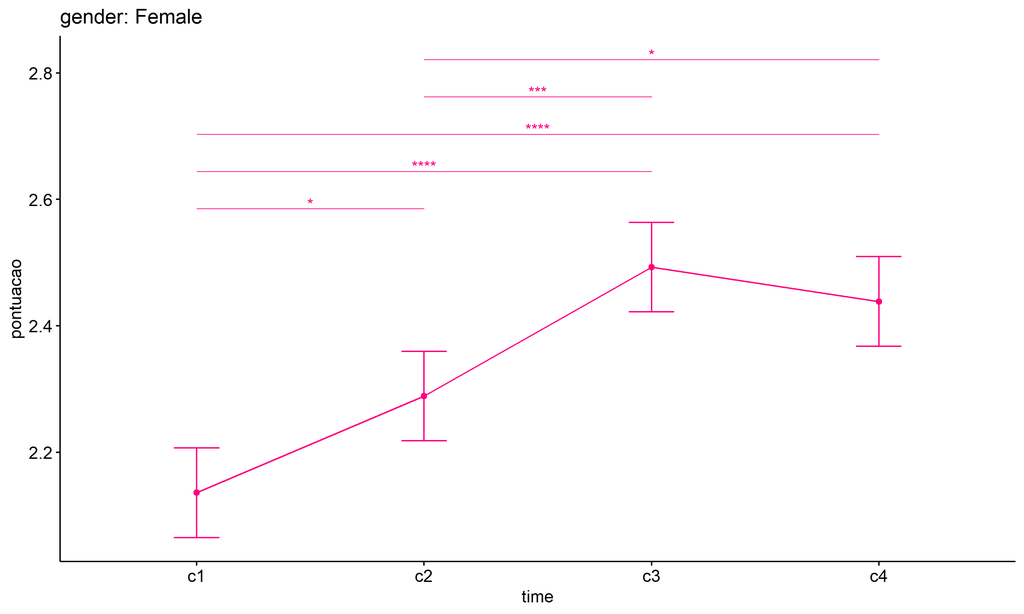

```r
emms.gg <- emms[which(emms$gender == "Female"),]
if (nrow(emms.gg) > 0)
  ggline(emms.gg, x = "time", y = "emmean", color = "#FF007F", ylab = "pontuacao") +
    geom_errorbar(aes(ymin = conf.low, ymax = conf.high),
                  width = 0.2, color = "#FF007F") +
    stat_pvalue_manual(
      add_xy_position(pwc[which(pwc$gender == "Female"),],
                      x = "time", fun = "mean_se"),
      hide.ns = T, color = "#FF007F", tip.length = F) +
    labs(title = "gender: Female")+
    theme(legend.text = element_blank())
```

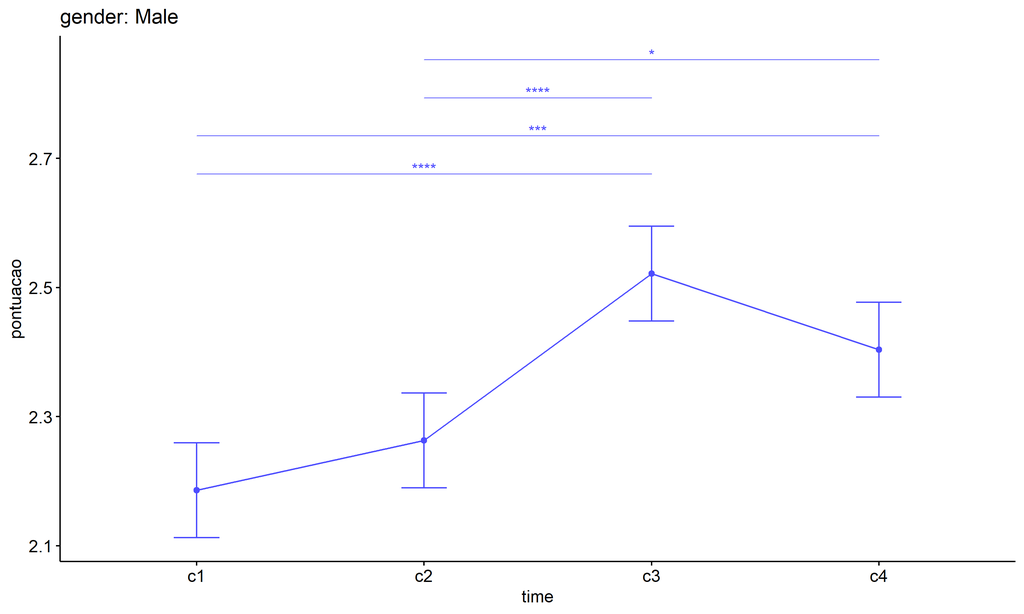

```r
emms.gg <- emms[which(emms$gender == "Male"),]
if (nrow(emms.gg) > 0)
  ggline(emms.gg, x = "time", y = "emmean", color = "#4D4DFF", ylab = "pontuacao") +
    geom_errorbar(aes(ymin = conf.low, ymax = conf.high),
                  width = 0.2, color = "#4D4DFF") +
    stat_pvalue_manual(
      add_xy_position(pwc[which(pwc$gender == "Male"),],
                      x = "time", fun = "mean_se"),
      hide.ns = T, color = "#4D4DFF", tip.length = F) +
    labs(title = "gender: Male")+
    theme(legend.text = element_blank())
```

## PairWise Computation after removing non.normal data

```r
if (length(non.ids) > 0)
  (pwc2 <- ldat2 %>% group_by(time) %>%
     emmeans_test(pontuacao ~ gender, detailed = T, p.adjust.method = "bonferroni"))
```

```r
if (length(non.ids) > 0)
  (emms2 <- get_emmeans(pwc2))
```

```r
if (length(non.ids) > 0) {
  pwc2 <- add_xy_position(pwc2, x = "time", fun = "mean_se", dodge = 0.25)
  pd2 <- position_dodge(width = 0.25)

  ggline(emms2, x = "time", y = "emmean", color = "gender",
         palette = c("#FF007F","#4D4DFF"),
         position = pd, ylab = "pontuacao") +
    geom_errorbar(aes(ymin = conf.low, ymax = conf.high, color = gender),
                position = pd, width = 0.2) +
    stat_pvalue_manual(pwc2, hide.ns = T, tip.length = F, linetype = 1)
}
```

```r
if (length(non.ids) > 0)
  (pwc2 <- ldat2 %>% group_by(gender) %>%
     emmeans_test(pontuacao ~ time, detailed = T, p.adjust.method = "bonferroni"))
```

```r
if (length(non.ids) > 0)
  (emms2 <- get_emmeans(pwc2))
```

```r
if (length(non.ids) > 0) {
  emms.gg <- emms2[which(emms2$gender == "Female"),]
  if (nrow(emms.gg) > 0)
    ggline(emms.gg, x = "time", y = "emmean", color = "#FF007F", ylab = "pontuacao") +
    geom_errorbar(aes(ymin = conf.low, ymax = conf.high),
                  width = 0.2, color = "#FF007F") +
    stat_pvalue_manual(
      add_xy_position(pwc[which(pwc$gender == "Female"),],
                      x = "time", fun = "mean_se"),
      hide.ns = T, color = "#FF007F", tip.length = F) +
    labs(title = "gender: Female") +
    theme(legend.text = element_blank())
}
```

```r
if (length(non.ids) > 0) {
  emms.gg <- emms2[which(emms2$gender == "Male"),]
  if (nrow(emms.gg) > 0)
    ggline(emms.gg, x = "time", y = "emmean", color = "#4D4DFF", ylab = "pontuacao") +
    geom_errorbar(aes(ymin = conf.low, ymax = conf.high),
                  width = 0.2, color = "#4D4DFF") +
    stat_pvalue_manual(
      add_xy_position(pwc[which(pwc$gender == "Male"),],
                      x = "time", fun = "mean_se"),
      hide.ns = T, color = "#4D4DFF", tip.length = F) +
    labs(title = "gender: Male") +
    theme(legend.text = element_blank())
}
```

# ANOVA: pontuacao ~ time*localizacao + Error(id/time)

## Data Preparation

```r
data <- edat[,c("aluno_id","localizacao","ciclo","pontuacao")]
data$ciclo <- factor(data$ciclo, c("Primeiro Ciclo","Segundo Ciclo",
                                   "Terceiro Ciclo","Quarto Ciclo"))

wdat <- spread(data, ciclo, pontuacao)
wdat <- wdat[complete.cases(wdat),]
colnames(wdat) <- c("id","localizacao","c1","c2","c3","c4")

ldat <- gather(wdat, key = time, value = pontuacao, c1, c2, c3, c4) %>%
  convert_as_factor(id, time)
ldat <- remove_group_data(ldat, "pontuacao", c("time", "localizacao"), n.limit = 30)
ldat$localizacao <- factor(ldat$localizacao, sort(unique(ldat$localizacao)))
```

### Check assumptions: Identifying Outliers

```r
outliers <- identify_outliers(group_by(ldat, time, localizacao), pontuacao)
(outliers <- outliers[outliers$is.extreme == T,])
```

```
## # A tibble: 643 × 6
##    localizacao time  id                   pontuacao is.outlier is.extreme
##    <fct>       <fct> <fct>                    <dbl> <lgl>      <lgl>
##  1 Rural       c1    0w3VhiMf67CbcpR6aZCL       5   TRUE       TRUE
##  2 Rural       c1    1PlxEF4tmJySD3G46PLB       3.5 TRUE       TRUE
##  3 Rural       c1    D1HfJKTVqjrpCJx97l3v       5   TRUE       TRUE
##  4 Rural       c1    dieaAtUumyYxX7zGb7Sb       4   TRUE       TRUE
##  5 Rural       c1    DKEsQosaERswlkB803hB       3.5 TRUE       TRUE
##  6 Rural       c1    iutpBZMAtM92qcbyCDHB       3.5 TRUE       TRUE
##  7 Rural       c1    iXqE1bAFPsYn56jTzZQS       5   TRUE       TRUE
##  8 Rural       c1    rijPm1LRjDwEh0XEZEeR       4   TRUE       TRUE
##  9 Rural       c1    snoeXZt7a8Ds16UvPGhk       5   TRUE       TRUE
## 10 Rural       c1    xAo0TzCEx1bIrmjqKgbj       3.5 TRUE       TRUE
## # ℹ 633 more rows
```

| localizacao | time | id | pontuacao | is.outlier | is.extreme |
| --- | --- | --- | --- | --- | --- |
| Rural | c1 | 0w3VhiMf67CbcpR6aZCL | 5.000 | TRUE | TRUE |
| Rural | c1 | 1PlxEF4tmJySD3G46PLB | 3.500 | TRUE | TRUE |
| Rural | c1 | D1HfJKTVqjrpCJx97l3v | 5.000 | TRUE | TRUE |
| Rural | c1 | dieaAtUumyYxX7zGb7Sb | 4.000 | TRUE | TRUE |
| Rural | c1 | DKEsQosaERswlkB803hB | 3.500 | TRUE | TRUE |
| Rural | c1 | iutpBZMAtM92qcbyCDHB | 3.500 | TRUE | TRUE |
| Rural | c1 | iXqE1bAFPsYn56jTzZQS | 5.000 | TRUE | TRUE |
| Rural | c1 | rijPm1LRjDwEh0XEZEeR | 4.000 | TRUE | TRUE |
| Rural | c1 | snoeXZt7a8Ds16UvPGhk | 5.000 | TRUE | TRUE |
| Rural | c1 | xAo0TzCEx1bIrmjqKgbj | 3.500 | TRUE | TRUE |
| Rural | c1 | xZ5yKSWaJFp2osYZSjqL | 5.000 | TRUE | TRUE |
| Urbana | c1 | 0wDHSyctDDkjP6OPE3c8 | 5.000 | TRUE | TRUE |
| Urbana | c1 | 1DlydHhFt2IkhBETPR4s | 3.500 | TRUE | TRUE |
| Urbana | c1 | 1Z1Qz8zDaMkaAz1Ah80K | 5.000 | TRUE | TRUE |
| Urbana | c1 | 46nUNvt4sDOPsC9jnkiG | 4.500 | TRUE | TRUE |
| Urbana | c1 | 4hmXg2uo4wxSAX9SaxpN | 3.500 | TRUE | TRUE |
| Urbana | c1 | 55GlwifTTyiOSKTB9vc9 | 5.000 | TRUE | TRUE |
| Urbana | c1 | 5AeP0IQ84CerIQVenp2G | 3.000 | TRUE | TRUE |
| Urbana | c1 | 6IoOZmGw52LYlznSYXzK | 3.000 | TRUE | TRUE |
| Urbana | c1 | 6oE4k979jigSP7Zbs2m1 | 3.500 | TRUE | TRUE |
| Urbana | c1 | 6Xlhq905iNT5kvJFoSW5 | 5.000 | TRUE | TRUE |
| Urbana | c1 | 7AaMrLZQiyhSoBaer5VH | 3.500 | TRUE | TRUE |
| Urbana | c1 | 7nfO1ouMUuN7IzvlCKr0 | 3.500 | TRUE | TRUE |
| Urbana | c1 | A5EETpEr617bpnSh1wp6 | 3.500 | TRUE | TRUE |
| Urbana | c1 | A8Rx15QryUqDDm8ooiZr | 3.000 | TRUE | TRUE |
| Urbana | c1 | AIzwxJCfbDsO8ZT4ZZ4h | 3.000 | TRUE | TRUE |
| Urbana | c1 | b9PlhVhdvhl9EPK9QVCv | 5.000 | TRUE | TRUE |
| Urbana | c1 | cao1agmzaedA3s0PVAPS | 5.000 | TRUE | TRUE |
| Urbana | c1 | cJoqgrk6T3HsA9EOVe7D | 5.000 | TRUE | TRUE |
| Urbana | c1 | cuknOzzwN4oCRum5U5ph | 3.500 | TRUE | TRUE |

[output cut: 613 more lines]

### Check assumptions: Normality Test

```r
(normality.df <- normality.test.per.groups(ldat, "pontuacao", c("time", "localizacao")))
```

```
##         var  variable time localizacao   n skewness   kurtosis symmetry statistic     method
## 1 pontuacao pontuacao   c1       Rural 181 4.162619 16.4928470       NO 184.39942 D'Agostino
## 2 pontuacao pontuacao   c1      Urbana 945 3.913783 14.8528182       NO 775.46898 D'Agostino
## 3 pontuacao pontuacao   c2       Rural 181 1.999775  2.4681499       NO  76.12166 D'Agostino
## 4 pontuacao pontuacao   c2      Urbana 945 2.889005  7.1911450       NO 566.93883 D'Agostino
## 5 pontuacao pontuacao   c3       Rural 181 1.353035  0.0900018       NO  37.58895 D'Agostino
## 6 pontuacao pontuacao   c3      Urbana 945 1.801801  1.5755002       NO 289.39065 D'Agostino
## 7 pontuacao pontuacao   c4       Rural 181 1.612750  0.8743228       NO  51.60505 D'Agostino
## 8 pontuacao pontuacao   c4      Urbana 945 2.034024  2.5394339       NO 352.83107 D'Agostino
##              p p.signif normality
## 1 0.000000e+00     ****        QQ
## 2 0.000000e+00     ****         -
## 3 0.000000e+00     ****        QQ
## 4 0.000000e+00     ****         -
## 5 6.881174e-09     ****        QQ
## 6 0.000000e+00     ****         -
## 7 6.224465e-12     ****        QQ
## 8 0.000000e+00     ****         -
```

| var | variable | time | localizacao | n | skewness | kurtosis | symmetry | statistic | method | p | p.signif | normality |
| --- | --- | --- | --- | --- | --- | --- | --- | --- | --- | --- | --- | --- |
| pontuacao | pontuacao | c1 | Rural | 181 | 4.163 | 16.493 | NO | 184.399 | D’Agostino | 0 | **** | QQ |
| pontuacao | pontuacao | c1 | Urbana | 945 | 3.914 | 14.853 | NO | 775.469 | D’Agostino | 0 | **** | - |
| pontuacao | pontuacao | c2 | Rural | 181 | 2.000 | 2.468 | NO | 76.122 | D’Agostino | 0 | **** | QQ |
| pontuacao | pontuacao | c2 | Urbana | 945 | 2.889 | 7.191 | NO | 566.939 | D’Agostino | 0 | **** | - |
| pontuacao | pontuacao | c3 | Rural | 181 | 1.353 | 0.090 | NO | 37.589 | D’Agostino | 0 | **** | QQ |
| pontuacao | pontuacao | c3 | Urbana | 945 | 1.802 | 1.576 | NO | 289.391 | D’Agostino | 0 | **** | - |
| pontuacao | pontuacao | c4 | Rural | 181 | 1.613 | 0.874 | NO | 51.605 | D’Agostino | 0 | **** | QQ |
| pontuacao | pontuacao | c4 | Urbana | 945 | 2.034 | 2.539 | NO | 352.831 | D’Agostino | 0 | **** | - |

```r
(non.ids <- unique(do.call(
  c, lapply(which(normality.df$normality == 'NO'), FUN = function(i) {
  idx = which(ldat$time == normality.df$time[i] &
                ldat$localizacao == normality.df$localizacao[i])
  getNonNormal(ldat$"pontuacao"[idx], ldat$id[idx])
}))))
```

```r
if (length(non.ids) > 0)
  ldat2 <- ldat[!ldat$id %in% non.ids,]
```

### Summary Statistics

```r
(sdat <- ldat %>% group_by(time, localizacao) %>%
   get_summary_stats(pontuacao, type = "mean_sd"))
```

```
## # A tibble: 8 × 6
##   localizacao time  variable      n  mean    sd
##   <fct>       <fct> <fct>     <dbl> <dbl> <dbl>
## 1 Rural       c1    pontuacao   181  2.14 0.57
## 2 Urbana      c1    pontuacao   945  2.16 0.575
## 3 Rural       c2    pontuacao   181  2.42 0.929
## 4 Urbana      c2    pontuacao   945  2.26 0.737
## 5 Rural       c3    pontuacao   181  2.64 1.13
## 6 Urbana      c3    pontuacao   945  2.48 1.01
## 7 Rural       c4    pontuacao   181  2.54 1.07
## 8 Urbana      c4    pontuacao   945  2.41 0.932
```

| localizacao | time | variable | n | mean | sd |
| --- | --- | --- | --- | --- | --- |
| Rural | c1 | pontuacao | 181 | 2.138 | 0.570 |
| Urbana | c1 | pontuacao | 945 | 2.156 | 0.575 |
| Rural | c2 | pontuacao | 181 | 2.417 | 0.929 |
| Urbana | c2 | pontuacao | 945 | 2.258 | 0.737 |
| Rural | c3 | pontuacao | 181 | 2.641 | 1.131 |
| Urbana | c3 | pontuacao | 945 | 2.481 | 1.007 |
| Rural | c4 | pontuacao | 181 | 2.544 | 1.069 |
| Urbana | c4 | pontuacao | 945 | 2.410 | 0.932 |

```r
if (length(non.ids) > 0)
  (sdat <- ldat2 %>% group_by(time, localizacao) %>%
      get_summary_stats(pontuacao, type = "mean_sd"))
```

| localizacao | time | variable | n | mean | sd |
| --- | --- | --- | --- | --- | --- |
| Rural | c1 | pontuacao | 181 | 2.138 | 0.570 |
| Urbana | c1 | pontuacao | 945 | 2.156 | 0.575 |
| Rural | c2 | pontuacao | 181 | 2.417 | 0.929 |
| Urbana | c2 | pontuacao | 945 | 2.258 | 0.737 |
| Rural | c3 | pontuacao | 181 | 2.641 | 1.131 |
| Urbana | c3 | pontuacao | 945 | 2.481 | 1.007 |
| Rural | c4 | pontuacao | 181 | 2.544 | 1.069 |
| Urbana | c4 | pontuacao | 945 | 2.410 | 0.932 |

## ANOVA Computation

```r
(res.aov <- anova_test(ldat, dv = pontuacao, wid = id, between = localizacao, within = time))
```

```
## ANOVA Table (type III tests)
##
## $ANOVA
##             Effect DFn  DFd      F        p p<.05   ges
## 1      localizacao   1 1124  7.611 6.00e-03     * 0.002
## 2             time   3 3372 30.739 1.34e-19     * 0.018
## 3 localizacao:time   3 3372  1.695 1.66e-01       0.001
##
## $`Mauchly's Test for Sphericity`
##             Effect     W        p p<.05
## 1             time 0.913 2.36e-20     *
## 2 localizacao:time 0.913 2.36e-20     *
##
## $`Sphericity Corrections`
##             Effect   GGe       DF[GG]    p[GG] p[GG]<.05   HFe        DF[HF]    p[HF] p[HF]<.05
## 1             time 0.949 2.85, 3200.8 9.87e-19         * 0.952 2.86, 3209.78 8.89e-19         *
## 2 localizacao:time 0.949 2.85, 3200.8 1.69e-01           0.952 2.86, 3209.78 1.69e-01
```

| Effect | DFn | DFd | F | p | p<.05 | ges |
| --- | --- | --- | --- | --- | --- | --- |
| localizacao | 1 | 1124 | 7.611 | 0.006 | * | 0.002 |
| time | 3 | 3372 | 30.739 | 0.000 | * | 0.018 |
| localizacao:time | 3 | 3372 | 1.695 | 0.166 |  | 0.001 |

| Effect | W | p | p<.05 |
| --- | --- | --- | --- |
| time | 0.913 | 0 | * |
| localizacao:time | 0.913 | 0 | * |

| Effect | GGe | DF[GG] | p[GG] | p[GG]<.05 | HFe | DF[HF] | p[HF] | p[HF]<.05 |
| --- | --- | --- | --- | --- | --- | --- | --- | --- |
| time | 0.949 | 2.85, 3200.8 | 0.000 | * | 0.952 | 2.86, 3209.78 | 0.000 | * |
| localizacao:time | 0.949 | 2.85, 3200.8 | 0.169 |  | 0.952 | 2.86, 3209.78 | 0.169 |  |

## ANOVA Computation after removing non.normal data

```r
if (length(non.ids) > 0)
  (res.aov2 <- anova_test(ldat2, dv = pontuacao, wid = id, between = localizacao , within = time))
```

## PairWise Computation

```r
(pwc <- ldat %>% group_by(time) %>%
   emmeans_test(pontuacao ~ localizacao, detailed = T, p.adjust.method = "bonferroni"))
```

```
## # A tibble: 4 × 15
##   time  term    .y.   group1 group2 null.value estimate     se    df conf.low conf.high statistic
## * <fct> <chr>   <chr> <chr>  <chr>       <dbl>    <dbl>  <dbl> <dbl>    <dbl>     <dbl>     <dbl>
## 1 c1    locali… pont… Rural  Urbana          0  -0.0174 0.0690  4496 -1.53e-1     0.118    -0.253
## 2 c2    locali… pont… Rural  Urbana          0   0.159  0.0690  4496  2.39e-2     0.294     2.31
## 3 c3    locali… pont… Rural  Urbana          0   0.159  0.0690  4496  2.42e-2     0.295     2.31
## 4 c4    locali… pont… Rural  Urbana          0   0.135  0.0690  4496 -5.77e-4     0.270     1.95
## # ℹ 3 more variables: p <dbl>, p.adj <dbl>, p.adj.signif <chr>
```

| time | term | .y. | group1 | group2 | null.value | estimate | se | df | conf.low | conf.high | statistic | p | p.adj | p.adj.signif |
| --- | --- | --- | --- | --- | --- | --- | --- | --- | --- | --- | --- | --- | --- | --- |
| c1 | localizacao | pontuacao | Rural | Urbana | 0 | -0.017 | 0.069 | 4496 | -0.153 | 0.118 | -0.253 | 0.801 | 0.801 | ns |
| c2 | localizacao | pontuacao | Rural | Urbana | 0 | 0.159 | 0.069 | 4496 | 0.024 | 0.294 | 2.306 | 0.021 | 0.021 | * |
| c3 | localizacao | pontuacao | Rural | Urbana | 0 | 0.159 | 0.069 | 4496 | 0.024 | 0.295 | 2.311 | 0.021 | 0.021 | * |
| c4 | localizacao | pontuacao | Rural | Urbana | 0 | 0.135 | 0.069 | 4496 | -0.001 | 0.270 | 1.952 | 0.051 | 0.051 | ns |

```r
(emms <- get_emmeans(pwc))
```

```
## # A tibble: 8 × 8
##   time  localizacao emmean     se    df conf.low conf.high method
##   <fct> <fct>        <dbl>  <dbl> <dbl>    <dbl>     <dbl> <chr>
## 1 c1    Rural         2.14 0.0632  4496     2.01      2.26 Emmeans test
## 2 c1    Urbana        2.16 0.0277  4496     2.10      2.21 Emmeans test
## 3 c2    Rural         2.42 0.0632  4496     2.29      2.54 Emmeans test
## 4 c2    Urbana        2.26 0.0277  4496     2.20      2.31 Emmeans test
## 5 c3    Rural         2.64 0.0632  4496     2.52      2.76 Emmeans test
## 6 c3    Urbana        2.48 0.0277  4496     2.43      2.54 Emmeans test
## 7 c4    Rural         2.54 0.0632  4496     2.42      2.67 Emmeans test
## 8 c4    Urbana        2.41 0.0277  4496     2.36      2.46 Emmeans test
```

| time | localizacao | emmean | se | df | conf.low | conf.high | method |
| --- | --- | --- | --- | --- | --- | --- | --- |
| c1 | Rural | 2.138 | 0.063 | 4496 | 2.014 | 2.262 | Emmeans test |
| c1 | Urbana | 2.156 | 0.028 | 4496 | 2.101 | 2.210 | Emmeans test |
| c2 | Rural | 2.417 | 0.063 | 4496 | 2.293 | 2.541 | Emmeans test |
| c2 | Urbana | 2.258 | 0.028 | 4496 | 2.204 | 2.312 | Emmeans test |
| c3 | Rural | 2.641 | 0.063 | 4496 | 2.517 | 2.765 | Emmeans test |
| c3 | Urbana | 2.481 | 0.028 | 4496 | 2.427 | 2.536 | Emmeans test |
| c4 | Rural | 2.544 | 0.063 | 4496 | 2.420 | 2.668 | Emmeans test |
| c4 | Urbana | 2.410 | 0.028 | 4496 | 2.355 | 2.464 | Emmeans test |

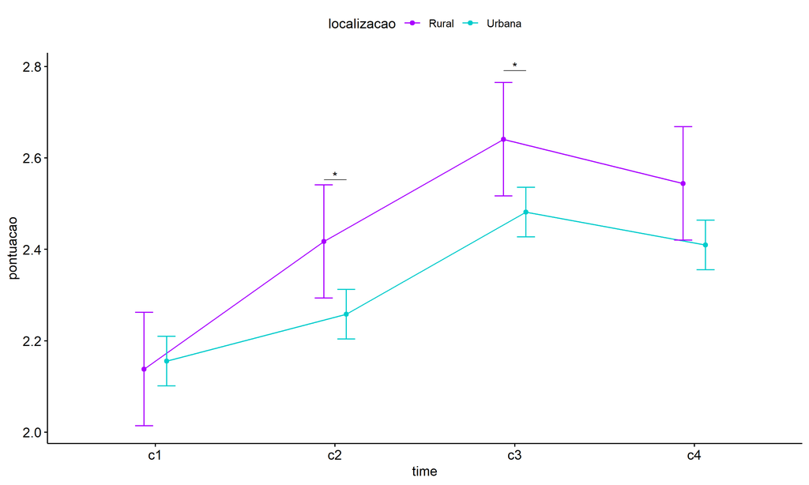

```r
pwc <- add_xy_position(pwc, x = "time", fun = "mean_se", dodge = 0.25)
pd <- position_dodge(width = 0.25)
ggline(emms, x = "time", y = "emmean", color = "localizacao",
       palette = c("#AA00FF","#00CCCC"),
       position = pd, ylab = "pontuacao") +
  geom_errorbar(aes(ymin = conf.low, ymax = conf.high, color = localizacao),
                position = pd, width = 0.2) +
  stat_pvalue_manual(pwc, hide.ns = T, tip.length = F, linetype = 1)
```

```r
(pwc <- ldat %>% group_by(localizacao) %>%
    emmeans_test(pontuacao ~ time, detailed = T, p.adjust.method = "bonferroni"))
```

```
## # A tibble: 12 × 15
##    localizacao term  .y.       group1 group2 null.value estimate     se    df conf.low conf.high
##  * <fct>       <chr> <chr>     <chr>  <chr>       <dbl>    <dbl>  <dbl> <dbl>    <dbl>     <dbl>
##  1 Rural       time  pontuacao c1     c2              0  -0.279  0.0894  4496 -0.454     -0.104
##  2 Rural       time  pontuacao c1     c3              0  -0.503  0.0894  4496 -0.678     -0.328
##  3 Rural       time  pontuacao c1     c4              0  -0.406  0.0894  4496 -0.581     -0.231
##  4 Rural       time  pontuacao c2     c3              0  -0.224  0.0894  4496 -0.399     -0.0485
##  5 Rural       time  pontuacao c2     c4              0  -0.127  0.0894  4496 -0.302      0.0482
##  6 Rural       time  pontuacao c3     c4              0   0.0967 0.0894  4496 -0.0785     0.272
##  7 Urbana      time  pontuacao c1     c2              0  -0.102  0.0391  4496 -0.179     -0.0258
##  8 Urbana      time  pontuacao c1     c3              0  -0.326  0.0391  4496 -0.403     -0.249
##  9 Urbana      time  pontuacao c1     c4              0  -0.254  0.0391  4496 -0.331     -0.177
## 10 Urbana      time  pontuacao c2     c3              0  -0.223  0.0391  4496 -0.300     -0.147
## 11 Urbana      time  pontuacao c2     c4              0  -0.151  0.0391  4496 -0.228     -0.0748
## 12 Urbana      time  pontuacao c3     c4              0   0.0720 0.0391  4496 -0.00473    0.149
## # ℹ 4 more variables: statistic <dbl>, p <dbl>, p.adj <dbl>, p.adj.signif <chr>
```

| localizacao | term | .y. | group1 | group2 | null.value | estimate | se | df | conf.low | conf.high | statistic | p | p.adj | p.adj.signif |
| --- | --- | --- | --- | --- | --- | --- | --- | --- | --- | --- | --- | --- | --- | --- |
| Rural | time | pontuacao | c1 | c2 | 0 | -0.279 | 0.089 | 4496 | -0.454 | -0.104 | -3.122 | 0.002 | 0.011 | * |
| Rural | time | pontuacao | c1 | c3 | 0 | -0.503 | 0.089 | 4496 | -0.678 | -0.328 | -5.625 | 0.000 | 0.000 | **** |
| Rural | time | pontuacao | c1 | c4 | 0 | -0.406 | 0.089 | 4496 | -0.581 | -0.231 | -4.543 | 0.000 | 0.000 | **** |
| Rural | time | pontuacao | c2 | c3 | 0 | -0.224 | 0.089 | 4496 | -0.399 | -0.049 | -2.503 | 0.012 | 0.074 | ns |
| Rural | time | pontuacao | c2 | c4 | 0 | -0.127 | 0.089 | 4496 | -0.302 | 0.048 | -1.422 | 0.155 | 0.931 | ns |
| Rural | time | pontuacao | c3 | c4 | 0 | 0.097 | 0.089 | 4496 | -0.079 | 0.272 | 1.082 | 0.279 | 1.000 | ns |
| Urbana | time | pontuacao | c1 | c2 | 0 | -0.102 | 0.039 | 4496 | -0.179 | -0.026 | -2.620 | 0.009 | 0.053 | ns |
| Urbana | time | pontuacao | c1 | c3 | 0 | -0.326 | 0.039 | 4496 | -0.403 | -0.249 | -8.332 | 0.000 | 0.000 | **** |
| Urbana | time | pontuacao | c1 | c4 | 0 | -0.254 | 0.039 | 4496 | -0.331 | -0.177 | -6.493 | 0.000 | 0.000 | **** |
| Urbana | time | pontuacao | c2 | c3 | 0 | -0.223 | 0.039 | 4496 | -0.300 | -0.147 | -5.713 | 0.000 | 0.000 | **** |
| Urbana | time | pontuacao | c2 | c4 | 0 | -0.151 | 0.039 | 4496 | -0.228 | -0.075 | -3.873 | 0.000 | 0.001 | *** |
| Urbana | time | pontuacao | c3 | c4 | 0 | 0.072 | 0.039 | 4496 | -0.005 | 0.149 | 1.840 | 0.066 | 0.395 | ns |

```r
(emms <- get_emmeans(pwc))
```

```
## # A tibble: 8 × 8
##   localizacao time  emmean     se    df conf.low conf.high method
##   <fct>       <fct>  <dbl>  <dbl> <dbl>    <dbl>     <dbl> <chr>
## 1 Rural       c1      2.14 0.0632  4496     2.01      2.26 Emmeans test
## 2 Rural       c2      2.42 0.0632  4496     2.29      2.54 Emmeans test
## 3 Rural       c3      2.64 0.0632  4496     2.52      2.76 Emmeans test
## 4 Rural       c4      2.54 0.0632  4496     2.42      2.67 Emmeans test
## 5 Urbana      c1      2.16 0.0277  4496     2.10      2.21 Emmeans test
## 6 Urbana      c2      2.26 0.0277  4496     2.20      2.31 Emmeans test
## 7 Urbana      c3      2.48 0.0277  4496     2.43      2.54 Emmeans test
## 8 Urbana      c4      2.41 0.0277  4496     2.36      2.46 Emmeans test
```

| localizacao | time | emmean | se | df | conf.low | conf.high | method |
| --- | --- | --- | --- | --- | --- | --- | --- |
| Rural | c1 | 2.138 | 0.063 | 4496 | 2.014 | 2.262 | Emmeans test |
| Rural | c2 | 2.417 | 0.063 | 4496 | 2.293 | 2.541 | Emmeans test |
| Rural | c3 | 2.641 | 0.063 | 4496 | 2.517 | 2.765 | Emmeans test |
| Rural | c4 | 2.544 | 0.063 | 4496 | 2.420 | 2.668 | Emmeans test |
| Urbana | c1 | 2.156 | 0.028 | 4496 | 2.101 | 2.210 | Emmeans test |
| Urbana | c2 | 2.258 | 0.028 | 4496 | 2.204 | 2.312 | Emmeans test |
| Urbana | c3 | 2.481 | 0.028 | 4496 | 2.427 | 2.536 | Emmeans test |
| Urbana | c4 | 2.410 | 0.028 | 4496 | 2.355 | 2.464 | Emmeans test |

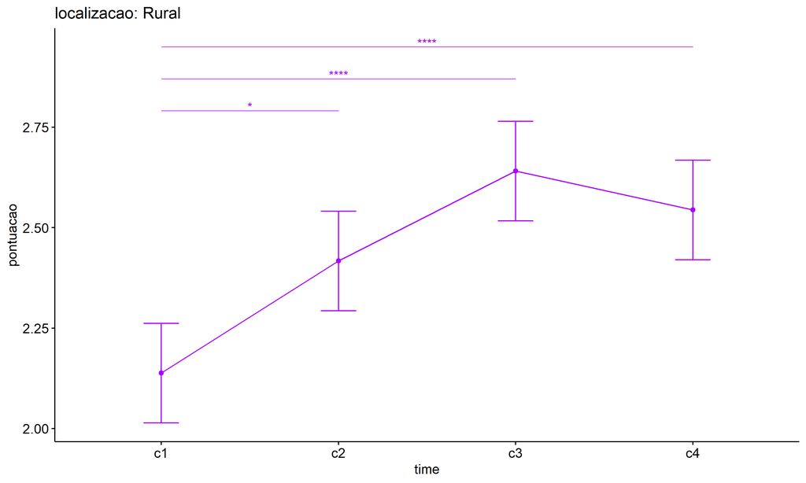

```r
emms.gg <- emms[which(emms$localizacao == "Rural"),]
if (nrow(emms.gg) > 0)
  ggline(emms.gg, x = "time", y = "emmean", color = "#AA00FF", ylab = "pontuacao") +
    geom_errorbar(aes(ymin = conf.low, ymax = conf.high),
                  width = 0.2, color = "#AA00FF") +
    stat_pvalue_manual(
      add_xy_position(pwc[which(pwc$localizacao == "Rural"),],
                      x = "time", fun = "mean_se"),
      hide.ns = T, color = "#AA00FF", tip.length = F) +
    labs(title = "localizacao: Rural")+
    theme(legend.text = element_blank())
```

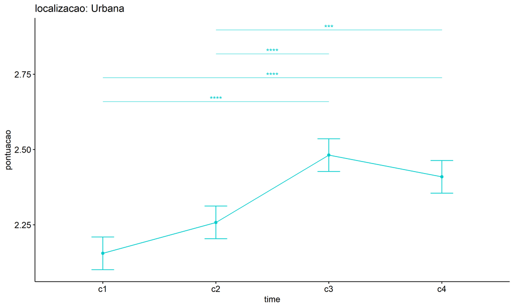

```r
emms.gg <- emms[which(emms$localizacao == "Urbana"),]
if (nrow(emms.gg) > 0)
  ggline(emms.gg, x = "time", y = "emmean", color = "#00CCCC", ylab = "pontuacao") +
    geom_errorbar(aes(ymin = conf.low, ymax = conf.high),
                  width = 0.2, color = "#00CCCC") +
    stat_pvalue_manual(
      add_xy_position(pwc[which(pwc$localizacao == "Urbana"),],
                      x = "time", fun = "mean_se"),
      hide.ns = T, color = "#00CCCC", tip.length = F) +
    labs(title = "localizacao: Urbana")+
    theme(legend.text = element_blank())
```

## PairWise Computation after removing non.normal data

```r
if (length(non.ids) > 0)
  (pwc2 <- ldat2 %>% group_by(time) %>%
     emmeans_test(pontuacao ~ localizacao, detailed = T, p.adjust.method = "bonferroni"))
```

```r
if (length(non.ids) > 0)
  (emms2 <- get_emmeans(pwc2))
```

```r
if (length(non.ids) > 0) {
  pwc2 <- add_xy_position(pwc2, x = "time", fun = "mean_se", dodge = 0.25)
  pd2 <- position_dodge(width = 0.25)

  ggline(emms2, x = "time", y = "emmean", color = "localizacao",
         palette = c("#AA00FF","#00CCCC"),
         position = pd, ylab = "pontuacao") +
    geom_errorbar(aes(ymin = conf.low, ymax = conf.high, color = localizacao),
                position = pd, width = 0.2) +
    stat_pvalue_manual(pwc2, hide.ns = T, tip.length = F, linetype = 1)
}
```

```r
if (length(non.ids) > 0)
  (pwc2 <- ldat2 %>% group_by(localizacao) %>%
     emmeans_test(pontuacao ~ time, detailed = T, p.adjust.method = "bonferroni"))
```

```r
if (length(non.ids) > 0)
  (emms2 <- get_emmeans(pwc2))
```

```r
if (length(non.ids) > 0) {
  emms.gg <- emms2[which(emms2$localizacao == "Rural"),]
  if (nrow(emms.gg) > 0)
    ggline(emms.gg, x = "time", y = "emmean", color = "#AA00FF", ylab = "pontuacao") +
    geom_errorbar(aes(ymin = conf.low, ymax = conf.high),
                  width = 0.2, color = "#AA00FF") +
    stat_pvalue_manual(
      add_xy_position(pwc[which(pwc$localizacao == "Rural"),],
                      x = "time", fun = "mean_se"),
      hide.ns = T, color = "#AA00FF", tip.length = F) +
    labs(title = "localizacao: Rural") +
    theme(legend.text = element_blank())
}
```

```r
if (length(non.ids) > 0) {
  emms.gg <- emms2[which(emms2$localizacao == "Urbana"),]
  if (nrow(emms.gg) > 0)
    ggline(emms.gg, x = "time", y = "emmean", color = "#00CCCC", ylab = "pontuacao") +
    geom_errorbar(aes(ymin = conf.low, ymax = conf.high),
                  width = 0.2, color = "#00CCCC") +
    stat_pvalue_manual(
      add_xy_position(pwc[which(pwc$localizacao == "Urbana"),],
                      x = "time", fun = "mean_se"),
      hide.ns = T, color = "#00CCCC", tip.length = F) +
    labs(title = "localizacao: Urbana") +
    theme(legend.text = element_blank())
}
```

# ANOVA: pontuacao ~ time*regiao + Error(id/time)

## Data Preparation

```r
data <- edat[,c("aluno_id","regiao","ciclo","pontuacao")]
data$ciclo <- factor(data$ciclo, c("Primeiro Ciclo","Segundo Ciclo",
                                   "Terceiro Ciclo","Quarto Ciclo"))

wdat <- spread(data, ciclo, pontuacao)
wdat <- wdat[complete.cases(wdat),]
colnames(wdat) <- c("id","regiao","c1","c2","c3","c4")

ldat <- gather(wdat, key = time, value = pontuacao, c1, c2, c3, c4) %>%
  convert_as_factor(id, time)
ldat <- remove_group_data(ldat, "pontuacao", c("time", "regiao"), n.limit = 30)
ldat$regiao <- factor(ldat$regiao, sort(unique(ldat$regiao)))
```

### Check assumptions: Identifying Outliers

```r
outliers <- identify_outliers(group_by(ldat, time, regiao), pontuacao)
(outliers <- outliers[outliers$is.extreme == T,])
```

```
## # A tibble: 550 × 6
##    regiao       time  id                   pontuacao is.outlier is.extreme
##    <fct>        <fct> <fct>                    <dbl> <lgl>      <lgl>
##  1 Centro-Oeste c1    1Z1Qz8zDaMkaAz1Ah80K       5   TRUE       TRUE
##  2 Centro-Oeste c1    AIzwxJCfbDsO8ZT4ZZ4h       3   TRUE       TRUE
##  3 Centro-Oeste c1    KPMkDhksSiEWVEIUT1LG       3.5 TRUE       TRUE
##  4 Centro-Oeste c1    QasU7a9JiIu1XHAPVJk9       3   TRUE       TRUE
##  5 Centro-Oeste c1    qbpdhqIdqf7n3lmU2n4I       3.5 TRUE       TRUE
##  6 Nordeste     c1    0w3VhiMf67CbcpR6aZCL       5   TRUE       TRUE
##  7 Nordeste     c1    0wDHSyctDDkjP6OPE3c8       5   TRUE       TRUE
##  8 Nordeste     c1    1PlxEF4tmJySD3G46PLB       3.5 TRUE       TRUE
##  9 Nordeste     c1    55GlwifTTyiOSKTB9vc9       5   TRUE       TRUE
## 10 Nordeste     c1    7AaMrLZQiyhSoBaer5VH       3.5 TRUE       TRUE
## # ℹ 540 more rows
```

| regiao | time | id | pontuacao | is.outlier | is.extreme |
| --- | --- | --- | --- | --- | --- |
| Centro-Oeste | c1 | 1Z1Qz8zDaMkaAz1Ah80K | 5.000 | TRUE | TRUE |
| Centro-Oeste | c1 | AIzwxJCfbDsO8ZT4ZZ4h | 3.000 | TRUE | TRUE |
| Centro-Oeste | c1 | KPMkDhksSiEWVEIUT1LG | 3.500 | TRUE | TRUE |
| Centro-Oeste | c1 | QasU7a9JiIu1XHAPVJk9 | 3.000 | TRUE | TRUE |
| Centro-Oeste | c1 | qbpdhqIdqf7n3lmU2n4I | 3.500 | TRUE | TRUE |
| Nordeste | c1 | 0w3VhiMf67CbcpR6aZCL | 5.000 | TRUE | TRUE |
| Nordeste | c1 | 0wDHSyctDDkjP6OPE3c8 | 5.000 | TRUE | TRUE |
| Nordeste | c1 | 1PlxEF4tmJySD3G46PLB | 3.500 | TRUE | TRUE |
| Nordeste | c1 | 55GlwifTTyiOSKTB9vc9 | 5.000 | TRUE | TRUE |
| Nordeste | c1 | 7AaMrLZQiyhSoBaer5VH | 3.500 | TRUE | TRUE |
| Nordeste | c1 | b9PlhVhdvhl9EPK9QVCv | 5.000 | TRUE | TRUE |
| Nordeste | c1 | cao1agmzaedA3s0PVAPS | 5.000 | TRUE | TRUE |
| Nordeste | c1 | cJoqgrk6T3HsA9EOVe7D | 5.000 | TRUE | TRUE |
| Nordeste | c1 | cuknOzzwN4oCRum5U5ph | 3.500 | TRUE | TRUE |
| Nordeste | c1 | D1HfJKTVqjrpCJx97l3v | 5.000 | TRUE | TRUE |
| Nordeste | c1 | DFTbWP0xF5gxFgxEN0dL | 3.000 | TRUE | TRUE |
| Nordeste | c1 | dSM9U89FZYdICjBucW8v | 3.000 | TRUE | TRUE |
| Nordeste | c1 | G2SUhDEavPTLyA8yz9AL | 3.500 | TRUE | TRUE |
| Nordeste | c1 | H8te97gR9TCOM0CiCXj1 | 3.500 | TRUE | TRUE |
| Nordeste | c1 | I5SKdDmPvNCpOHCfh7Is | 4.000 | TRUE | TRUE |
| Nordeste | c1 | iutpBZMAtM92qcbyCDHB | 3.500 | TRUE | TRUE |
| Nordeste | c1 | iXqE1bAFPsYn56jTzZQS | 5.000 | TRUE | TRUE |
| Nordeste | c1 | KWsflPBHSK0g0ZYy9I1L | 5.000 | TRUE | TRUE |
| Nordeste | c1 | m5yRlxfIj73j4ossfTOB | 5.000 | TRUE | TRUE |
| Nordeste | c1 | nnPTfCmTsFmqbk9q3PJG | 3.500 | TRUE | TRUE |
| Nordeste | c1 | NW7xi0uw2xX7J2ch6WFX | 5.000 | TRUE | TRUE |
| Nordeste | c1 | pca9LmykrugFnjsHp7MR | 5.000 | TRUE | TRUE |
| Nordeste | c1 | PMsVKgnivLJr3CQYAKsP | 3.500 | TRUE | TRUE |
| Nordeste | c1 | rijPm1LRjDwEh0XEZEeR | 4.000 | TRUE | TRUE |
| Nordeste | c1 | Ru3SPRo97iXBvXbvneKh | 5.000 | TRUE | TRUE |

[output cut: 520 more lines]

### Check assumptions: Normality Test

```r
(normality.df <- normality.test.per.groups(ldat, "pontuacao", c("time", "regiao")))
```

```
##          var  variable time       regiao   n skewness   kurtosis symmetry   statistic
## 1  pontuacao pontuacao   c1 Centro-Oeste  48 3.580977 13.4560309       NO   0.3471620
## 2  pontuacao pontuacao   c1     Nordeste 545 4.106101 15.6500893       NO 478.2382607
## 3  pontuacao pontuacao   c1        Norte  78 0.000000  0.0000000 few data          NA
## 4  pontuacao pontuacao   c1      Sudeste 393 3.406501 11.2104800       NO 300.1845084
## 5  pontuacao pontuacao   c1          Sul  62 0.000000  0.0000000 few data          NA
## 6  pontuacao pontuacao   c2 Centro-Oeste  48 1.500776  0.8345059       NO   0.5920295
## 7  pontuacao pontuacao   c2     Nordeste 545 2.690607  5.9038934       NO 308.4771766
## 8  pontuacao pontuacao   c2        Norte  78 0.000000  0.0000000 few data          NA
## 9  pontuacao pontuacao   c2      Sudeste 393 2.373255  4.1431521       NO 193.4400166
## 10 pontuacao pontuacao   c2          Sul  62 0.000000  0.0000000 few data          NA
## 11 pontuacao pontuacao   c3 Centro-Oeste  48 0.000000  0.0000000 few data          NA
## 12 pontuacao pontuacao   c3     Nordeste 545 1.840290  1.6587061       NO 176.1994314
## 13 pontuacao pontuacao   c3        Norte  78 3.754394 12.9127588       NO  89.8512644
## 14 pontuacao pontuacao   c3      Sudeste 393 1.456424  0.4315348       NO  86.5915211
```

[output cut: 27 more lines]

| var | variable | time | regiao | n | skewness | kurtosis | symmetry | statistic | method | p | p.signif | normality |
| --- | --- | --- | --- | --- | --- | --- | --- | --- | --- | --- | --- | --- |
| pontuacao | pontuacao | c1 | Centro-Oeste | 48 | 3.581 | 13.456 | NO | 0.347 | Shapiro-Wilk | 0.000 | **** | NO |
| pontuacao | pontuacao | c1 | Nordeste | 545 | 4.106 | 15.650 | NO | 478.238 | D’Agostino | 0.000 | **** | - |
| pontuacao | pontuacao | c1 | Norte | 78 | 0.000 | 0.000 | few data | NA | NA | 1.000 | NA | NO |
| pontuacao | pontuacao | c1 | Sudeste | 393 | 3.407 | 11.210 | NO | 300.185 | D’Agostino | 0.000 | **** | - |
| pontuacao | pontuacao | c1 | Sul | 62 | 0.000 | 0.000 | few data | NA | NA | 1.000 | NA | NO |
| pontuacao | pontuacao | c2 | Centro-Oeste | 48 | 1.501 | 0.835 | NO | 0.592 | Shapiro-Wilk | 0.000 | **** | NO |
| pontuacao | pontuacao | c2 | Nordeste | 545 | 2.691 | 5.904 | NO | 308.477 | D’Agostino | 0.000 | **** | - |
| pontuacao | pontuacao | c2 | Norte | 78 | 0.000 | 0.000 | few data | NA | NA | 1.000 | NA | NO |
| pontuacao | pontuacao | c2 | Sudeste | 393 | 2.373 | 4.143 | NO | 193.440 | D’Agostino | 0.000 | **** | - |
| pontuacao | pontuacao | c2 | Sul | 62 | 0.000 | 0.000 | few data | NA | NA | 1.000 | NA | NO |
| pontuacao | pontuacao | c3 | Centro-Oeste | 48 | 0.000 | 0.000 | few data | NA | NA | 1.000 | NA | NO |
| pontuacao | pontuacao | c3 | Nordeste | 545 | 1.840 | 1.659 | NO | 176.199 | D’Agostino | 0.000 | **** | - |
| pontuacao | pontuacao | c3 | Norte | 78 | 3.754 | 12.913 | NO | 89.851 | D’Agostino | 0.000 | **** | NO |
| pontuacao | pontuacao | c3 | Sudeste | 393 | 1.456 | 0.432 | NO | 86.592 | D’Agostino | 0.000 | **** | - |
| pontuacao | pontuacao | c3 | Sul | 62 | 1.098 | -0.540 | NO | 11.799 | D’Agostino | 0.003 | ** | NO |
| pontuacao | pontuacao | c4 | Centro-Oeste | 48 | 2.836 | 6.771 | NO | 0.363 | Shapiro-Wilk | 0.000 | **** | NO |
| pontuacao | pontuacao | c4 | Nordeste | 545 | 2.336 | 3.913 | NO | 255.613 | D’Agostino | 0.000 | **** | - |
| pontuacao | pontuacao | c4 | Norte | 78 | 2.896 | 7.466 | NO | 68.398 | D’Agostino | 0.000 | **** | NO |
| pontuacao | pontuacao | c4 | Sudeste | 393 | 1.539 | 0.674 | NO | 95.402 | D’Agostino | 0.000 | **** | - |
| pontuacao | pontuacao | c4 | Sul | 62 | 1.061 | -0.685 | NO | 11.940 | D’Agostino | 0.003 | ** | NO |

```r
(non.ids <- unique(do.call(
  c, lapply(which(normality.df$normality == 'NO'), FUN = function(i) {
  idx = which(ldat$time == normality.df$time[i] &
                ldat$regiao == normality.df$regiao[i])
  getNonNormal(ldat$"pontuacao"[idx], ldat$id[idx])
}))))
```

```
##  [1] "1Z1Qz8zDaMkaAz1Ah80K" "ZDsN200AOSuZkmxgcc8n" "OTNUMYnL8AF930i7Db8H" "vSolOA78V6l7oYJ1h4LA"
##  [5] "XzMIZjd0GDHSpif5ypWf" "ygFJxqySABX8ax57ihIq" "3Ugm6wd42djxxIa9v8nX" "0anDuhDMTormRx17gQtL"
##  [9] "13ksa3iHOsfBObErxHP7" "1M4bMmWG0ZmjAN8eePwD" "1SRNX4oiWybPQGHJHSiA" "3XOQzgoErsKmvF4VxZjc"
## [13] "5LQ0t7JuIopawwuHaYqd" "A2kwKFVaoVM0Mz9PdeJH" "caJZotxjZgCkmAoI7E6m" "cbI61MqpmkFaeVWoT0lx"
## [17] "cnKeYGAwJAReeUpM6n1V" "DKEsQosaERswlkB803hB" "eFZnncpWRqhvRJ3Xwu6d" "EvhUflU1mIrYd73einYa"
## [21] "EzAC2fhSVjbiGVreVQkr" "gCYnSeemj9nTertqwswp" "gQrcj9cWKflBkLIcUIon" "h6KMb8Xr9njSUEntazsJ"
## [25] "IqlCdAFggly91AcE1yTQ" "izXF16GeW2H794nwnaVD" "JddM9KE8KjRXgyOPbfed" "JRyGpNQA6mOEl1nzl1af"
## [29] "kDI8ffxQ9G7CkgpDZkJH" "KgqoDcMNgZGVvBJkoiie" "yuQxSYP8P0Ad4ogL8QBS" "LScpXEwIwjyin2YiObRU"
## [33] "ltOCfuKereDnvy2o0H2m" "o0DoDtp2hSE7RkEiiHPo" "Xrf5Lbt8nP2dhJXjSxjO" "paiSlgxr2Ok3upCNUWAj"
## [37] "PKoPTKC1RrGaREkbINPf" "PoGsNdwD58xE967TyLSP" "ul0PgHFaS5fXGvdx1O9S" "pY1SX5fAiZjYayAEfiIw"
## [41] "QrHkXccozBdZ5kb36fep" "RCtwG0Gv6QBL1v6bSIiK" "sRR37KpbkBZSh9H2UpSB" "rrFrDfgUOXcJdbMKRdyp"
## [45] "RTbkHP5ZAedrE08Wg5kZ" "SeJzWPr8zlxbm8wjVXuB" "OvwAQTWkdj8SYpPS8dgn" "seKNLIccXWvNfAsfYfvU"
## [49] "sffGDKv6xIaW7M5huGEp" "sRpuYYphDIEJmS4FtZnj" "NvNm1xaPB3KHPReTSrMD" "ti6XvEjdQSyErILlcsE4"
## [53] "5dTW1T1ER6Ig8ZOhKC2q" "Yb2eaW2pnm7JzCpExGsl" "xaqASJuCIVjoL7gzYQEN" "W2wDjQEsQ2OrBec6HSf7"
## [57] "GRfzvfMZn7GiCgHSW9Iz" "9jd1C85ixCoJf3EINYfx" "edONhkMBY1DIsXNuuodO" "AH1sCf7O5jOA17AZz4Sv"
## [61] "jyPnE8v5zMmOb9D818he" "knPmAE3VLSnirKKQgoQL" "9w7fsQmTt0KXHULPLQeu" "IcZt7QUc4OD7AirNP2X7"
## [65] "m5AeVuITWa7uCAG6h1Qh" "tVMilOzYDlVoWwNezYUi" "Uw9TTHYQm43ueZv7TUSA" "VRWfIoYUFgdA8nGO5bpD"
```

```r
if (length(non.ids) > 0)
  ldat2 <- ldat[!ldat$id %in% non.ids,]
```

### Summary Statistics

```r
(sdat <- ldat %>% group_by(time, regiao) %>%
   get_summary_stats(pontuacao, type = "mean_sd"))
```

```
## # A tibble: 20 × 6
##    regiao       time  variable      n  mean    sd
##    <fct>        <fct> <fct>     <dbl> <dbl> <dbl>
##  1 Centro-Oeste c1    pontuacao    48  2.17 0.549
##  2 Nordeste     c1    pontuacao   545  2.15 0.607
##  3 Norte        c1    pontuacao    78  2.07 0.309
##  4 Sudeste      c1    pontuacao   393  2.18 0.595
##  5 Sul          c1    pontuacao    62  2.08 0.364
##  6 Centro-Oeste c2    pontuacao    48  2.30 0.56
##  7 Nordeste     c2    pontuacao   545  2.28 0.781
##  8 Norte        c2    pontuacao    78  2.14 0.455
##  9 Sudeste      c2    pontuacao   393  2.35 0.865
## 10 Sul          c2    pontuacao    62  2.05 0.381
## 11 Centro-Oeste c3    pontuacao    48  2.53 1.05
## 12 Nordeste     c3    pontuacao   545  2.47 1.02
## 13 Norte        c3    pontuacao    78  2.10 0.378
## 14 Sudeste      c3    pontuacao   393  2.60 1.08
## 15 Sul          c3    pontuacao    62  2.73 1.17
## 16 Centro-Oeste c4    pontuacao    48  2.24 0.737
## 17 Nordeste     c4    pontuacao   545  2.35 0.873
## 18 Norte        c4    pontuacao    78  2.24 0.701
## 19 Sudeste      c4    pontuacao   393  2.56 1.06
## 20 Sul          c4    pontuacao    62  2.76 1.21
```

| regiao | time | variable | n | mean | sd |
| --- | --- | --- | --- | --- | --- |
| Centro-Oeste | c1 | pontuacao | 48 | 2.167 | 0.549 |
| Nordeste | c1 | pontuacao | 545 | 2.149 | 0.607 |
| Norte | c1 | pontuacao | 78 | 2.071 | 0.309 |
| Sudeste | c1 | pontuacao | 393 | 2.184 | 0.595 |
| Sul | c1 | pontuacao | 62 | 2.081 | 0.364 |
| Centro-Oeste | c2 | pontuacao | 48 | 2.302 | 0.560 |
| Nordeste | c2 | pontuacao | 545 | 2.282 | 0.781 |
| Norte | c2 | pontuacao | 78 | 2.141 | 0.455 |
| Sudeste | c2 | pontuacao | 393 | 2.348 | 0.865 |
| Sul | c2 | pontuacao | 62 | 2.048 | 0.381 |
| Centro-Oeste | c3 | pontuacao | 48 | 2.531 | 1.049 |
| Nordeste | c3 | pontuacao | 545 | 2.473 | 1.018 |
| Norte | c3 | pontuacao | 78 | 2.096 | 0.378 |
| Sudeste | c3 | pontuacao | 393 | 2.597 | 1.084 |
| Sul | c3 | pontuacao | 62 | 2.734 | 1.172 |
| Centro-Oeste | c4 | pontuacao | 48 | 2.240 | 0.737 |
| Nordeste | c4 | pontuacao | 545 | 2.347 | 0.873 |
| Norte | c4 | pontuacao | 78 | 2.237 | 0.701 |
| Sudeste | c4 | pontuacao | 393 | 2.559 | 1.059 |
| Sul | c4 | pontuacao | 62 | 2.758 | 1.207 |

```r
if (length(non.ids) > 0)
  (sdat <- ldat2 %>% group_by(time, regiao) %>%
      get_summary_stats(pontuacao, type = "mean_sd"))
```

```
## # A tibble: 20 × 6
##    regiao       time  variable      n  mean    sd
##    <fct>        <fct> <fct>     <dbl> <dbl> <dbl>
##  1 Centro-Oeste c1    pontuacao    40  2.12 0.388
##  2 Nordeste     c1    pontuacao   545  2.15 0.607
##  3 Norte        c1    pontuacao    74  2.07 0.317
##  4 Sudeste      c1    pontuacao   393  2.18 0.595
##  5 Sul          c1    pontuacao     6  2    0
##  6 Centro-Oeste c2    pontuacao    40  2.16 0.361
##  7 Nordeste     c2    pontuacao   545  2.28 0.781
##  8 Norte        c2    pontuacao    74  2.15 0.466
##  9 Sudeste      c2    pontuacao   393  2.35 0.865
## 10 Sul          c2    pontuacao     6  2    0
## 11 Centro-Oeste c3    pontuacao    40  2.52 1.05
## 12 Nordeste     c3    pontuacao   545  2.47 1.02
## 13 Norte        c3    pontuacao    74  2.05 0.269
## 14 Sudeste      c3    pontuacao   393  2.60 1.08
## 15 Sul          c3    pontuacao     6  4.33 0.753
## 16 Centro-Oeste c4    pontuacao    40  2.14 0.493
## 17 Nordeste     c4    pontuacao   545  2.35 0.873
## 18 Norte        c4    pontuacao    74  2.13 0.438
## 19 Sudeste      c4    pontuacao   393  2.56 1.06
## 20 Sul          c4    pontuacao     6  4    0.632
```

| regiao | time | variable | n | mean | sd |
| --- | --- | --- | --- | --- | --- |
| Centro-Oeste | c1 | pontuacao | 40 | 2.125 | 0.388 |
| Nordeste | c1 | pontuacao | 545 | 2.149 | 0.607 |
| Norte | c1 | pontuacao | 74 | 2.074 | 0.317 |
| Sudeste | c1 | pontuacao | 393 | 2.184 | 0.595 |
| Sul | c1 | pontuacao | 6 | 2.000 | 0.000 |
| Centro-Oeste | c2 | pontuacao | 40 | 2.163 | 0.361 |
| Nordeste | c2 | pontuacao | 545 | 2.282 | 0.781 |
| Norte | c2 | pontuacao | 74 | 2.149 | 0.466 |
| Sudeste | c2 | pontuacao | 393 | 2.348 | 0.865 |
| Sul | c2 | pontuacao | 6 | 2.000 | 0.000 |
| Centro-Oeste | c3 | pontuacao | 40 | 2.525 | 1.050 |
| Nordeste | c3 | pontuacao | 545 | 2.473 | 1.018 |
| Norte | c3 | pontuacao | 74 | 2.054 | 0.269 |
| Sudeste | c3 | pontuacao | 393 | 2.597 | 1.084 |
| Sul | c3 | pontuacao | 6 | 4.333 | 0.753 |
| Centro-Oeste | c4 | pontuacao | 40 | 2.138 | 0.493 |
| Nordeste | c4 | pontuacao | 545 | 2.347 | 0.873 |
| Norte | c4 | pontuacao | 74 | 2.128 | 0.438 |
| Sudeste | c4 | pontuacao | 393 | 2.559 | 1.059 |
| Sul | c4 | pontuacao | 6 | 4.000 | 0.632 |

## ANOVA Computation

```r
(res.aov <- anova_test(ldat, dv = pontuacao, wid = id, between = regiao, within = time))
```

```
## ANOVA Table (type III tests)
##
## $ANOVA
##        Effect DFn  DFd      F        p p<.05   ges
## 1      regiao   4 1121  7.051 1.32e-05     * 0.008
## 2        time   3 3363 20.177 5.88e-13     * 0.012
## 3 regiao:time  12 3363  3.025 3.06e-04     * 0.007
##
## $`Mauchly's Test for Sphericity`
##        Effect     W        p p<.05
## 1        time 0.917 2.33e-19     *
## 2 regiao:time 0.917 2.33e-19     *
##
## $`Sphericity Corrections`
##        Effect   GGe         DF[GG]    p[GG] p[GG]<.05   HFe        DF[HF]    p[HF] p[HF]<.05
## 1        time 0.951  2.85, 3197.69 1.95e-12         * 0.954  2.86, 3206.7 1.83e-12         *
## 2 regiao:time 0.951 11.41, 3197.69 4.08e-04         * 0.954 11.44, 3206.7 4.02e-04         *
```

| Effect | DFn | DFd | F | p | p<.05 | ges |
| --- | --- | --- | --- | --- | --- | --- |
| regiao | 4 | 1121 | 7.051 | 0 | * | 0.008 |
| time | 3 | 3363 | 20.177 | 0 | * | 0.012 |
| regiao:time | 12 | 3363 | 3.025 | 0 | * | 0.007 |

| Effect | W | p | p<.05 |
| --- | --- | --- | --- |
| time | 0.917 | 0 | * |
| regiao:time | 0.917 | 0 | * |

| Effect | GGe | DF[GG] | p[GG] | p[GG]<.05 | HFe | DF[HF] | p[HF] | p[HF]<.05 |
| --- | --- | --- | --- | --- | --- | --- | --- | --- |
| time | 0.951 | 2.85, 3197.69 | 0 | * | 0.954 | 2.86, 3206.7 | 0 | * |
| regiao:time | 0.951 | 11.41, 3197.69 | 0 | * | 0.954 | 11.44, 3206.7 | 0 | * |

## ANOVA Computation after removing non.normal data

```r
if (length(non.ids) > 0)
  (res.aov2 <- anova_test(ldat2, dv = pontuacao, wid = id, between = regiao , within = time))
```

```
## ANOVA Table (type III tests)
##
## $ANOVA
##        Effect DFn  DFd      F        p p<.05   ges
## 1      regiao   4 1053 11.869 1.96e-09     * 0.015
## 2        time   3 3159 21.528 8.45e-14     * 0.014
## 3 regiao:time  12 3159  4.637 1.63e-07     * 0.012
##
## $`Mauchly's Test for Sphericity`
##        Effect     W        p p<.05
## 1        time 0.932 1.78e-14     *
## 2 regiao:time 0.932 1.78e-14     *
##
## $`Sphericity Corrections`
##        Effect   GGe        DF[GG]    p[GG] p[GG]<.05   HFe         DF[HF]    p[HF] p[HF]<.05
## 1        time 0.958 2.88, 3027.85 2.52e-13         * 0.961  2.88, 3037.02 2.33e-13         *
## 2 regiao:time 0.958 11.5, 3027.85 2.79e-07         * 0.961 11.54, 3037.02 2.69e-07         *
```

| Effect | DFn | DFd | F | p | p<.05 | ges |
| --- | --- | --- | --- | --- | --- | --- |
| regiao | 4 | 1053 | 11.869 | 0 | * | 0.015 |
| time | 3 | 3159 | 21.528 | 0 | * | 0.014 |
| regiao:time | 12 | 3159 | 4.637 | 0 | * | 0.012 |

| Effect | W | p | p<.05 |
| --- | --- | --- | --- |
| time | 0.932 | 0 | * |
| regiao:time | 0.932 | 0 | * |

| Effect | GGe | DF[GG] | p[GG] | p[GG]<.05 | HFe | DF[HF] | p[HF] | p[HF]<.05 |
| --- | --- | --- | --- | --- | --- | --- | --- | --- |
| time | 0.958 | 2.88, 3027.85 | 0 | * | 0.961 | 2.88, 3037.02 | 0 | * |
| regiao:time | 0.958 | 11.5, 3027.85 | 0 | * | 0.961 | 11.54, 3037.02 | 0 | * |

## PairWise Computation

```r
(pwc <- ldat %>% group_by(time) %>%
   emmeans_test(pontuacao ~ regiao, detailed = T, p.adjust.method = "bonferroni"))
```

| time | term | .y. | group1 | group2 | null.value | estimate | se | df | conf.low | conf.high | statistic | p | p.adj | p.adj.signif |
| --- | --- | --- | --- | --- | --- | --- | --- | --- | --- | --- | --- | --- | --- | --- |
| c1 | regiao | pontuacao | Centro | Oeste | 0 | 0.018 | 0.127 | 4484 | -0.232 | 0.268 | 0.142 | 0.887 | 1.000 | ns |
| c1 | regiao | pontuacao | Centro | Oeste | 0 | 0.096 | 0.155 | 4484 | -0.208 | 0.401 | 0.619 | 0.536 | 1.000 | ns |
| c1 | regiao | pontuacao | Centro | Oeste | 0 | -0.018 | 0.129 | 4484 | -0.271 | 0.236 | -0.138 | 0.891 | 1.000 | ns |
| c1 | regiao | pontuacao | Centro | Oeste | 0 | 0.086 | 0.163 | 4484 | -0.233 | 0.405 | 0.529 | 0.597 | 1.000 | ns |
| c1 | regiao | pontuacao | Nordeste | Norte | 0 | 0.078 | 0.102 | 4484 | -0.123 | 0.279 | 0.762 | 0.446 | 1.000 | ns |
| c1 | regiao | pontuacao | Nordeste | Sudeste | 0 | -0.036 | 0.056 | 4484 | -0.146 | 0.074 | -0.640 | 0.522 | 1.000 | ns |
| c1 | regiao | pontuacao | Nordeste | Sul | 0 | 0.068 | 0.113 | 4484 | -0.154 | 0.290 | 0.599 | 0.549 | 1.000 | ns |
| c1 | regiao | pontuacao | Norte | Sudeste | 0 | -0.114 | 0.105 | 4484 | -0.320 | 0.092 | -1.086 | 0.277 | 1.000 | ns |
| c1 | regiao | pontuacao | Norte | Sul | 0 | -0.010 | 0.144 | 4484 | -0.292 | 0.272 | -0.070 | 0.944 | 1.000 | ns |
| c1 | regiao | pontuacao | Sudeste | Sul | 0 | 0.104 | 0.116 | 4484 | -0.123 | 0.331 | 0.898 | 0.369 | 1.000 | ns |
| c2 | regiao | pontuacao | Centro | Oeste | 0 | 0.020 | 0.127 | 4484 | -0.230 | 0.269 | 0.154 | 0.877 | 1.000 | ns |
| c2 | regiao | pontuacao | Centro | Oeste | 0 | 0.161 | 0.155 | 4484 | -0.143 | 0.465 | 1.037 | 0.300 | 1.000 | ns |
| c2 | regiao | pontuacao | Centro | Oeste | 0 | -0.046 | 0.129 | 4484 | -0.300 | 0.207 | -0.358 | 0.720 | 1.000 | ns |
| c2 | regiao | pontuacao | Centro | Oeste | 0 | 0.254 | 0.163 | 4484 | -0.065 | 0.573 | 1.559 | 0.119 | 1.000 | ns |
| c2 | regiao | pontuacao | Nordeste | Norte | 0 | 0.141 | 0.102 | 4484 | -0.059 | 0.342 | 1.380 | 0.168 | 1.000 | ns |
| c2 | regiao | pontuacao | Nordeste | Sudeste | 0 | -0.066 | 0.056 | 4484 | -0.176 | 0.044 | -1.178 | 0.239 | 1.000 | ns |
| c2 | regiao | pontuacao | Nordeste | Sul | 0 | 0.234 | 0.113 | 4484 | 0.012 | 0.456 | 2.063 | 0.039 | 0.391 | ns |
| c2 | regiao | pontuacao | Norte | Sudeste | 0 | -0.207 | 0.105 | 4484 | -0.413 | -0.002 | -1.977 | 0.048 | 0.481 | ns |
| c2 | regiao | pontuacao | Norte | Sul | 0 | 0.093 | 0.144 | 4484 | -0.190 | 0.375 | 0.643 | 0.520 | 1.000 | ns |
| c2 | regiao | pontuacao | Sudeste | Sul | 0 | 0.300 | 0.116 | 4484 | 0.073 | 0.527 | 2.594 | 0.010 | 0.095 | ns |
| c3 | regiao | pontuacao | Centro | Oeste | 0 | 0.058 | 0.127 | 4484 | -0.192 | 0.308 | 0.454 | 0.650 | 1.000 | ns |
| c3 | regiao | pontuacao | Centro | Oeste | 0 | 0.435 | 0.155 | 4484 | 0.131 | 0.739 | 2.803 | 0.005 | 0.051 | ns |
| c3 | regiao | pontuacao | Centro | Oeste | 0 | -0.065 | 0.129 | 4484 | -0.319 | 0.188 | -0.506 | 0.613 | 1.000 | ns |
| c3 | regiao | pontuacao | Centro | Oeste | 0 | -0.203 | 0.163 | 4484 | -0.522 | 0.116 | -1.245 | 0.213 | 1.000 | ns |
| c3 | regiao | pontuacao | Nordeste | Norte | 0 | 0.377 | 0.102 | 4484 | 0.176 | 0.578 | 3.682 | 0.000 | 0.002 | ** |
| c3 | regiao | pontuacao | Nordeste | Sudeste | 0 | -0.123 | 0.056 | 4484 | -0.233 | -0.014 | -2.202 | 0.028 | 0.277 | ns |
| c3 | regiao | pontuacao | Nordeste | Sul | 0 | -0.260 | 0.113 | 4484 | -0.483 | -0.038 | -2.296 | 0.022 | 0.217 | ns |
| c3 | regiao | pontuacao | Norte | Sudeste | 0 | -0.501 | 0.105 | 4484 | -0.706 | -0.295 | -4.772 | 0.000 | 0.000 | **** |
| c3 | regiao | pontuacao | Norte | Sul | 0 | -0.638 | 0.144 | 4484 | -0.920 | -0.355 | -4.429 | 0.000 | 0.000 | **** |
| c3 | regiao | pontuacao | Sudeste | Sul | 0 | -0.137 | 0.116 | 4484 | -0.364 | 0.090 | -1.186 | 0.236 | 1.000 | ns |
| c4 | regiao | pontuacao | Centro | Oeste | 0 | -0.107 | 0.127 | 4484 | -0.357 | 0.143 | -0.841 | 0.400 | 1.000 | ns |
| c4 | regiao | pontuacao | Centro | Oeste | 0 | 0.002 | 0.155 | 4484 | -0.302 | 0.307 | 0.015 | 0.988 | 1.000 | ns |
| c4 | regiao | pontuacao | Centro | Oeste | 0 | -0.319 | 0.129 | 4484 | -0.573 | -0.065 | -2.465 | 0.014 | 0.137 | ns |
| c4 | regiao | pontuacao | Centro | Oeste | 0 | -0.518 | 0.163 | 4484 | -0.837 | -0.200 | -3.187 | 0.001 | 0.014 | * |
| c4 | regiao | pontuacao | Nordeste | Norte | 0 | 0.110 | 0.102 | 4484 | -0.091 | 0.310 | 1.070 | 0.285 | 1.000 | ns |
| c4 | regiao | pontuacao | Nordeste | Sudeste | 0 | -0.212 | 0.056 | 4484 | -0.322 | -0.102 | -3.781 | 0.000 | 0.002 | ** |
| c4 | regiao | pontuacao | Nordeste | Sul | 0 | -0.411 | 0.113 | 4484 | -0.634 | -0.189 | -3.626 | 0.000 | 0.003 | ** |
| c4 | regiao | pontuacao | Norte | Sudeste | 0 | -0.321 | 0.105 | 4484 | -0.527 | -0.116 | -3.063 | 0.002 | 0.022 | * |
| c4 | regiao | pontuacao | Norte | Sul | 0 | -0.521 | 0.144 | 4484 | -0.803 | -0.239 | -3.618 | 0.000 | 0.003 | ** |
| c4 | regiao | pontuacao | Sudeste | Sul | 0 | -0.200 | 0.116 | 4484 | -0.426 | 0.027 | -1.725 | 0.085 | 0.845 | ns |

```r
(emms <- get_emmeans(pwc))
```

```
## # A tibble: 20 × 8
##    time  regiao       emmean     se    df conf.low conf.high method
##    <fct> <fct>         <dbl>  <dbl> <dbl>    <dbl>     <dbl> <chr>
##  1 c1    Centro-Oeste   2.17 0.122   4484     1.93      2.41 Emmeans test
##  2 c1    Nordeste       2.15 0.0363  4484     2.08      2.22 Emmeans test
##  3 c1    Norte          2.07 0.0958  4484     1.88      2.26 Emmeans test
##  4 c1    Sudeste        2.18 0.0427  4484     2.10      2.27 Emmeans test
##  5 c1    Sul            2.08 0.107   4484     1.87      2.29 Emmeans test
##  6 c2    Centro-Oeste   2.30 0.122   4484     2.06      2.54 Emmeans test
##  7 c2    Nordeste       2.28 0.0363  4484     2.21      2.35 Emmeans test
##  8 c2    Norte          2.14 0.0958  4484     1.95      2.33 Emmeans test
##  9 c2    Sudeste        2.35 0.0427  4484     2.26      2.43 Emmeans test
## 10 c2    Sul            2.05 0.107   4484     1.84      2.26 Emmeans test
## 11 c3    Centro-Oeste   2.53 0.122   4484     2.29      2.77 Emmeans test
## 12 c3    Nordeste       2.47 0.0363  4484     2.40      2.54 Emmeans test
## 13 c3    Norte          2.10 0.0958  4484     1.91      2.28 Emmeans test
## 14 c3    Sudeste        2.60 0.0427  4484     2.51      2.68 Emmeans test
## 15 c3    Sul            2.73 0.107   4484     2.52      2.94 Emmeans test
## 16 c4    Centro-Oeste   2.24 0.122   4484     2.00      2.48 Emmeans test
## 17 c4    Nordeste       2.35 0.0363  4484     2.28      2.42 Emmeans test
## 18 c4    Norte          2.24 0.0958  4484     2.05      2.43 Emmeans test
## 19 c4    Sudeste        2.56 0.0427  4484     2.47      2.64 Emmeans test
## 20 c4    Sul            2.76 0.107   4484     2.55      2.97 Emmeans test
```

| time | regiao | emmean | se | df | conf.low | conf.high | method |
| --- | --- | --- | --- | --- | --- | --- | --- |
| c1 | Centro-Oeste | 2.167 | 0.122 | 4484 | 1.927 | 2.406 | Emmeans test |
| c1 | Nordeste | 2.149 | 0.036 | 4484 | 2.078 | 2.220 | Emmeans test |
| c1 | Norte | 2.071 | 0.096 | 4484 | 1.883 | 2.258 | Emmeans test |
| c1 | Sudeste | 2.184 | 0.043 | 4484 | 2.101 | 2.268 | Emmeans test |
| c1 | Sul | 2.081 | 0.107 | 4484 | 1.870 | 2.291 | Emmeans test |
| c2 | Centro-Oeste | 2.302 | 0.122 | 4484 | 2.063 | 2.542 | Emmeans test |
| c2 | Nordeste | 2.282 | 0.036 | 4484 | 2.211 | 2.353 | Emmeans test |
| c2 | Norte | 2.141 | 0.096 | 4484 | 1.953 | 2.329 | Emmeans test |
| c2 | Sudeste | 2.348 | 0.043 | 4484 | 2.265 | 2.432 | Emmeans test |
| c2 | Sul | 2.048 | 0.107 | 4484 | 1.838 | 2.259 | Emmeans test |
| c3 | Centro-Oeste | 2.531 | 0.122 | 4484 | 2.292 | 2.771 | Emmeans test |
| c3 | Nordeste | 2.473 | 0.036 | 4484 | 2.402 | 2.544 | Emmeans test |
| c3 | Norte | 2.096 | 0.096 | 4484 | 1.908 | 2.284 | Emmeans test |
| c3 | Sudeste | 2.597 | 0.043 | 4484 | 2.513 | 2.680 | Emmeans test |
| c3 | Sul | 2.734 | 0.107 | 4484 | 2.523 | 2.945 | Emmeans test |
| c4 | Centro-Oeste | 2.240 | 0.122 | 4484 | 2.000 | 2.479 | Emmeans test |
| c4 | Nordeste | 2.347 | 0.036 | 4484 | 2.276 | 2.418 | Emmeans test |
| c4 | Norte | 2.237 | 0.096 | 4484 | 2.049 | 2.425 | Emmeans test |
| c4 | Sudeste | 2.559 | 0.043 | 4484 | 2.475 | 2.642 | Emmeans test |
| c4 | Sul | 2.758 | 0.107 | 4484 | 2.547 | 2.969 | Emmeans test |

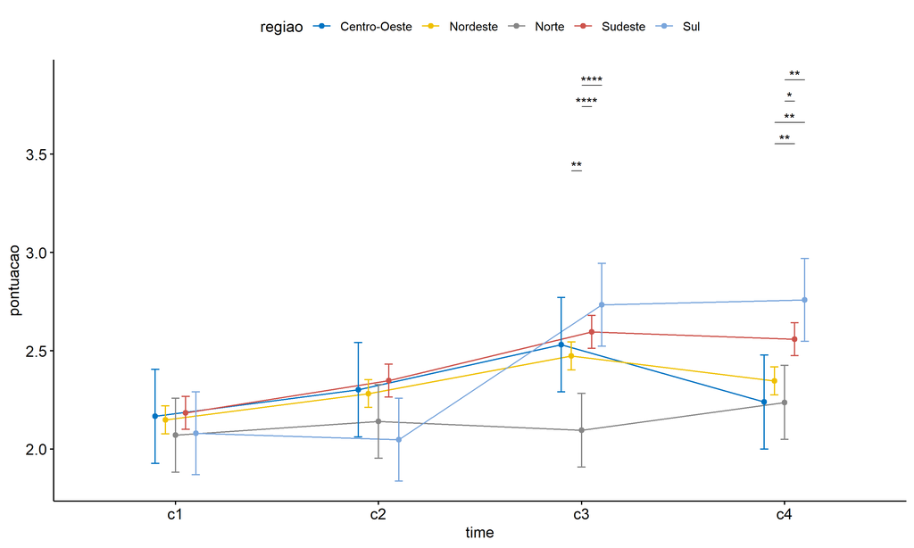

```r
pwc <- add_xy_position(pwc, x = "time", fun = "mean_se", dodge = 0.25)
pd <- position_dodge(width = 0.25)
ggline(emms, x = "time", y = "emmean", color = "regiao",
       palette = c("#0073C2FF","#EFC000FF","#868686FF","#CD534CFF","#7AA6DCFF"),
       position = pd, ylab = "pontuacao") +
  geom_errorbar(aes(ymin = conf.low, ymax = conf.high, color = regiao),
                position = pd, width = 0.2) +
  stat_pvalue_manual(pwc, hide.ns = T, tip.length = F, linetype = 1)
```

```r
(pwc <- ldat %>% group_by(regiao) %>%
    emmeans_test(pontuacao ~ time, detailed = T, p.adjust.method = "bonferroni"))
```

```
## # A tibble: 30 × 15
##    regiao term  .y.   group1 group2 null.value estimate     se    df conf.low conf.high statistic
##  * <fct>  <chr> <chr> <chr>  <chr>       <dbl>    <dbl>  <dbl> <dbl>    <dbl>     <dbl>     <dbl>
##  1 Centr… time  pont… c1     c2              0  -0.135  0.173   4484  -0.474     0.203     -0.784
##  2 Centr… time  pont… c1     c3              0  -0.365  0.173   4484  -0.703    -0.0259    -2.11
##  3 Centr… time  pont… c1     c4              0  -0.0729 0.173   4484  -0.412     0.266     -0.422
##  4 Centr… time  pont… c2     c3              0  -0.229  0.173   4484  -0.568     0.109     -1.33
##  5 Centr… time  pont… c2     c4              0   0.0625 0.173   4484  -0.276     0.401      0.362
##  6 Centr… time  pont… c3     c4              0   0.292  0.173   4484  -0.0470    0.630      1.69
##  7 Norde… time  pont… c1     c2              0  -0.134  0.0513  4484  -0.234    -0.0333    -2.61
##  8 Norde… time  pont… c1     c3              0  -0.325  0.0513  4484  -0.425    -0.224     -6.34
##  9 Norde… time  pont… c1     c4              0  -0.198  0.0513  4484  -0.299    -0.0977    -3.87
## 10 Norde… time  pont… c2     c3              0  -0.191  0.0513  4484  -0.291    -0.0905    -3.73
## # ℹ 20 more rows
## # ℹ 3 more variables: p <dbl>, p.adj <dbl>, p.adj.signif <chr>
```

| regiao | term | .y. | group1 | group2 | null.value | estimate | se | df | conf.low | conf.high | statistic | p | p.adj | p.adj.signif |
| --- | --- | --- | --- | --- | --- | --- | --- | --- | --- | --- | --- | --- | --- | --- |
| Centro-Oeste | time | pontuacao | c1 | c2 | 0 | -0.135 | 0.173 | 4484 | -0.474 | 0.203 | -0.784 | 0.433 | 1.000 | ns |
| Centro-Oeste | time | pontuacao | c1 | c3 | 0 | -0.365 | 0.173 | 4484 | -0.703 | -0.026 | -2.111 | 0.035 | 0.209 | ns |
| Centro-Oeste | time | pontuacao | c1 | c4 | 0 | -0.073 | 0.173 | 4484 | -0.412 | 0.266 | -0.422 | 0.673 | 1.000 | ns |
| Centro-Oeste | time | pontuacao | c2 | c3 | 0 | -0.229 | 0.173 | 4484 | -0.568 | 0.109 | -1.327 | 0.185 | 1.000 | ns |
| Centro-Oeste | time | pontuacao | c2 | c4 | 0 | 0.062 | 0.173 | 4484 | -0.276 | 0.401 | 0.362 | 0.718 | 1.000 | ns |
| Centro-Oeste | time | pontuacao | c3 | c4 | 0 | 0.292 | 0.173 | 4484 | -0.047 | 0.630 | 1.688 | 0.091 | 0.548 | ns |
| Nordeste | time | pontuacao | c1 | c2 | 0 | -0.134 | 0.051 | 4484 | -0.234 | -0.033 | -2.610 | 0.009 | 0.055 | ns |
| Nordeste | time | pontuacao | c1 | c3 | 0 | -0.325 | 0.051 | 4484 | -0.425 | -0.224 | -6.335 | 0.000 | 0.000 | **** |
| Nordeste | time | pontuacao | c1 | c4 | 0 | -0.198 | 0.051 | 4484 | -0.299 | -0.098 | -3.865 | 0.000 | 0.001 | *** |
| Nordeste | time | pontuacao | c2 | c3 | 0 | -0.191 | 0.051 | 4484 | -0.291 | -0.090 | -3.725 | 0.000 | 0.001 | ** |
| Nordeste | time | pontuacao | c2 | c4 | 0 | -0.064 | 0.051 | 4484 | -0.165 | 0.036 | -1.256 | 0.209 | 1.000 | ns |
| Nordeste | time | pontuacao | c3 | c4 | 0 | 0.127 | 0.051 | 4484 | 0.026 | 0.227 | 2.470 | 0.014 | 0.081 | ns |
| Norte | time | pontuacao | c1 | c2 | 0 | -0.071 | 0.136 | 4484 | -0.336 | 0.195 | -0.520 | 0.603 | 1.000 | ns |
| Norte | time | pontuacao | c1 | c3 | 0 | -0.026 | 0.136 | 4484 | -0.291 | 0.240 | -0.189 | 0.850 | 1.000 | ns |
| Norte | time | pontuacao | c1 | c4 | 0 | -0.167 | 0.136 | 4484 | -0.432 | 0.099 | -1.230 | 0.219 | 1.000 | ns |
| Norte | time | pontuacao | c2 | c3 | 0 | 0.045 | 0.136 | 4484 | -0.221 | 0.311 | 0.331 | 0.741 | 1.000 | ns |
| Norte | time | pontuacao | c2 | c4 | 0 | -0.096 | 0.136 | 4484 | -0.362 | 0.170 | -0.710 | 0.478 | 1.000 | ns |
| Norte | time | pontuacao | c3 | c4 | 0 | -0.141 | 0.136 | 4484 | -0.407 | 0.125 | -1.041 | 0.298 | 1.000 | ns |
| Sudeste | time | pontuacao | c1 | c2 | 0 | -0.164 | 0.060 | 4484 | -0.282 | -0.046 | -2.715 | 0.007 | 0.040 | * |
| Sudeste | time | pontuacao | c1 | c3 | 0 | -0.412 | 0.060 | 4484 | -0.531 | -0.294 | -6.828 | 0.000 | 0.000 | **** |
| Sudeste | time | pontuacao | c1 | c4 | 0 | -0.374 | 0.060 | 4484 | -0.492 | -0.256 | -6.196 | 0.000 | 0.000 | **** |
| Sudeste | time | pontuacao | c2 | c3 | 0 | -0.248 | 0.060 | 4484 | -0.367 | -0.130 | -4.113 | 0.000 | 0.000 | *** |
| Sudeste | time | pontuacao | c2 | c4 | 0 | -0.210 | 0.060 | 4484 | -0.328 | -0.092 | -3.481 | 0.001 | 0.003 | ** |
| Sudeste | time | pontuacao | c3 | c4 | 0 | 0.038 | 0.060 | 4484 | -0.080 | 0.157 | 0.632 | 0.527 | 1.000 | ns |
| Sul | time | pontuacao | c1 | c2 | 0 | 0.032 | 0.152 | 4484 | -0.266 | 0.330 | 0.212 | 0.832 | 1.000 | ns |
| Sul | time | pontuacao | c1 | c3 | 0 | -0.653 | 0.152 | 4484 | -0.951 | -0.355 | -4.298 | 0.000 | 0.000 | *** |
| Sul | time | pontuacao | c1 | c4 | 0 | -0.677 | 0.152 | 4484 | -0.975 | -0.379 | -4.457 | 0.000 | 0.000 | **** |
| Sul | time | pontuacao | c2 | c3 | 0 | -0.685 | 0.152 | 4484 | -0.983 | -0.387 | -4.510 | 0.000 | 0.000 | **** |
| Sul | time | pontuacao | c2 | c4 | 0 | -0.710 | 0.152 | 4484 | -1.008 | -0.412 | -4.669 | 0.000 | 0.000 | **** |
| Sul | time | pontuacao | c3 | c4 | 0 | -0.024 | 0.152 | 4484 | -0.322 | 0.274 | -0.159 | 0.874 | 1.000 | ns |

```r
(emms <- get_emmeans(pwc))
```

```
## # A tibble: 20 × 8
##    regiao       time  emmean     se    df conf.low conf.high method
##    <fct>        <fct>  <dbl>  <dbl> <dbl>    <dbl>     <dbl> <chr>
##  1 Centro-Oeste c1      2.17 0.122   4484     1.93      2.41 Emmeans test
##  2 Centro-Oeste c2      2.30 0.122   4484     2.06      2.54 Emmeans test
##  3 Centro-Oeste c3      2.53 0.122   4484     2.29      2.77 Emmeans test
##  4 Centro-Oeste c4      2.24 0.122   4484     2.00      2.48 Emmeans test
##  5 Nordeste     c1      2.15 0.0363  4484     2.08      2.22 Emmeans test
##  6 Nordeste     c2      2.28 0.0363  4484     2.21      2.35 Emmeans test
##  7 Nordeste     c3      2.47 0.0363  4484     2.40      2.54 Emmeans test
##  8 Nordeste     c4      2.35 0.0363  4484     2.28      2.42 Emmeans test
##  9 Norte        c1      2.07 0.0958  4484     1.88      2.26 Emmeans test
## 10 Norte        c2      2.14 0.0958  4484     1.95      2.33 Emmeans test
## 11 Norte        c3      2.10 0.0958  4484     1.91      2.28 Emmeans test
## 12 Norte        c4      2.24 0.0958  4484     2.05      2.43 Emmeans test
## 13 Sudeste      c1      2.18 0.0427  4484     2.10      2.27 Emmeans test
## 14 Sudeste      c2      2.35 0.0427  4484     2.26      2.43 Emmeans test
## 15 Sudeste      c3      2.60 0.0427  4484     2.51      2.68 Emmeans test
## 16 Sudeste      c4      2.56 0.0427  4484     2.47      2.64 Emmeans test
## 17 Sul          c1      2.08 0.107   4484     1.87      2.29 Emmeans test
## 18 Sul          c2      2.05 0.107   4484     1.84      2.26 Emmeans test
## 19 Sul          c3      2.73 0.107   4484     2.52      2.94 Emmeans test
## 20 Sul          c4      2.76 0.107   4484     2.55      2.97 Emmeans test
```

| regiao | time | emmean | se | df | conf.low | conf.high | method |
| --- | --- | --- | --- | --- | --- | --- | --- |
| Centro-Oeste | c1 | 2.167 | 0.122 | 4484 | 1.927 | 2.406 | Emmeans test |
| Centro-Oeste | c2 | 2.302 | 0.122 | 4484 | 2.063 | 2.542 | Emmeans test |
| Centro-Oeste | c3 | 2.531 | 0.122 | 4484 | 2.292 | 2.771 | Emmeans test |
| Centro-Oeste | c4 | 2.240 | 0.122 | 4484 | 2.000 | 2.479 | Emmeans test |
| Nordeste | c1 | 2.149 | 0.036 | 4484 | 2.078 | 2.220 | Emmeans test |
| Nordeste | c2 | 2.282 | 0.036 | 4484 | 2.211 | 2.353 | Emmeans test |
| Nordeste | c3 | 2.473 | 0.036 | 4484 | 2.402 | 2.544 | Emmeans test |
| Nordeste | c4 | 2.347 | 0.036 | 4484 | 2.276 | 2.418 | Emmeans test |
| Norte | c1 | 2.071 | 0.096 | 4484 | 1.883 | 2.258 | Emmeans test |
| Norte | c2 | 2.141 | 0.096 | 4484 | 1.953 | 2.329 | Emmeans test |
| Norte | c3 | 2.096 | 0.096 | 4484 | 1.908 | 2.284 | Emmeans test |
| Norte | c4 | 2.237 | 0.096 | 4484 | 2.049 | 2.425 | Emmeans test |
| Sudeste | c1 | 2.184 | 0.043 | 4484 | 2.101 | 2.268 | Emmeans test |
| Sudeste | c2 | 2.348 | 0.043 | 4484 | 2.265 | 2.432 | Emmeans test |
| Sudeste | c3 | 2.597 | 0.043 | 4484 | 2.513 | 2.680 | Emmeans test |
| Sudeste | c4 | 2.559 | 0.043 | 4484 | 2.475 | 2.642 | Emmeans test |
| Sul | c1 | 2.081 | 0.107 | 4484 | 1.870 | 2.291 | Emmeans test |
| Sul | c2 | 2.048 | 0.107 | 4484 | 1.838 | 2.259 | Emmeans test |
| Sul | c3 | 2.734 | 0.107 | 4484 | 2.523 | 2.945 | Emmeans test |
| Sul | c4 | 2.758 | 0.107 | 4484 | 2.547 | 2.969 | Emmeans test |

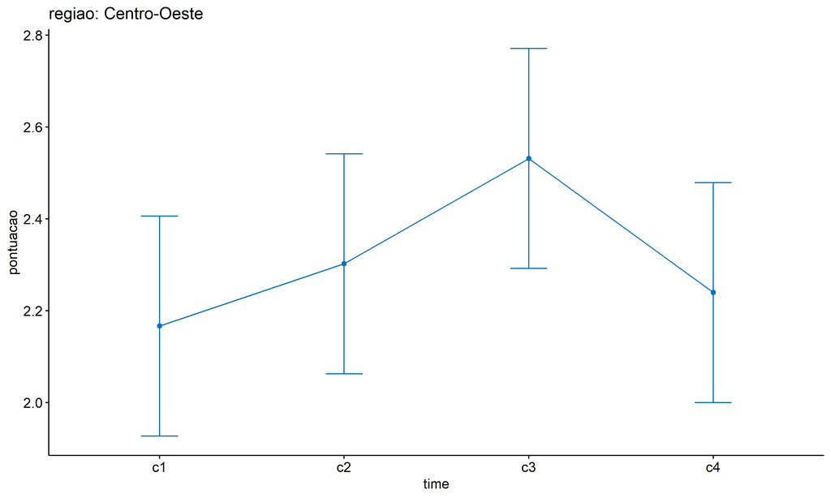

```r
emms.gg <- emms[which(emms$regiao == "Centro-Oeste"),]
if (nrow(emms.gg) > 0)
  ggline(emms.gg, x = "time", y = "emmean", color = "#0073C2FF", ylab = "pontuacao") +
    geom_errorbar(aes(ymin = conf.low, ymax = conf.high),
                  width = 0.2, color = "#0073C2FF") +
    stat_pvalue_manual(
      add_xy_position(pwc[which(pwc$regiao == "Centro-Oeste"),],
                      x = "time", fun = "mean_se"),
      hide.ns = T, color = "#0073C2FF", tip.length = F) +
    labs(title = "regiao: Centro-Oeste")+
    theme(legend.text = element_blank())
```

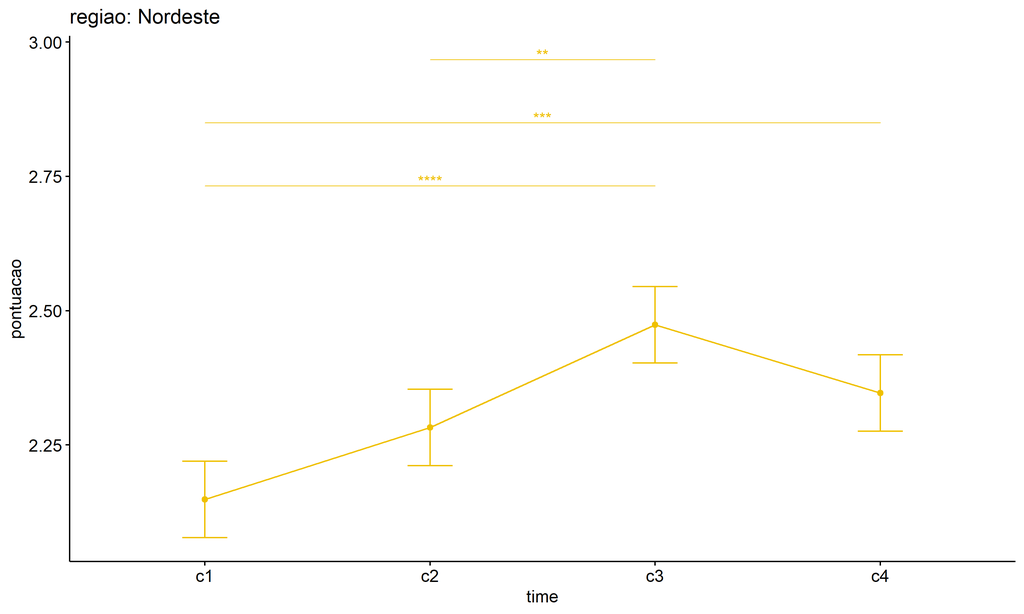

```r
emms.gg <- emms[which(emms$regiao == "Nordeste"),]
if (nrow(emms.gg) > 0)
  ggline(emms.gg, x = "time", y = "emmean", color = "#EFC000FF", ylab = "pontuacao") +
    geom_errorbar(aes(ymin = conf.low, ymax = conf.high),
                  width = 0.2, color = "#EFC000FF") +
    stat_pvalue_manual(
      add_xy_position(pwc[which(pwc$regiao == "Nordeste"),],
                      x = "time", fun = "mean_se"),
      hide.ns = T, color = "#EFC000FF", tip.length = F) +
    labs(title = "regiao: Nordeste")+
    theme(legend.text = element_blank())
```

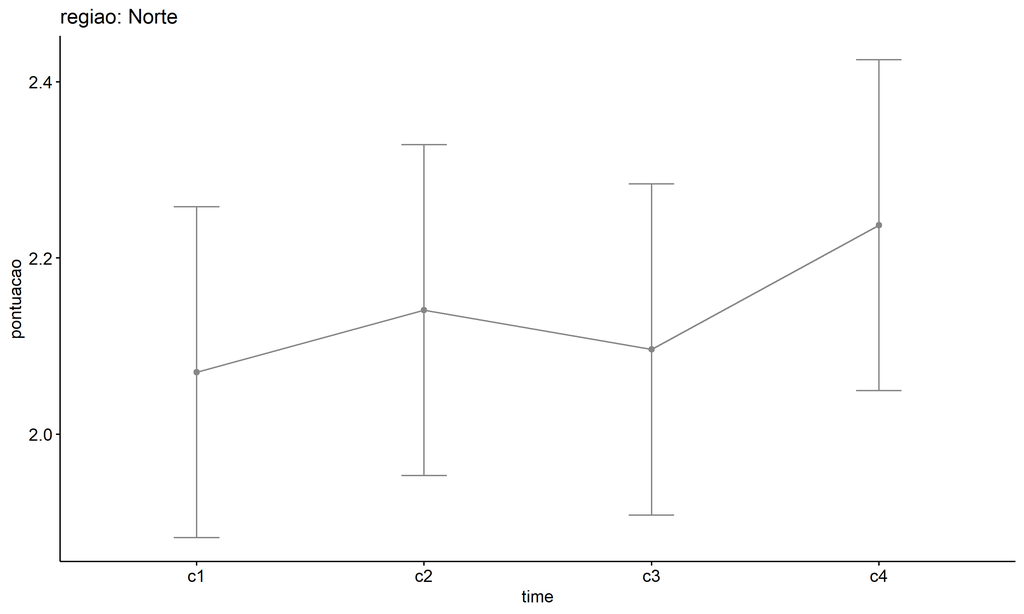

```r
emms.gg <- emms[which(emms$regiao == "Norte"),]
if (nrow(emms.gg) > 0)
  ggline(emms.gg, x = "time", y = "emmean", color = "#868686FF", ylab = "pontuacao") +
    geom_errorbar(aes(ymin = conf.low, ymax = conf.high),
                  width = 0.2, color = "#868686FF") +
    stat_pvalue_manual(
      add_xy_position(pwc[which(pwc$regiao == "Norte"),],
                      x = "time", fun = "mean_se"),
      hide.ns = T, color = "#868686FF", tip.length = F) +
    labs(title = "regiao: Norte")+
    theme(legend.text = element_blank())
```

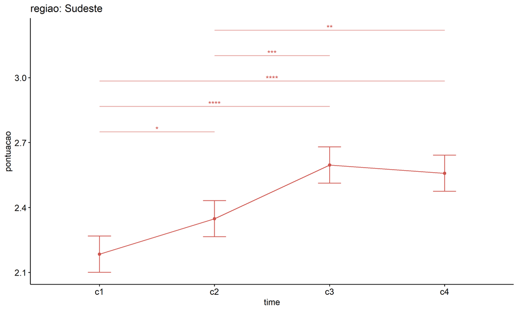

```r
emms.gg <- emms[which(emms$regiao == "Sudeste"),]
if (nrow(emms.gg) > 0)
  ggline(emms.gg, x = "time", y = "emmean", color = "#CD534CFF", ylab = "pontuacao") +
    geom_errorbar(aes(ymin = conf.low, ymax = conf.high),
                  width = 0.2, color = "#CD534CFF") +
    stat_pvalue_manual(
      add_xy_position(pwc[which(pwc$regiao == "Sudeste"),],
                      x = "time", fun = "mean_se"),
      hide.ns = T, color = "#CD534CFF", tip.length = F) +
    labs(title = "regiao: Sudeste")+
    theme(legend.text = element_blank())
```

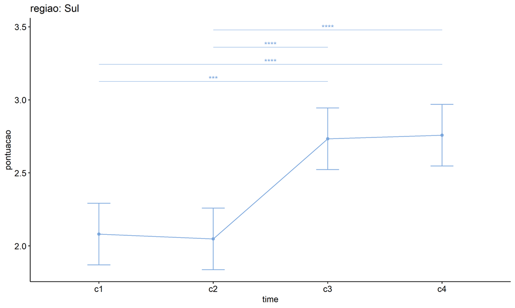

```r
emms.gg <- emms[which(emms$regiao == "Sul"),]
if (nrow(emms.gg) > 0)
  ggline(emms.gg, x = "time", y = "emmean", color = "#7AA6DCFF", ylab = "pontuacao") +
    geom_errorbar(aes(ymin = conf.low, ymax = conf.high),
                  width = 0.2, color = "#7AA6DCFF") +
    stat_pvalue_manual(
      add_xy_position(pwc[which(pwc$regiao == "Sul"),],
                      x = "time", fun = "mean_se"),
      hide.ns = T, color = "#7AA6DCFF", tip.length = F) +
    labs(title = "regiao: Sul")+
    theme(legend.text = element_blank())
```

## PairWise Computation after removing non.normal data

```r
if (length(non.ids) > 0)
  (pwc2 <- ldat2 %>% group_by(time) %>%
     emmeans_test(pontuacao ~ regiao, detailed = T, p.adjust.method = "bonferroni"))
```

| time | term | .y. | group1 | group2 | null.value | estimate | se | df | conf.low | conf.high | statistic | p | p.adj | p.adj.signif |
| --- | --- | --- | --- | --- | --- | --- | --- | --- | --- | --- | --- | --- | --- | --- |
| c1 | regiao | pontuacao | Centro | Oeste | 0 | -0.024 | 0.137 | 4212 | -0.293 | 0.245 | -0.172 | 0.863 | 1.000 | ns |
| c1 | regiao | pontuacao | Centro | Oeste | 0 | 0.051 | 0.164 | 4212 | -0.272 | 0.373 | 0.308 | 0.758 | 1.000 | ns |
| c1 | regiao | pontuacao | Centro | Oeste | 0 | -0.059 | 0.139 | 4212 | -0.332 | 0.213 | -0.428 | 0.669 | 1.000 | ns |
| c1 | regiao | pontuacao | Centro | Oeste | 0 | 0.125 | 0.367 | 4212 | -0.594 | 0.844 | 0.341 | 0.733 | 1.000 | ns |
| c1 | regiao | pontuacao | Nordeste | Norte | 0 | 0.074 | 0.104 | 4212 | -0.129 | 0.278 | 0.716 | 0.474 | 1.000 | ns |
| c1 | regiao | pontuacao | Nordeste | Sudeste | 0 | -0.036 | 0.055 | 4212 | -0.145 | 0.073 | -0.647 | 0.518 | 1.000 | ns |
| c1 | regiao | pontuacao | Nordeste | Sul | 0 | 0.149 | 0.344 | 4212 | -0.525 | 0.823 | 0.432 | 0.666 | 1.000 | ns |
| c1 | regiao | pontuacao | Norte | Sudeste | 0 | -0.110 | 0.106 | 4212 | -0.318 | 0.098 | -1.038 | 0.299 | 1.000 | ns |
| c1 | regiao | pontuacao | Norte | Sul | 0 | 0.074 | 0.355 | 4212 | -0.623 | 0.771 | 0.209 | 0.834 | 1.000 | ns |
| c1 | regiao | pontuacao | Sudeste | Sul | 0 | 0.184 | 0.344 | 4212 | -0.491 | 0.860 | 0.536 | 0.592 | 1.000 | ns |
| c2 | regiao | pontuacao | Centro | Oeste | 0 | -0.120 | 0.137 | 4212 | -0.389 | 0.149 | -0.874 | 0.382 | 1.000 | ns |
| c2 | regiao | pontuacao | Centro | Oeste | 0 | 0.014 | 0.164 | 4212 | -0.308 | 0.336 | 0.084 | 0.933 | 1.000 | ns |
| c2 | regiao | pontuacao | Centro | Oeste | 0 | -0.186 | 0.139 | 4212 | -0.458 | 0.087 | -1.337 | 0.181 | 1.000 | ns |
| c2 | regiao | pontuacao | Centro | Oeste | 0 | 0.163 | 0.367 | 4212 | -0.556 | 0.881 | 0.443 | 0.658 | 1.000 | ns |
| c2 | regiao | pontuacao | Nordeste | Norte | 0 | 0.134 | 0.104 | 4212 | -0.070 | 0.337 | 1.289 | 0.197 | 1.000 | ns |
| c2 | regiao | pontuacao | Nordeste | Sudeste | 0 | -0.066 | 0.055 | 4212 | -0.175 | 0.043 | -1.190 | 0.234 | 1.000 | ns |
| c2 | regiao | pontuacao | Nordeste | Sul | 0 | 0.282 | 0.344 | 4212 | -0.392 | 0.956 | 0.822 | 0.411 | 1.000 | ns |
| c2 | regiao | pontuacao | Norte | Sudeste | 0 | -0.200 | 0.106 | 4212 | -0.408 | 0.008 | -1.882 | 0.060 | 0.599 | ns |
| c2 | regiao | pontuacao | Norte | Sul | 0 | 0.149 | 0.355 | 4212 | -0.548 | 0.846 | 0.418 | 0.676 | 1.000 | ns |
| c2 | regiao | pontuacao | Sudeste | Sul | 0 | 0.348 | 0.344 | 4212 | -0.327 | 1.024 | 1.011 | 0.312 | 1.000 | ns |
| c3 | regiao | pontuacao | Centro | Oeste | 0 | 0.052 | 0.137 | 4212 | -0.217 | 0.321 | 0.376 | 0.707 | 1.000 | ns |
| c3 | regiao | pontuacao | Centro | Oeste | 0 | 0.471 | 0.164 | 4212 | 0.149 | 0.793 | 2.865 | 0.004 | 0.042 | * |
| c3 | regiao | pontuacao | Centro | Oeste | 0 | -0.072 | 0.139 | 4212 | -0.344 | 0.201 | -0.516 | 0.606 | 1.000 | ns |
| c3 | regiao | pontuacao | Centro | Oeste | 0 | -1.808 | 0.367 | 4212 | -2.527 | -1.090 | -4.932 | 0.000 | 0.000 | **** |
| c3 | regiao | pontuacao | Nordeste | Norte | 0 | 0.419 | 0.104 | 4212 | 0.216 | 0.623 | 4.042 | 0.000 | 0.001 | *** |
| c3 | regiao | pontuacao | Nordeste | Sudeste | 0 | -0.123 | 0.055 | 4212 | -0.232 | -0.015 | -2.225 | 0.026 | 0.262 | ns |
| c3 | regiao | pontuacao | Nordeste | Sul | 0 | -1.860 | 0.344 | 4212 | -2.534 | -1.186 | -5.410 | 0.000 | 0.000 | **** |
| c3 | regiao | pontuacao | Norte | Sudeste | 0 | -0.543 | 0.106 | 4212 | -0.751 | -0.335 | -5.113 | 0.000 | 0.000 | **** |
| c3 | regiao | pontuacao | Norte | Sul | 0 | -2.279 | 0.355 | 4212 | -2.976 | -1.582 | -6.412 | 0.000 | 0.000 | **** |
| c3 | regiao | pontuacao | Sudeste | Sul | 0 | -1.737 | 0.344 | 4212 | -2.412 | -1.061 | -5.041 | 0.000 | 0.000 | **** |
| c4 | regiao | pontuacao | Centro | Oeste | 0 | -0.209 | 0.137 | 4212 | -0.478 | 0.060 | -1.526 | 0.127 | 1.000 | ns |
| c4 | regiao | pontuacao | Centro | Oeste | 0 | 0.009 | 0.164 | 4212 | -0.313 | 0.331 | 0.056 | 0.956 | 1.000 | ns |
| c4 | regiao | pontuacao | Centro | Oeste | 0 | -0.421 | 0.139 | 4212 | -0.694 | -0.149 | -3.029 | 0.002 | 0.025 | * |
| c4 | regiao | pontuacao | Centro | Oeste | 0 | -1.862 | 0.367 | 4212 | -2.581 | -1.144 | -5.080 | 0.000 | 0.000 | **** |
| c4 | regiao | pontuacao | Nordeste | Norte | 0 | 0.218 | 0.104 | 4212 | 0.015 | 0.422 | 2.105 | 0.035 | 0.353 | ns |
| c4 | regiao | pontuacao | Nordeste | Sudeste | 0 | -0.212 | 0.055 | 4212 | -0.320 | -0.103 | -3.820 | 0.000 | 0.001 | ** |
| c4 | regiao | pontuacao | Nordeste | Sul | 0 | -1.653 | 0.344 | 4212 | -2.327 | -0.979 | -4.809 | 0.000 | 0.000 | **** |
| c4 | regiao | pontuacao | Norte | Sudeste | 0 | -0.430 | 0.106 | 4212 | -0.638 | -0.222 | -4.053 | 0.000 | 0.001 | *** |
| c4 | regiao | pontuacao | Norte | Sul | 0 | -1.872 | 0.355 | 4212 | -2.569 | -1.175 | -5.265 | 0.000 | 0.000 | **** |
| c4 | regiao | pontuacao | Sudeste | Sul | 0 | -1.441 | 0.344 | 4212 | -2.117 | -0.766 | -4.184 | 0.000 | 0.000 | *** |

```r
if (length(non.ids) > 0)
  (emms2 <- get_emmeans(pwc2))
```

```
## # A tibble: 20 × 8
##    time  regiao       emmean     se    df conf.low conf.high method
##    <fct> <fct>         <dbl>  <dbl> <dbl>    <dbl>     <dbl> <chr>
##  1 c1    Centro-Oeste   2.12 0.132   4212     1.87      2.38 Emmeans test
##  2 c1    Nordeste       2.15 0.0359  4212     2.08      2.22 Emmeans test
##  3 c1    Norte          2.07 0.0974  4212     1.88      2.27 Emmeans test
##  4 c1    Sudeste        2.18 0.0422  4212     2.10      2.27 Emmeans test
##  5 c1    Sul            2.00 0.342   4212     1.33      2.67 Emmeans test
##  6 c2    Centro-Oeste   2.16 0.132   4212     1.90      2.42 Emmeans test
##  7 c2    Nordeste       2.28 0.0359  4212     2.21      2.35 Emmeans test
##  8 c2    Norte          2.15 0.0974  4212     1.96      2.34 Emmeans test
##  9 c2    Sudeste        2.35 0.0422  4212     2.27      2.43 Emmeans test
## 10 c2    Sul            2.00 0.342   4212     1.33      2.67 Emmeans test
## 11 c3    Centro-Oeste   2.52 0.132   4212     2.27      2.78 Emmeans test
## 12 c3    Nordeste       2.47 0.0359  4212     2.40      2.54 Emmeans test
## 13 c3    Norte          2.05 0.0974  4212     1.86      2.24 Emmeans test
## 14 c3    Sudeste        2.60 0.0422  4212     2.51      2.68 Emmeans test
## 15 c3    Sul            4.33 0.342   4212     3.66      5.00 Emmeans test
## 16 c4    Centro-Oeste   2.14 0.132   4212     1.88      2.40 Emmeans test
## 17 c4    Nordeste       2.35 0.0359  4212     2.28      2.42 Emmeans test
## 18 c4    Norte          2.13 0.0974  4212     1.94      2.32 Emmeans test
## 19 c4    Sudeste        2.56 0.0422  4212     2.48      2.64 Emmeans test
## 20 c4    Sul            4.00 0.342   4212     3.33      4.67 Emmeans test
```

| time | regiao | emmean | se | df | conf.low | conf.high | method |
| --- | --- | --- | --- | --- | --- | --- | --- |
| c1 | Centro-Oeste | 2.125 | 0.132 | 4212 | 1.865 | 2.385 | Emmeans test |
| c1 | Nordeste | 2.149 | 0.036 | 4212 | 2.078 | 2.219 | Emmeans test |
| c1 | Norte | 2.074 | 0.097 | 4212 | 1.883 | 2.265 | Emmeans test |
| c1 | Sudeste | 2.184 | 0.042 | 4212 | 2.102 | 2.267 | Emmeans test |
| c1 | Sul | 2.000 | 0.342 | 4212 | 1.330 | 2.670 | Emmeans test |
| c2 | Centro-Oeste | 2.162 | 0.132 | 4212 | 1.903 | 2.422 | Emmeans test |
| c2 | Nordeste | 2.282 | 0.036 | 4212 | 2.212 | 2.353 | Emmeans test |
| c2 | Norte | 2.149 | 0.097 | 4212 | 1.958 | 2.340 | Emmeans test |
| c2 | Sudeste | 2.348 | 0.042 | 4212 | 2.266 | 2.431 | Emmeans test |
| c2 | Sul | 2.000 | 0.342 | 4212 | 1.330 | 2.670 | Emmeans test |
| c3 | Centro-Oeste | 2.525 | 0.132 | 4212 | 2.265 | 2.785 | Emmeans test |
| c3 | Nordeste | 2.473 | 0.036 | 4212 | 2.403 | 2.544 | Emmeans test |
| c3 | Norte | 2.054 | 0.097 | 4212 | 1.863 | 2.245 | Emmeans test |
| c3 | Sudeste | 2.597 | 0.042 | 4212 | 2.514 | 2.680 | Emmeans test |
| c3 | Sul | 4.333 | 0.342 | 4212 | 3.663 | 5.004 | Emmeans test |
| c4 | Centro-Oeste | 2.137 | 0.132 | 4212 | 1.878 | 2.397 | Emmeans test |
| c4 | Nordeste | 2.347 | 0.036 | 4212 | 2.276 | 2.417 | Emmeans test |
| c4 | Norte | 2.128 | 0.097 | 4212 | 1.938 | 2.319 | Emmeans test |
| c4 | Sudeste | 2.559 | 0.042 | 4212 | 2.476 | 2.641 | Emmeans test |
| c4 | Sul | 4.000 | 0.342 | 4212 | 3.330 | 4.670 | Emmeans test |

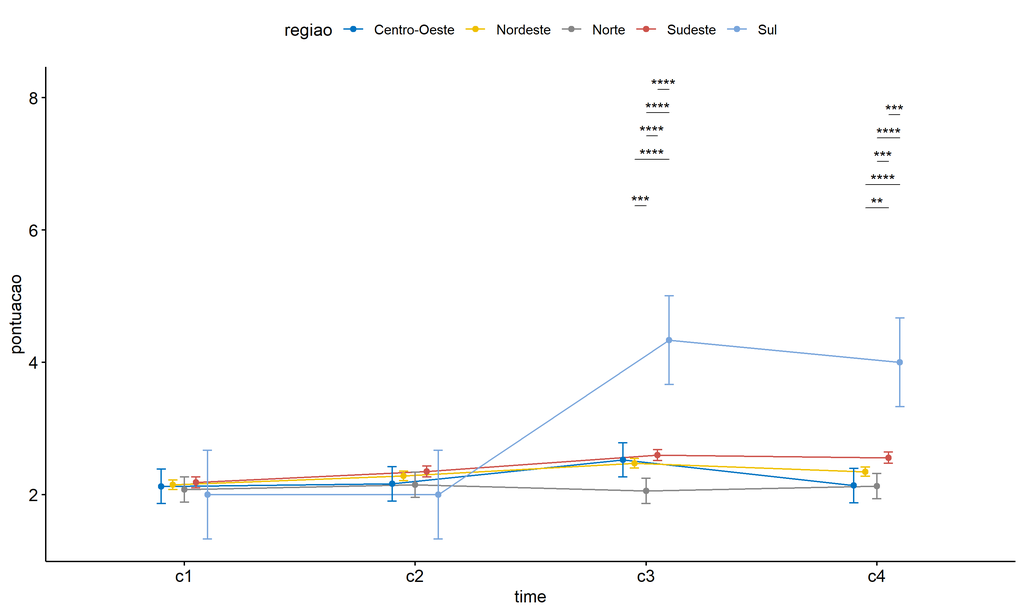

```r
if (length(non.ids) > 0) {
  pwc2 <- add_xy_position(pwc2, x = "time", fun = "mean_se", dodge = 0.25)
  pd2 <- position_dodge(width = 0.25)

  ggline(emms2, x = "time", y = "emmean", color = "regiao",
         palette = c("#0073C2FF","#EFC000FF","#868686FF","#CD534CFF","#7AA6DCFF"),
         position = pd, ylab = "pontuacao") +
    geom_errorbar(aes(ymin = conf.low, ymax = conf.high, color = regiao),
                position = pd, width = 0.2) +
    stat_pvalue_manual(pwc2, hide.ns = T, tip.length = F, linetype = 1)
}
```

```r
if (length(non.ids) > 0)
  (pwc2 <- ldat2 %>% group_by(regiao) %>%
     emmeans_test(pontuacao ~ time, detailed = T, p.adjust.method = "bonferroni"))
```

```
## # A tibble: 30 × 15
##    regiao term  .y.   group1 group2 null.value estimate     se    df conf.low conf.high statistic
##  * <fct>  <chr> <chr> <chr>  <chr>       <dbl>    <dbl>  <dbl> <dbl>    <dbl>     <dbl>     <dbl>
##  1 Centr… time  pont… c1     c2              0  -0.0375 0.187   4212  -0.405    0.330     -0.200
##  2 Centr… time  pont… c1     c3              0  -0.400  0.187   4212  -0.767   -0.0329    -2.14
##  3 Centr… time  pont… c1     c4              0  -0.0125 0.187   4212  -0.380    0.355     -0.0668
##  4 Centr… time  pont… c2     c3              0  -0.363  0.187   4212  -0.730    0.00464   -1.94
##  5 Centr… time  pont… c2     c4              0   0.0250 0.187   4212  -0.342    0.392      0.134
##  6 Centr… time  pont… c3     c4              0   0.387  0.187   4212   0.0204   0.755      2.07
##  7 Norde… time  pont… c1     c2              0  -0.134  0.0507  4212  -0.233   -0.0343    -2.64
##  8 Norde… time  pont… c1     c3              0  -0.325  0.0507  4212  -0.424   -0.225     -6.40
##  9 Norde… time  pont… c1     c4              0  -0.198  0.0507  4212  -0.298   -0.0987    -3.91
## 10 Norde… time  pont… c2     c3              0  -0.191  0.0507  4212  -0.290   -0.0915    -3.76
## # ℹ 20 more rows
## # ℹ 3 more variables: p <dbl>, p.adj <dbl>, p.adj.signif <chr>
```

| regiao | term | .y. | group1 | group2 | null.value | estimate | se | df | conf.low | conf.high | statistic | p | p.adj | p.adj.signif |
| --- | --- | --- | --- | --- | --- | --- | --- | --- | --- | --- | --- | --- | --- | --- |
| Centro-Oeste | time | pontuacao | c1 | c2 | 0 | -0.037 | 0.187 | 4212 | -0.405 | 0.330 | -0.200 | 0.841 | 1.000 | ns |
| Centro-Oeste | time | pontuacao | c1 | c3 | 0 | -0.400 | 0.187 | 4212 | -0.767 | -0.033 | -2.136 | 0.033 | 0.196 | ns |
| Centro-Oeste | time | pontuacao | c1 | c4 | 0 | -0.013 | 0.187 | 4212 | -0.380 | 0.355 | -0.067 | 0.947 | 1.000 | ns |
| Centro-Oeste | time | pontuacao | c2 | c3 | 0 | -0.363 | 0.187 | 4212 | -0.730 | 0.005 | -1.936 | 0.053 | 0.318 | ns |
| Centro-Oeste | time | pontuacao | c2 | c4 | 0 | 0.025 | 0.187 | 4212 | -0.342 | 0.392 | 0.134 | 0.894 | 1.000 | ns |
| Centro-Oeste | time | pontuacao | c3 | c4 | 0 | 0.387 | 0.187 | 4212 | 0.020 | 0.755 | 2.069 | 0.039 | 0.231 | ns |
| Nordeste | time | pontuacao | c1 | c2 | 0 | -0.134 | 0.051 | 4212 | -0.233 | -0.034 | -2.637 | 0.008 | 0.050 | ns |
| Nordeste | time | pontuacao | c1 | c3 | 0 | -0.325 | 0.051 | 4212 | -0.424 | -0.225 | -6.402 | 0.000 | 0.000 | **** |
| Nordeste | time | pontuacao | c1 | c4 | 0 | -0.198 | 0.051 | 4212 | -0.298 | -0.099 | -3.906 | 0.000 | 0.001 | *** |
| Nordeste | time | pontuacao | c2 | c3 | 0 | -0.191 | 0.051 | 4212 | -0.290 | -0.092 | -3.764 | 0.000 | 0.001 | ** |
| Nordeste | time | pontuacao | c2 | c4 | 0 | -0.064 | 0.051 | 4212 | -0.164 | 0.035 | -1.269 | 0.205 | 1.000 | ns |
| Nordeste | time | pontuacao | c3 | c4 | 0 | 0.127 | 0.051 | 4212 | 0.027 | 0.226 | 2.496 | 0.013 | 0.076 | ns |
| Norte | time | pontuacao | c1 | c2 | 0 | -0.074 | 0.138 | 4212 | -0.344 | 0.196 | -0.540 | 0.589 | 1.000 | ns |
| Norte | time | pontuacao | c1 | c3 | 0 | 0.020 | 0.138 | 4212 | -0.250 | 0.290 | 0.147 | 0.883 | 1.000 | ns |
| Norte | time | pontuacao | c1 | c4 | 0 | -0.054 | 0.138 | 4212 | -0.324 | 0.216 | -0.393 | 0.695 | 1.000 | ns |
| Norte | time | pontuacao | c2 | c3 | 0 | 0.095 | 0.138 | 4212 | -0.175 | 0.365 | 0.687 | 0.492 | 1.000 | ns |
| Norte | time | pontuacao | c2 | c4 | 0 | 0.020 | 0.138 | 4212 | -0.250 | 0.290 | 0.147 | 0.883 | 1.000 | ns |
| Norte | time | pontuacao | c3 | c4 | 0 | -0.074 | 0.138 | 4212 | -0.344 | 0.196 | -0.540 | 0.589 | 1.000 | ns |
| Sudeste | time | pontuacao | c1 | c2 | 0 | -0.164 | 0.060 | 4212 | -0.281 | -0.047 | -2.744 | 0.006 | 0.037 | * |
| Sudeste | time | pontuacao | c1 | c3 | 0 | -0.412 | 0.060 | 4212 | -0.529 | -0.295 | -6.900 | 0.000 | 0.000 | **** |
| Sudeste | time | pontuacao | c1 | c4 | 0 | -0.374 | 0.060 | 4212 | -0.491 | -0.257 | -6.261 | 0.000 | 0.000 | **** |
| Sudeste | time | pontuacao | c2 | c3 | 0 | -0.248 | 0.060 | 4212 | -0.365 | -0.131 | -4.156 | 0.000 | 0.000 | *** |
| Sudeste | time | pontuacao | c2 | c4 | 0 | -0.210 | 0.060 | 4212 | -0.327 | -0.093 | -3.517 | 0.000 | 0.003 | ** |
| Sudeste | time | pontuacao | c3 | c4 | 0 | 0.038 | 0.060 | 4212 | -0.079 | 0.155 | 0.639 | 0.523 | 1.000 | ns |
| Sul | time | pontuacao | c1 | c2 | 0 | 0.000 | 0.484 | 4212 | -0.948 | 0.948 | 0.000 | 1.000 | 1.000 | ns |
| Sul | time | pontuacao | c1 | c3 | 0 | -2.333 | 0.484 | 4212 | -3.281 | -1.385 | -4.826 | 0.000 | 0.000 | **** |
| Sul | time | pontuacao | c1 | c4 | 0 | -2.000 | 0.484 | 4212 | -2.948 | -1.052 | -4.136 | 0.000 | 0.000 | *** |
| Sul | time | pontuacao | c2 | c3 | 0 | -2.333 | 0.484 | 4212 | -3.281 | -1.385 | -4.826 | 0.000 | 0.000 | **** |
| Sul | time | pontuacao | c2 | c4 | 0 | -2.000 | 0.484 | 4212 | -2.948 | -1.052 | -4.136 | 0.000 | 0.000 | *** |
| Sul | time | pontuacao | c3 | c4 | 0 | 0.333 | 0.484 | 4212 | -0.615 | 1.281 | 0.689 | 0.491 | 1.000 | ns |

```r
if (length(non.ids) > 0)
  (emms2 <- get_emmeans(pwc2))
```

```
## # A tibble: 20 × 8
##    regiao       time  emmean     se    df conf.low conf.high method
##    <fct>        <fct>  <dbl>  <dbl> <dbl>    <dbl>     <dbl> <chr>
##  1 Centro-Oeste c1      2.12 0.132   4212     1.87      2.38 Emmeans test
##  2 Centro-Oeste c2      2.16 0.132   4212     1.90      2.42 Emmeans test
##  3 Centro-Oeste c3      2.52 0.132   4212     2.27      2.78 Emmeans test
##  4 Centro-Oeste c4      2.14 0.132   4212     1.88      2.40 Emmeans test
##  5 Nordeste     c1      2.15 0.0359  4212     2.08      2.22 Emmeans test
##  6 Nordeste     c2      2.28 0.0359  4212     2.21      2.35 Emmeans test
##  7 Nordeste     c3      2.47 0.0359  4212     2.40      2.54 Emmeans test
##  8 Nordeste     c4      2.35 0.0359  4212     2.28      2.42 Emmeans test
##  9 Norte        c1      2.07 0.0974  4212     1.88      2.27 Emmeans test
## 10 Norte        c2      2.15 0.0974  4212     1.96      2.34 Emmeans test
## 11 Norte        c3      2.05 0.0974  4212     1.86      2.24 Emmeans test
## 12 Norte        c4      2.13 0.0974  4212     1.94      2.32 Emmeans test
## 13 Sudeste      c1      2.18 0.0422  4212     2.10      2.27 Emmeans test
## 14 Sudeste      c2      2.35 0.0422  4212     2.27      2.43 Emmeans test
## 15 Sudeste      c3      2.60 0.0422  4212     2.51      2.68 Emmeans test
## 16 Sudeste      c4      2.56 0.0422  4212     2.48      2.64 Emmeans test
## 17 Sul          c1      2.00 0.342   4212     1.33      2.67 Emmeans test
## 18 Sul          c2      2.00 0.342   4212     1.33      2.67 Emmeans test
## 19 Sul          c3      4.33 0.342   4212     3.66      5.00 Emmeans test
## 20 Sul          c4      4.00 0.342   4212     3.33      4.67 Emmeans test
```

| regiao | time | emmean | se | df | conf.low | conf.high | method |
| --- | --- | --- | --- | --- | --- | --- | --- |
| Centro-Oeste | c1 | 2.125 | 0.132 | 4212 | 1.865 | 2.385 | Emmeans test |
| Centro-Oeste | c2 | 2.162 | 0.132 | 4212 | 1.903 | 2.422 | Emmeans test |
| Centro-Oeste | c3 | 2.525 | 0.132 | 4212 | 2.265 | 2.785 | Emmeans test |
| Centro-Oeste | c4 | 2.137 | 0.132 | 4212 | 1.878 | 2.397 | Emmeans test |
| Nordeste | c1 | 2.149 | 0.036 | 4212 | 2.078 | 2.219 | Emmeans test |
| Nordeste | c2 | 2.282 | 0.036 | 4212 | 2.212 | 2.353 | Emmeans test |
| Nordeste | c3 | 2.473 | 0.036 | 4212 | 2.403 | 2.544 | Emmeans test |
| Nordeste | c4 | 2.347 | 0.036 | 4212 | 2.276 | 2.417 | Emmeans test |
| Norte | c1 | 2.074 | 0.097 | 4212 | 1.883 | 2.265 | Emmeans test |
| Norte | c2 | 2.149 | 0.097 | 4212 | 1.958 | 2.340 | Emmeans test |
| Norte | c3 | 2.054 | 0.097 | 4212 | 1.863 | 2.245 | Emmeans test |
| Norte | c4 | 2.128 | 0.097 | 4212 | 1.938 | 2.319 | Emmeans test |
| Sudeste | c1 | 2.184 | 0.042 | 4212 | 2.102 | 2.267 | Emmeans test |
| Sudeste | c2 | 2.348 | 0.042 | 4212 | 2.266 | 2.431 | Emmeans test |
| Sudeste | c3 | 2.597 | 0.042 | 4212 | 2.514 | 2.680 | Emmeans test |
| Sudeste | c4 | 2.559 | 0.042 | 4212 | 2.476 | 2.641 | Emmeans test |
| Sul | c1 | 2.000 | 0.342 | 4212 | 1.330 | 2.670 | Emmeans test |
| Sul | c2 | 2.000 | 0.342 | 4212 | 1.330 | 2.670 | Emmeans test |
| Sul | c3 | 4.333 | 0.342 | 4212 | 3.663 | 5.004 | Emmeans test |
| Sul | c4 | 4.000 | 0.342 | 4212 | 3.330 | 4.670 | Emmeans test |

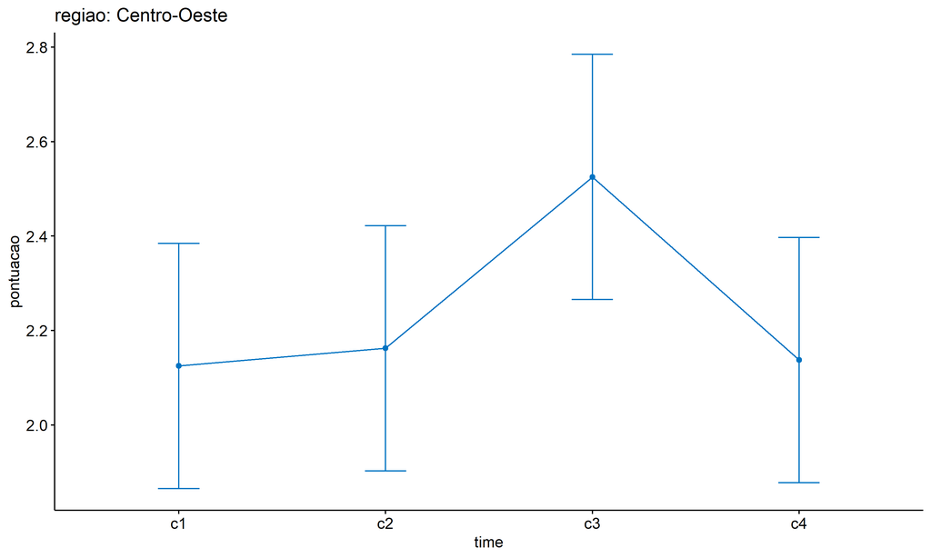

```r
if (length(non.ids) > 0) {
  emms.gg <- emms2[which(emms2$regiao == "Centro-Oeste"),]
  if (nrow(emms.gg) > 0)
    ggline(emms.gg, x = "time", y = "emmean", color = "#0073C2FF", ylab = "pontuacao") +
    geom_errorbar(aes(ymin = conf.low, ymax = conf.high),
                  width = 0.2, color = "#0073C2FF") +
    stat_pvalue_manual(
      add_xy_position(pwc[which(pwc$regiao == "Centro-Oeste"),],
                      x = "time", fun = "mean_se"),
      hide.ns = T, color = "#0073C2FF", tip.length = F) +
    labs(title = "regiao: Centro-Oeste") +
    theme(legend.text = element_blank())
}
```

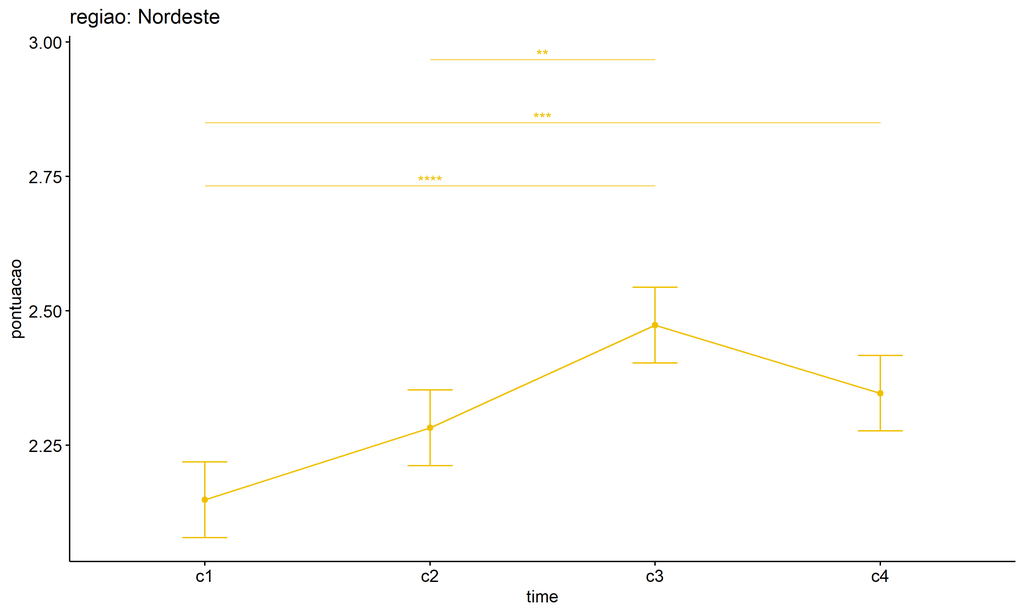

```r
if (length(non.ids) > 0) {
  emms.gg <- emms2[which(emms2$regiao == "Nordeste"),]
  if (nrow(emms.gg) > 0)
    ggline(emms.gg, x = "time", y = "emmean", color = "#EFC000FF", ylab = "pontuacao") +
    geom_errorbar(aes(ymin = conf.low, ymax = conf.high),
                  width = 0.2, color = "#EFC000FF") +
    stat_pvalue_manual(
      add_xy_position(pwc[which(pwc$regiao == "Nordeste"),],
                      x = "time", fun = "mean_se"),
      hide.ns = T, color = "#EFC000FF", tip.length = F) +
    labs(title = "regiao: Nordeste") +
    theme(legend.text = element_blank())
}
```

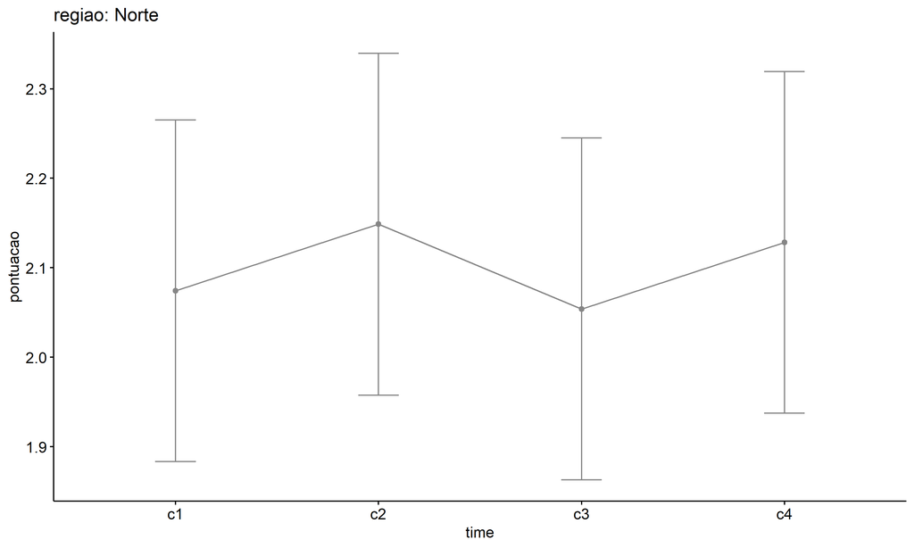

```r
if (length(non.ids) > 0) {
  emms.gg <- emms2[which(emms2$regiao == "Norte"),]
  if (nrow(emms.gg) > 0)
    ggline(emms.gg, x = "time", y = "emmean", color = "#868686FF", ylab = "pontuacao") +
    geom_errorbar(aes(ymin = conf.low, ymax = conf.high),
                  width = 0.2, color = "#868686FF") +
    stat_pvalue_manual(
      add_xy_position(pwc[which(pwc$regiao == "Norte"),],
                      x = "time", fun = "mean_se"),
      hide.ns = T, color = "#868686FF", tip.length = F) +
    labs(title = "regiao: Norte") +
    theme(legend.text = element_blank())
}
```

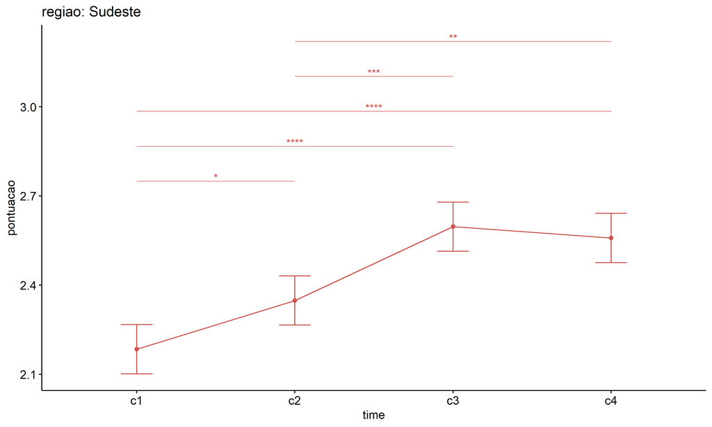

```r
if (length(non.ids) > 0) {
  emms.gg <- emms2[which(emms2$regiao == "Sudeste"),]
  if (nrow(emms.gg) > 0)
    ggline(emms.gg, x = "time", y = "emmean", color = "#CD534CFF", ylab = "pontuacao") +
    geom_errorbar(aes(ymin = conf.low, ymax = conf.high),
                  width = 0.2, color = "#CD534CFF") +
    stat_pvalue_manual(
      add_xy_position(pwc[which(pwc$regiao == "Sudeste"),],
                      x = "time", fun = "mean_se"),
      hide.ns = T, color = "#CD534CFF", tip.length = F) +
    labs(title = "regiao: Sudeste") +
    theme(legend.text = element_blank())
}
```

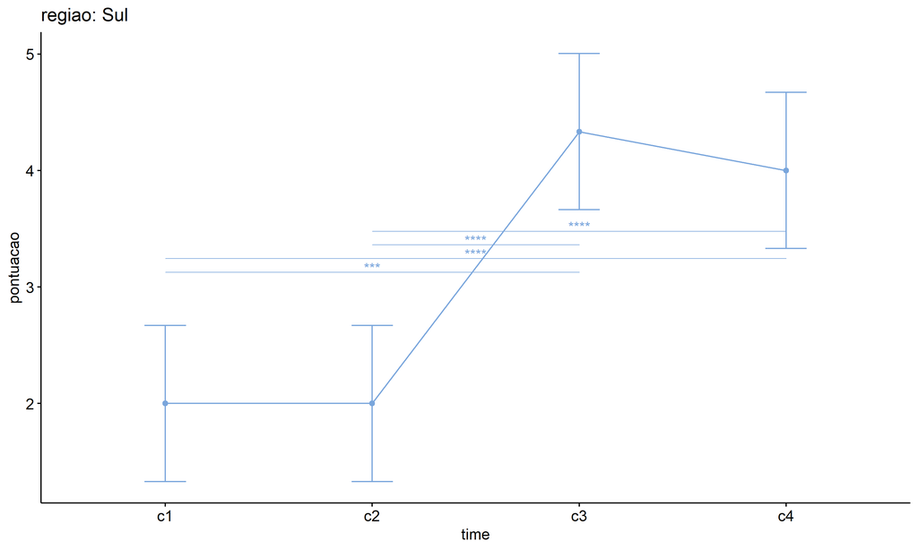

```r
if (length(non.ids) > 0) {
  emms.gg <- emms2[which(emms2$regiao == "Sul"),]
  if (nrow(emms.gg) > 0)
    ggline(emms.gg, x = "time", y = "emmean", color = "#7AA6DCFF", ylab = "pontuacao") +
    geom_errorbar(aes(ymin = conf.low, ymax = conf.high),
                  width = 0.2, color = "#7AA6DCFF") +
    stat_pvalue_manual(
      add_xy_position(pwc[which(pwc$regiao == "Sul"),],
                      x = "time", fun = "mean_se"),
      hide.ns = T, color = "#7AA6DCFF", tip.length = F) +
    labs(title = "regiao: Sul") +
    theme(legend.text = element_blank())
}
```

# ANOVA: pontuacao ~ time*porte + Error(id/time)

## Data Preparation

```r
data <- edat[,c("aluno_id","porte","ciclo","pontuacao")]
data$ciclo <- factor(data$ciclo, c("Primeiro Ciclo","Segundo Ciclo",
                                   "Terceiro Ciclo","Quarto Ciclo"))

wdat <- spread(data, ciclo, pontuacao)
wdat <- wdat[complete.cases(wdat),]
colnames(wdat) <- c("id","porte","c1","c2","c3","c4")

ldat <- gather(wdat, key = time, value = pontuacao, c1, c2, c3, c4) %>%
  convert_as_factor(id, time)
ldat <- remove_group_data(ldat, "pontuacao", c("time", "porte"), n.limit = 30)
ldat$porte <- factor(ldat$porte, sort(unique(ldat$porte)))
```

### Check assumptions: Identifying Outliers

```r
outliers <- identify_outliers(group_by(ldat, time, porte), pontuacao)
(outliers <- outliers[outliers$is.extreme == T,])
```

```
## # A tibble: 555 × 6
##    porte                                       time  id           pontuacao is.outlier is.extreme
##    <fct>                                       <fct> <fct>            <dbl> <lgl>      <lgl>
##  1 Até 50 matrículas de escolarização          c1    0w3VhiMf67C…       5   TRUE       TRUE
##  2 Até 50 matrículas de escolarização          c1    iutpBZMAtM9…       3.5 TRUE       TRUE
##  3 Até 50 matrículas de escolarização          c1    xAo0TzCEx1b…       3.5 TRUE       TRUE
##  4 Entre 201 e 500 matrículas de escolarização c1    0wDHSyctDDk…       5   TRUE       TRUE
##  5 Entre 201 e 500 matrículas de escolarização c1    46nUNvt4sDO…       4.5 TRUE       TRUE
##  6 Entre 201 e 500 matrículas de escolarização c1    4hmXg2uo4wx…       3.5 TRUE       TRUE
##  7 Entre 201 e 500 matrículas de escolarização c1    55GlwifTTyi…       5   TRUE       TRUE
##  8 Entre 201 e 500 matrículas de escolarização c1    5AeP0IQ84Ce…       3   TRUE       TRUE
##  9 Entre 201 e 500 matrículas de escolarização c1    6IoOZmGw52L…       3   TRUE       TRUE
## 10 Entre 201 e 500 matrículas de escolarização c1    6Xlhq905iNT…       5   TRUE       TRUE
## # ℹ 545 more rows
```

| porte | time | id | pontuacao | is.outlier | is.extreme |
| --- | --- | --- | --- | --- | --- |
| Até 50 matrículas de escolarização | c1 | 0w3VhiMf67CbcpR6aZCL | 5.000 | TRUE | TRUE |
| Até 50 matrículas de escolarização | c1 | iutpBZMAtM92qcbyCDHB | 3.500 | TRUE | TRUE |
| Até 50 matrículas de escolarização | c1 | xAo0TzCEx1bIrmjqKgbj | 3.500 | TRUE | TRUE |
| Entre 201 e 500 matrículas de escolarização | c1 | 0wDHSyctDDkjP6OPE3c8 | 5.000 | TRUE | TRUE |
| Entre 201 e 500 matrículas de escolarização | c1 | 46nUNvt4sDOPsC9jnkiG | 4.500 | TRUE | TRUE |
| Entre 201 e 500 matrículas de escolarização | c1 | 4hmXg2uo4wxSAX9SaxpN | 3.500 | TRUE | TRUE |
| Entre 201 e 500 matrículas de escolarização | c1 | 55GlwifTTyiOSKTB9vc9 | 5.000 | TRUE | TRUE |
| Entre 201 e 500 matrículas de escolarização | c1 | 5AeP0IQ84CerIQVenp2G | 3.000 | TRUE | TRUE |
| Entre 201 e 500 matrículas de escolarização | c1 | 6IoOZmGw52LYlznSYXzK | 3.000 | TRUE | TRUE |
| Entre 201 e 500 matrículas de escolarização | c1 | 6Xlhq905iNT5kvJFoSW5 | 5.000 | TRUE | TRUE |
| Entre 201 e 500 matrículas de escolarização | c1 | 7AaMrLZQiyhSoBaer5VH | 3.500 | TRUE | TRUE |
| Entre 201 e 500 matrículas de escolarização | c1 | 7nfO1ouMUuN7IzvlCKr0 | 3.500 | TRUE | TRUE |
| Entre 201 e 500 matrículas de escolarização | c1 | A5EETpEr617bpnSh1wp6 | 3.500 | TRUE | TRUE |
| Entre 201 e 500 matrículas de escolarização | c1 | AIzwxJCfbDsO8ZT4ZZ4h | 3.000 | TRUE | TRUE |
| Entre 201 e 500 matrículas de escolarização | c1 | b9PlhVhdvhl9EPK9QVCv | 5.000 | TRUE | TRUE |
| Entre 201 e 500 matrículas de escolarização | c1 | cuknOzzwN4oCRum5U5ph | 3.500 | TRUE | TRUE |
| Entre 201 e 500 matrículas de escolarização | c1 | cy0oZFPyT8aGHBq7CR9A | 3.500 | TRUE | TRUE |
| Entre 201 e 500 matrículas de escolarização | c1 | DFTbWP0xF5gxFgxEN0dL | 3.000 | TRUE | TRUE |
| Entre 201 e 500 matrículas de escolarização | c1 | E8XEhNJhfANZZtqHam0A | 3.000 | TRUE | TRUE |
| Entre 201 e 500 matrículas de escolarização | c1 | F5Ux4BYYqSnMt1Om6Trf | 3.500 | TRUE | TRUE |
| Entre 201 e 500 matrículas de escolarização | c1 | G2SUhDEavPTLyA8yz9AL | 3.500 | TRUE | TRUE |
| Entre 201 e 500 matrículas de escolarização | c1 | G4NIt8gEc7nfeQ9k2OkL | 3.500 | TRUE | TRUE |
| Entre 201 e 500 matrículas de escolarização | c1 | I1x9Y5cYi4OfnwWUeTXz | 4.000 | TRUE | TRUE |
| Entre 201 e 500 matrículas de escolarização | c1 | I5SKdDmPvNCpOHCfh7Is | 4.000 | TRUE | TRUE |
| Entre 201 e 500 matrículas de escolarização | c1 | i6M2WLEfaiylCRyZ9XnE | 3.500 | TRUE | TRUE |
| Entre 201 e 500 matrículas de escolarização | c1 | JdRySX8i3hE3pxcYyUcf | 3.000 | TRUE | TRUE |
| Entre 201 e 500 matrículas de escolarização | c1 | jVbbowshsqkUpPuGSIMu | 4.000 | TRUE | TRUE |
| Entre 201 e 500 matrículas de escolarização | c1 | KPMkDhksSiEWVEIUT1LG | 3.500 | TRUE | TRUE |
| Entre 201 e 500 matrículas de escolarização | c1 | lt4Za0V8VmneMBIicN4R | 3.000 | TRUE | TRUE |
| Entre 201 e 500 matrículas de escolarização | c1 | m5yRlxfIj73j4ossfTOB | 5.000 | TRUE | TRUE |

[output cut: 525 more lines]

### Check assumptions: Normality Test

```r
(normality.df <- normality.test.per.groups(ldat, "pontuacao", c("time", "porte")))
```

```
##          var  variable time                                        porte   n skewness   kurtosis
## 1  pontuacao pontuacao   c1           Até 50 matrículas de escolarização  33 0.000000  0.0000000
## 2  pontuacao pontuacao   c1  Entre 201 e 500 matrículas de escolarização 675 4.118760 16.4927710
## 3  pontuacao pontuacao   c1 Entre 501 e 1000 matrículas de escolarização 249 4.368458 19.4589784
## 4  pontuacao pontuacao   c1   Entre 51 e 200 matrículas de escolarização 162 3.104383  8.4340421
## 5  pontuacao pontuacao   c2           Até 50 matrículas de escolarização  33 2.839919  6.9026790
## 6  pontuacao pontuacao   c2  Entre 201 e 500 matrículas de escolarização 675 2.573266  5.4062222
## 7  pontuacao pontuacao   c2 Entre 501 e 1000 matrículas de escolarização 249 2.409031  4.3670851
## 8  pontuacao pontuacao   c2   Entre 51 e 200 matrículas de escolarização 162 4.119262 15.9197523
## 9  pontuacao pontuacao   c3           Até 50 matrículas de escolarização  33 0.000000  0.0000000
## 10 pontuacao pontuacao   c3  Entre 201 e 500 matrículas de escolarização 675 1.866493  1.8344271
## 11 pontuacao pontuacao   c3 Entre 501 e 1000 matrículas de escolarização 249 1.274218 -0.1245528
## 12 pontuacao pontuacao   c3   Entre 51 e 200 matrículas de escolarização 162 1.908484  1.9586671
## 13 pontuacao pontuacao   c4           Até 50 matrículas de escolarização  33 0.000000  0.0000000
## 14 pontuacao pontuacao   c4  Entre 201 e 500 matrículas de escolarização 675 2.126863  2.9304637
```

[output cut: 19 more lines]

| var | variable | time | porte | n | skewness | kurtosis | symmetry | statistic | method | p | p.signif | normality |
| --- | --- | --- | --- | --- | --- | --- | --- | --- | --- | --- | --- | --- |
| pontuacao | pontuacao | c1 | Até 50 matrículas de escolarização | 33 | 0.000 | 0.000 | few data | NA | NA | 1 | NA | NO |
| pontuacao | pontuacao | c1 | Entre 201 e 500 matrículas de escolarização | 675 | 4.119 | 16.493 | NO | 589.268 | D’Agostino | 0 | **** | - |
| pontuacao | pontuacao | c1 | Entre 501 e 1000 matrículas de escolarização | 249 | 4.368 | 19.459 | NO | 253.084 | D’Agostino | 0 | **** | - |
| pontuacao | pontuacao | c1 | Entre 51 e 200 matrículas de escolarização | 162 | 3.104 | 8.434 | NO | 125.639 | D’Agostino | 0 | **** | QQ |
| pontuacao | pontuacao | c2 | Até 50 matrículas de escolarização | 33 | 2.840 | 6.903 | NO | 0.377 | Shapiro-Wilk | 0 | **** | NO |
| pontuacao | pontuacao | c2 | Entre 201 e 500 matrículas de escolarização | 675 | 2.573 | 5.406 | NO | 358.757 | D’Agostino | 0 | **** | - |
| pontuacao | pontuacao | c2 | Entre 501 e 1000 matrículas de escolarização | 249 | 2.409 | 4.367 | NO | 131.616 | D’Agostino | 0 | **** | - |
| pontuacao | pontuacao | c2 | Entre 51 e 200 matrículas de escolarização | 162 | 4.119 | 15.920 | NO | 166.798 | D’Agostino | 0 | **** | QQ |
| pontuacao | pontuacao | c3 | Até 50 matrículas de escolarização | 33 | 0.000 | 0.000 | few data | NA | NA | 1 | NA | NO |
| pontuacao | pontuacao | c3 | Entre 201 e 500 matrículas de escolarização | 675 | 1.866 | 1.834 | NO | 222.455 | D’Agostino | 0 | **** | - |
| pontuacao | pontuacao | c3 | Entre 501 e 1000 matrículas de escolarização | 249 | 1.274 | -0.125 | NO | 45.706 | D’Agostino | 0 | **** | - |
| pontuacao | pontuacao | c3 | Entre 51 e 200 matrículas de escolarização | 162 | 1.908 | 1.959 | NO | 63.505 | D’Agostino | 0 | **** | QQ |
| pontuacao | pontuacao | c4 | Até 50 matrículas de escolarização | 33 | 0.000 | 0.000 | few data | NA | NA | 1 | NA | NO |
| pontuacao | pontuacao | c4 | Entre 201 e 500 matrículas de escolarização | 675 | 2.127 | 2.930 | NO | 273.301 | D’Agostino | 0 | **** | - |
| pontuacao | pontuacao | c4 | Entre 501 e 1000 matrículas de escolarização | 249 | 1.498 | 0.635 | NO | 60.589 | D’Agostino | 0 | **** | - |
| pontuacao | pontuacao | c4 | Entre 51 e 200 matrículas de escolarização | 162 | 2.106 | 2.753 | NO | 74.395 | D’Agostino | 0 | **** | QQ |

```r
(non.ids <- unique(do.call(
  c, lapply(which(normality.df$normality == 'NO'), FUN = function(i) {
  idx = which(ldat$time == normality.df$time[i] &
                ldat$porte == normality.df$porte[i])
  getNonNormal(ldat$"pontuacao"[idx], ldat$id[idx])
}))))
```

```
## [1] "0w3VhiMf67CbcpR6aZCL" "1ZE6i0Is22PBIAZbrM0J"
```

```r
if (length(non.ids) > 0)
  ldat2 <- ldat[!ldat$id %in% non.ids,]
```

### Summary Statistics

```r
(sdat <- ldat %>% group_by(time, porte) %>%
   get_summary_stats(pontuacao, type = "mean_sd"))
```

```
## # A tibble: 16 × 6
##    porte                                        time  variable      n  mean    sd
##    <fct>                                        <fct> <fct>     <dbl> <dbl> <dbl>
##  1 Até 50 matrículas de escolarização           c1    pontuacao    33  2.18 0.623
##  2 Entre 201 e 500 matrículas de escolarização  c1    pontuacao   675  2.14 0.558
##  3 Entre 501 e 1000 matrículas de escolarização c1    pontuacao   249  2.13 0.51
##  4 Entre 51 e 200 matrículas de escolarização   c1    pontuacao   162  2.22 0.707
##  5 Até 50 matrículas de escolarização           c2    pontuacao    33  2.26 0.772
##  6 Entre 201 e 500 matrículas de escolarização  c2    pontuacao   675  2.31 0.788
##  7 Entre 501 e 1000 matrículas de escolarização c2    pontuacao   249  2.33 0.837
##  8 Entre 51 e 200 matrículas de escolarização   c2    pontuacao   162  2.15 0.593
##  9 Até 50 matrículas de escolarização           c3    pontuacao    33  2.48 1.06
## 10 Entre 201 e 500 matrículas de escolarização  c3    pontuacao   675  2.46 0.989
## 11 Entre 501 e 1000 matrículas de escolarização c3    pontuacao   249  2.67 1.14
## 12 Entre 51 e 200 matrículas de escolarização   c3    pontuacao   162  2.45 0.996
## 13 Até 50 matrículas de escolarização           c4    pontuacao    33  2.46 1.09
## 14 Entre 201 e 500 matrículas de escolarização  c4    pontuacao   675  2.39 0.912
## 15 Entre 501 e 1000 matrículas de escolarização c4    pontuacao   249  2.57 1.04
## 16 Entre 51 e 200 matrículas de escolarização   c4    pontuacao   162  2.40 0.952
```

| porte | time | variable | n | mean | sd |
| --- | --- | --- | --- | --- | --- |
| Até 50 matrículas de escolarização | c1 | pontuacao | 33 | 2.182 | 0.623 |
| Entre 201 e 500 matrículas de escolarização | c1 | pontuacao | 675 | 2.143 | 0.558 |
| Entre 501 e 1000 matrículas de escolarização | c1 | pontuacao | 249 | 2.129 | 0.510 |
| Entre 51 e 200 matrículas de escolarização | c1 | pontuacao | 162 | 2.222 | 0.707 |
| Até 50 matrículas de escolarização | c2 | pontuacao | 33 | 2.258 | 0.772 |
| Entre 201 e 500 matrículas de escolarização | c2 | pontuacao | 675 | 2.305 | 0.788 |
| Entre 501 e 1000 matrículas de escolarização | c2 | pontuacao | 249 | 2.325 | 0.837 |
| Entre 51 e 200 matrículas de escolarização | c2 | pontuacao | 162 | 2.147 | 0.593 |
| Até 50 matrículas de escolarização | c3 | pontuacao | 33 | 2.485 | 1.064 |
| Entre 201 e 500 matrículas de escolarização | c3 | pontuacao | 675 | 2.463 | 0.989 |
| Entre 501 e 1000 matrículas de escolarização | c3 | pontuacao | 249 | 2.671 | 1.145 |
| Entre 51 e 200 matrículas de escolarização | c3 | pontuacao | 162 | 2.451 | 0.996 |
| Até 50 matrículas de escolarização | c4 | pontuacao | 33 | 2.455 | 1.092 |
| Entre 201 e 500 matrículas de escolarização | c4 | pontuacao | 675 | 2.387 | 0.912 |
| Entre 501 e 1000 matrículas de escolarização | c4 | pontuacao | 249 | 2.568 | 1.042 |
| Entre 51 e 200 matrículas de escolarização | c4 | pontuacao | 162 | 2.401 | 0.952 |

```r
if (length(non.ids) > 0)
  (sdat <- ldat2 %>% group_by(time, porte) %>%
      get_summary_stats(pontuacao, type = "mean_sd"))
```

```
## # A tibble: 16 × 6
##    porte                                        time  variable      n  mean    sd
##    <fct>                                        <fct> <fct>     <dbl> <dbl> <dbl>
##  1 Até 50 matrículas de escolarização           c1    pontuacao    31  2.10 0.375
##  2 Entre 201 e 500 matrículas de escolarização  c1    pontuacao   675  2.14 0.558
##  3 Entre 501 e 1000 matrículas de escolarização c1    pontuacao   249  2.13 0.51
##  4 Entre 51 e 200 matrículas de escolarização   c1    pontuacao   162  2.22 0.707
##  5 Até 50 matrículas de escolarização           c2    pontuacao    31  2.08 0.319
##  6 Entre 201 e 500 matrículas de escolarização  c2    pontuacao   675  2.31 0.788
##  7 Entre 501 e 1000 matrículas de escolarização c2    pontuacao   249  2.33 0.837
##  8 Entre 51 e 200 matrículas de escolarização   c2    pontuacao   162  2.15 0.593
##  9 Até 50 matrículas de escolarização           c3    pontuacao    31  2.42 0.992
## 10 Entre 201 e 500 matrículas de escolarização  c3    pontuacao   675  2.46 0.989
## 11 Entre 501 e 1000 matrículas de escolarização c3    pontuacao   249  2.67 1.14
## 12 Entre 51 e 200 matrículas de escolarização   c3    pontuacao   162  2.45 0.996
## 13 Até 50 matrículas de escolarização           c4    pontuacao    31  2.48 1.12
## 14 Entre 201 e 500 matrículas de escolarização  c4    pontuacao   675  2.39 0.912
## 15 Entre 501 e 1000 matrículas de escolarização c4    pontuacao   249  2.57 1.04
## 16 Entre 51 e 200 matrículas de escolarização   c4    pontuacao   162  2.40 0.952
```

| porte | time | variable | n | mean | sd |
| --- | --- | --- | --- | --- | --- |
| Até 50 matrículas de escolarização | c1 | pontuacao | 31 | 2.097 | 0.375 |
| Entre 201 e 500 matrículas de escolarização | c1 | pontuacao | 675 | 2.143 | 0.558 |
| Entre 501 e 1000 matrículas de escolarização | c1 | pontuacao | 249 | 2.129 | 0.510 |
| Entre 51 e 200 matrículas de escolarização | c1 | pontuacao | 162 | 2.222 | 0.707 |
| Até 50 matrículas de escolarização | c2 | pontuacao | 31 | 2.081 | 0.319 |
| Entre 201 e 500 matrículas de escolarização | c2 | pontuacao | 675 | 2.305 | 0.788 |
| Entre 501 e 1000 matrículas de escolarização | c2 | pontuacao | 249 | 2.325 | 0.837 |
| Entre 51 e 200 matrículas de escolarização | c2 | pontuacao | 162 | 2.147 | 0.593 |
| Até 50 matrículas de escolarização | c3 | pontuacao | 31 | 2.419 | 0.992 |
| Entre 201 e 500 matrículas de escolarização | c3 | pontuacao | 675 | 2.463 | 0.989 |
| Entre 501 e 1000 matrículas de escolarização | c3 | pontuacao | 249 | 2.671 | 1.145 |
| Entre 51 e 200 matrículas de escolarização | c3 | pontuacao | 162 | 2.451 | 0.996 |
| Até 50 matrículas de escolarização | c4 | pontuacao | 31 | 2.484 | 1.122 |
| Entre 201 e 500 matrículas de escolarização | c4 | pontuacao | 675 | 2.387 | 0.912 |
| Entre 501 e 1000 matrículas de escolarização | c4 | pontuacao | 249 | 2.568 | 1.042 |
| Entre 51 e 200 matrículas de escolarização | c4 | pontuacao | 162 | 2.401 | 0.952 |

## ANOVA Computation

```r
(res.aov <- anova_test(ldat, dv = pontuacao, wid = id, between = porte, within = time))
```

```
## ANOVA Table (type III tests)
##
## $ANOVA
##       Effect DFn  DFd      F        p p<.05   ges
## 1      porte   3 1115  2.893 3.40e-02     * 0.003
## 2       time   3 3345 15.614 4.39e-10     * 0.009
## 3 porte:time   9 3345  1.931 4.30e-02     * 0.003
##
## $`Mauchly's Test for Sphericity`
##       Effect     W        p p<.05
## 1       time 0.913 3.17e-20     *
## 2 porte:time 0.913 3.17e-20     *
##
## $`Sphericity Corrections`
##       Effect   GGe       DF[GG]   p[GG] p[GG]<.05   HFe        DF[HF]    p[HF] p[HF]<.05
## 1       time 0.949 2.85, 3174.3 1.1e-09         * 0.952 2.85, 3183.28 1.05e-09         *
## 2 porte:time 0.949 8.54, 3174.3 4.7e-02         * 0.952 8.56, 3183.28 4.70e-02         *
```

| Effect | DFn | DFd | F | p | p<.05 | ges |
| --- | --- | --- | --- | --- | --- | --- |
| porte | 3 | 1115 | 2.893 | 0.034 | * | 0.003 |
| time | 3 | 3345 | 15.614 | 0.000 | * | 0.009 |
| porte:time | 9 | 3345 | 1.931 | 0.043 | * | 0.003 |

| Effect | W | p | p<.05 |
| --- | --- | --- | --- |
| time | 0.913 | 0 | * |
| porte:time | 0.913 | 0 | * |

| Effect | GGe | DF[GG] | p[GG] | p[GG]<.05 | HFe | DF[HF] | p[HF] | p[HF]<.05 |
| --- | --- | --- | --- | --- | --- | --- | --- | --- |
| time | 0.949 | 2.85, 3174.3 | 0.000 | * | 0.952 | 2.85, 3183.28 | 0.000 | * |
| porte:time | 0.949 | 8.54, 3174.3 | 0.047 | * | 0.952 | 8.56, 3183.28 | 0.047 | * |

## ANOVA Computation after removing non.normal data

```r
if (length(non.ids) > 0)
  (res.aov2 <- anova_test(ldat2, dv = pontuacao, wid = id, between = porte , within = time))
```

```
## ANOVA Table (type III tests)
##
## $ANOVA
##       Effect DFn  DFd      F        p p<.05   ges
## 1      porte   3 1113  3.153 2.40e-02     * 0.003
## 2       time   3 3339 17.495 2.88e-11     * 0.010
## 3 porte:time   9 3339  2.108 2.60e-02     * 0.004
##
## $`Mauchly's Test for Sphericity`
##       Effect     W        p p<.05
## 1       time 0.913 3.01e-20     *
## 2 porte:time 0.913 3.01e-20     *
##
## $`Sphericity Corrections`
##       Effect   GGe        DF[GG]    p[GG] p[GG]<.05   HFe        DF[HF]    p[HF] p[HF]<.05
## 1       time 0.949 2.85, 3167.66 8.31e-11         * 0.951 2.85, 3176.63 7.86e-11         *
## 2 porte:time 0.949 8.54, 3167.66 2.80e-02         * 0.951 8.56, 3176.63 2.80e-02         *
```

| Effect | DFn | DFd | F | p | p<.05 | ges |
| --- | --- | --- | --- | --- | --- | --- |
| porte | 3 | 1113 | 3.153 | 0.024 | * | 0.003 |
| time | 3 | 3339 | 17.495 | 0.000 | * | 0.010 |
| porte:time | 9 | 3339 | 2.108 | 0.026 | * | 0.004 |

| Effect | W | p | p<.05 |
| --- | --- | --- | --- |
| time | 0.913 | 0 | * |
| porte:time | 0.913 | 0 | * |

| Effect | GGe | DF[GG] | p[GG] | p[GG]<.05 | HFe | DF[HF] | p[HF] | p[HF]<.05 |
| --- | --- | --- | --- | --- | --- | --- | --- | --- |
| time | 0.949 | 2.85, 3167.66 | 0.000 | * | 0.951 | 2.85, 3176.63 | 0.000 | * |
| porte:time | 0.949 | 8.54, 3167.66 | 0.028 | * | 0.951 | 8.56, 3176.63 | 0.028 | * |

## PairWise Computation

```r
(pwc <- ldat %>% group_by(time) %>%
   emmeans_test(pontuacao ~ porte, detailed = T, p.adjust.method = "bonferroni"))
```

```
## # A tibble: 24 × 15
##    time  term  .y.    group1 group2 null.value estimate     se    df conf.low conf.high statistic
##  * <fct> <chr> <chr>  <chr>  <chr>       <dbl>    <dbl>  <dbl> <dbl>    <dbl>     <dbl>     <dbl>
##  1 c1    porte pontu… Até 5… Entre…          0   0.0389 0.152   4460   -0.259    0.336      0.256
##  2 c1    porte pontu… Até 5… Entre…          0   0.0533 0.158   4460   -0.256    0.362      0.338
##  3 c1    porte pontu… Até 5… Entre…          0  -0.0404 0.163   4460   -0.359    0.278     -0.249
##  4 c1    porte pontu… Entre… Entre…          0   0.0144 0.0631  4460   -0.109    0.138      0.229
##  5 c1    porte pontu… Entre… Entre…          0  -0.0793 0.0744  4460   -0.225    0.0667    -1.06
##  6 c1    porte pontu… Entre… Entre…          0  -0.0937 0.0859  4460   -0.262    0.0747    -1.09
##  7 c2    porte pontu… Até 5… Entre…          0  -0.0477 0.152   4460   -0.345    0.250     -0.315
##  8 c2    porte pontu… Até 5… Entre…          0  -0.0677 0.158   4460   -0.377    0.241     -0.430
##  9 c2    porte pontu… Até 5… Entre…          0   0.111  0.163   4460   -0.208    0.430      0.683
## 10 c2    porte pontu… Entre… Entre…          0  -0.0200 0.0631  4460   -0.144    0.104     -0.317
## # ℹ 14 more rows
## # ℹ 3 more variables: p <dbl>, p.adj <dbl>, p.adj.signif <chr>
```

| time | term | .y. | group1 | group2 | null.value | estimate | se | df | conf.low | conf.high | statistic | p | p.adj | p.adj.signif |
| --- | --- | --- | --- | --- | --- | --- | --- | --- | --- | --- | --- | --- | --- | --- |
| c1 | porte | pontuacao | Até 50 matrículas de escolarização | Entre 201 e 500 matrículas de escolarização | 0 | 0.039 | 0.152 | 4460 | -0.259 | 0.336 | 0.256 | 0.798 | 1.000 | ns |
| c1 | porte | pontuacao | Até 50 matrículas de escolarização | Entre 501 e 1000 matrículas de escolarização | 0 | 0.053 | 0.158 | 4460 | -0.256 | 0.362 | 0.338 | 0.735 | 1.000 | ns |
| c1 | porte | pontuacao | Até 50 matrículas de escolarização | Entre 51 e 200 matrículas de escolarização | 0 | -0.040 | 0.163 | 4460 | -0.359 | 0.278 | -0.249 | 0.804 | 1.000 | ns |
| c1 | porte | pontuacao | Entre 201 e 500 matrículas de escolarização | Entre 501 e 1000 matrículas de escolarização | 0 | 0.014 | 0.063 | 4460 | -0.109 | 0.138 | 0.229 | 0.819 | 1.000 | ns |
| c1 | porte | pontuacao | Entre 201 e 500 matrículas de escolarização | Entre 51 e 200 matrículas de escolarização | 0 | -0.079 | 0.074 | 4460 | -0.225 | 0.067 | -1.065 | 0.287 | 1.000 | ns |
| c1 | porte | pontuacao | Entre 501 e 1000 matrículas de escolarização | Entre 51 e 200 matrículas de escolarização | 0 | -0.094 | 0.086 | 4460 | -0.262 | 0.075 | -1.091 | 0.275 | 1.000 | ns |
| c2 | porte | pontuacao | Até 50 matrículas de escolarização | Entre 201 e 500 matrículas de escolarização | 0 | -0.048 | 0.152 | 4460 | -0.345 | 0.250 | -0.315 | 0.753 | 1.000 | ns |
| c2 | porte | pontuacao | Até 50 matrículas de escolarização | Entre 501 e 1000 matrículas de escolarização | 0 | -0.068 | 0.158 | 4460 | -0.377 | 0.241 | -0.430 | 0.667 | 1.000 | ns |
| c2 | porte | pontuacao | Até 50 matrículas de escolarização | Entre 51 e 200 matrículas de escolarização | 0 | 0.111 | 0.163 | 4460 | -0.208 | 0.430 | 0.683 | 0.495 | 1.000 | ns |
| c2 | porte | pontuacao | Entre 201 e 500 matrículas de escolarização | Entre 501 e 1000 matrículas de escolarização | 0 | -0.020 | 0.063 | 4460 | -0.144 | 0.104 | -0.317 | 0.751 | 1.000 | ns |
| c2 | porte | pontuacao | Entre 201 e 500 matrículas de escolarização | Entre 51 e 200 matrículas de escolarização | 0 | 0.159 | 0.074 | 4460 | 0.013 | 0.305 | 2.132 | 0.033 | 0.198 | ns |
| c2 | porte | pontuacao | Entre 501 e 1000 matrículas de escolarização | Entre 51 e 200 matrículas de escolarização | 0 | 0.179 | 0.086 | 4460 | 0.010 | 0.347 | 2.081 | 0.038 | 0.225 | ns |
| c3 | porte | pontuacao | Até 50 matrículas de escolarização | Entre 201 e 500 matrículas de escolarização | 0 | 0.022 | 0.152 | 4460 | -0.276 | 0.319 | 0.144 | 0.885 | 1.000 | ns |
| c3 | porte | pontuacao | Até 50 matrículas de escolarização | Entre 501 e 1000 matrículas de escolarização | 0 | -0.186 | 0.158 | 4460 | -0.495 | 0.123 | -1.179 | 0.238 | 1.000 | ns |
| c3 | porte | pontuacao | Até 50 matrículas de escolarização | Entre 51 e 200 matrículas de escolarização | 0 | 0.034 | 0.163 | 4460 | -0.284 | 0.353 | 0.211 | 0.833 | 1.000 | ns |
| c3 | porte | pontuacao | Entre 201 e 500 matrículas de escolarização | Entre 501 e 1000 matrículas de escolarização | 0 | -0.208 | 0.063 | 4460 | -0.331 | -0.084 | -3.293 | 0.001 | 0.006 | ** |
| c3 | porte | pontuacao | Entre 201 e 500 matrículas de escolarização | Entre 51 e 200 matrículas de escolarização | 0 | 0.012 | 0.074 | 4460 | -0.134 | 0.158 | 0.166 | 0.868 | 1.000 | ns |
| c3 | porte | pontuacao | Entre 501 e 1000 matrículas de escolarização | Entre 51 e 200 matrículas de escolarização | 0 | 0.220 | 0.086 | 4460 | 0.052 | 0.388 | 2.562 | 0.010 | 0.063 | ns |
| c4 | porte | pontuacao | Até 50 matrículas de escolarização | Entre 201 e 500 matrículas de escolarização | 0 | 0.068 | 0.152 | 4460 | -0.230 | 0.365 | 0.447 | 0.655 | 1.000 | ns |
| c4 | porte | pontuacao | Até 50 matrículas de escolarização | Entre 501 e 1000 matrículas de escolarização | 0 | -0.114 | 0.158 | 4460 | -0.423 | 0.195 | -0.722 | 0.471 | 1.000 | ns |
| c4 | porte | pontuacao | Até 50 matrículas de escolarização | Entre 51 e 200 matrículas de escolarização | 0 | 0.053 | 0.163 | 4460 | -0.265 | 0.372 | 0.328 | 0.743 | 1.000 | ns |
| c4 | porte | pontuacao | Entre 201 e 500 matrículas de escolarização | Entre 501 e 1000 matrículas de escolarização | 0 | -0.182 | 0.063 | 4460 | -0.305 | -0.058 | -2.879 | 0.004 | 0.024 | * |
| c4 | porte | pontuacao | Entre 201 e 500 matrículas de escolarização | Entre 51 e 200 matrículas de escolarização | 0 | -0.015 | 0.074 | 4460 | -0.161 | 0.131 | -0.196 | 0.845 | 1.000 | ns |
| c4 | porte | pontuacao | Entre 501 e 1000 matrículas de escolarização | Entre 51 e 200 matrículas de escolarização | 0 | 0.167 | 0.086 | 4460 | -0.001 | 0.335 | 1.945 | 0.052 | 0.311 | ns |

```r
(emms <- get_emmeans(pwc))
```

```
## # A tibble: 16 × 8
##    time  porte                                      emmean     se    df conf.low conf.high method
##    <fct> <fct>                                       <dbl>  <dbl> <dbl>    <dbl>     <dbl> <chr>
##  1 c1    Até 50 matrículas de escolarização           2.18 0.148   4460     1.89      2.47 Emmea…
##  2 c1    Entre 201 e 500 matrículas de escolarizaç…   2.14 0.0327  4460     2.08      2.21 Emmea…
##  3 c1    Entre 501 e 1000 matrículas de escolariza…   2.13 0.0539  4460     2.02      2.23 Emmea…
##  4 c1    Entre 51 e 200 matrículas de escolarização   2.22 0.0668  4460     2.09      2.35 Emmea…
##  5 c2    Até 50 matrículas de escolarização           2.26 0.148   4460     1.97      2.55 Emmea…
##  6 c2    Entre 201 e 500 matrículas de escolarizaç…   2.31 0.0327  4460     2.24      2.37 Emmea…
##  7 c2    Entre 501 e 1000 matrículas de escolariza…   2.33 0.0539  4460     2.22      2.43 Emmea…
##  8 c2    Entre 51 e 200 matrículas de escolarização   2.15 0.0668  4460     2.02      2.28 Emmea…
##  9 c3    Até 50 matrículas de escolarização           2.48 0.148   4460     2.19      2.78 Emmea…
## 10 c3    Entre 201 e 500 matrículas de escolarizaç…   2.46 0.0327  4460     2.40      2.53 Emmea…
## 11 c3    Entre 501 e 1000 matrículas de escolariza…   2.67 0.0539  4460     2.56      2.78 Emmea…
## 12 c3    Entre 51 e 200 matrículas de escolarização   2.45 0.0668  4460     2.32      2.58 Emmea…
## 13 c4    Até 50 matrículas de escolarização           2.45 0.148   4460     2.16      2.74 Emmea…
## 14 c4    Entre 201 e 500 matrículas de escolarizaç…   2.39 0.0327  4460     2.32      2.45 Emmea…
## 15 c4    Entre 501 e 1000 matrículas de escolariza…   2.57 0.0539  4460     2.46      2.67 Emmea…
## 16 c4    Entre 51 e 200 matrículas de escolarização   2.40 0.0668  4460     2.27      2.53 Emmea…
```

| time | porte | emmean | se | df | conf.low | conf.high | method |
| --- | --- | --- | --- | --- | --- | --- | --- |
| c1 | Até 50 matrículas de escolarização | 2.182 | 0.148 | 4460 | 1.891 | 2.472 | Emmeans test |
| c1 | Entre 201 e 500 matrículas de escolarização | 2.143 | 0.033 | 4460 | 2.079 | 2.207 | Emmeans test |
| c1 | Entre 501 e 1000 matrículas de escolarização | 2.129 | 0.054 | 4460 | 2.023 | 2.234 | Emmeans test |
| c1 | Entre 51 e 200 matrículas de escolarização | 2.222 | 0.067 | 4460 | 2.091 | 2.353 | Emmeans test |
| c2 | Até 50 matrículas de escolarização | 2.258 | 0.148 | 4460 | 1.967 | 2.548 | Emmeans test |
| c2 | Entre 201 e 500 matrículas de escolarização | 2.305 | 0.033 | 4460 | 2.241 | 2.370 | Emmeans test |
| c2 | Entre 501 e 1000 matrículas de escolarização | 2.325 | 0.054 | 4460 | 2.220 | 2.431 | Emmeans test |
| c2 | Entre 51 e 200 matrículas de escolarização | 2.147 | 0.067 | 4460 | 2.016 | 2.278 | Emmeans test |
| c3 | Até 50 matrículas de escolarização | 2.485 | 0.148 | 4460 | 2.194 | 2.775 | Emmeans test |
| c3 | Entre 201 e 500 matrículas de escolarização | 2.463 | 0.033 | 4460 | 2.399 | 2.527 | Emmeans test |
| c3 | Entre 501 e 1000 matrículas de escolarização | 2.671 | 0.054 | 4460 | 2.565 | 2.776 | Emmeans test |
| c3 | Entre 51 e 200 matrículas de escolarização | 2.451 | 0.067 | 4460 | 2.320 | 2.582 | Emmeans test |
| c4 | Até 50 matrículas de escolarização | 2.455 | 0.148 | 4460 | 2.164 | 2.745 | Emmeans test |
| c4 | Entre 201 e 500 matrículas de escolarização | 2.387 | 0.033 | 4460 | 2.322 | 2.451 | Emmeans test |
| c4 | Entre 501 e 1000 matrículas de escolarização | 2.568 | 0.054 | 4460 | 2.463 | 2.674 | Emmeans test |
| c4 | Entre 51 e 200 matrículas de escolarização | 2.401 | 0.067 | 4460 | 2.270 | 2.532 | Emmeans test |

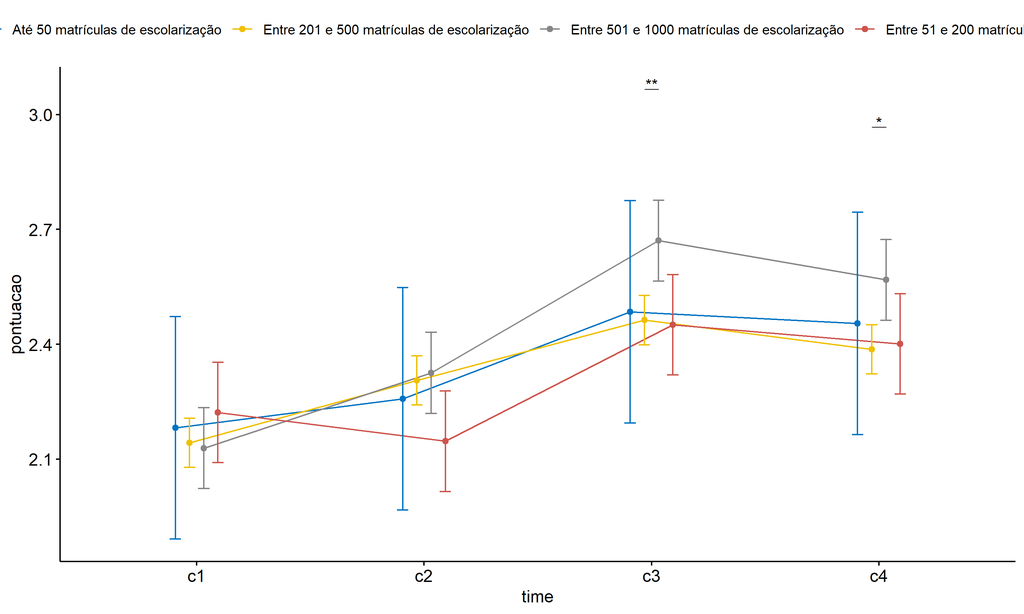

```r
pwc <- add_xy_position(pwc, x = "time", fun = "mean_se", dodge = 0.25)
pd <- position_dodge(width = 0.25)
ggline(emms, x = "time", y = "emmean", color = "porte",
       palette = c("#0073C2FF","#EFC000FF","#868686FF","#CD534CFF","#7AA6DCFF"),
       position = pd, ylab = "pontuacao") +
  geom_errorbar(aes(ymin = conf.low, ymax = conf.high, color = porte),
                position = pd, width = 0.2) +
  stat_pvalue_manual(pwc, hide.ns = T, tip.length = F, linetype = 1)
```

```r
(pwc <- ldat %>% group_by(porte) %>%
    emmeans_test(pontuacao ~ time, detailed = T, p.adjust.method = "bonferroni"))
```

```
## # A tibble: 24 × 15
##    porte  term  .y.   group1 group2 null.value estimate     se    df conf.low conf.high statistic
##  * <fct>  <chr> <chr> <chr>  <chr>       <dbl>    <dbl>  <dbl> <dbl>    <dbl>     <dbl>     <dbl>
##  1 Até 5… time  pont… c1     c2              0  -0.0758 0.209   4460   -0.486    0.335     -0.362
##  2 Até 5… time  pont… c1     c3              0  -0.303  0.209   4460   -0.714    0.108     -1.45
##  3 Até 5… time  pont… c1     c4              0  -0.273  0.209   4460   -0.683    0.138     -1.30
##  4 Até 5… time  pont… c2     c3              0  -0.227  0.209   4460   -0.638    0.183     -1.09
##  5 Até 5… time  pont… c2     c4              0  -0.197  0.209   4460   -0.608    0.214     -0.940
##  6 Até 5… time  pont… c3     c4              0   0.0303 0.209   4460   -0.380    0.441      0.145
##  7 Entre… time  pont… c1     c2              0  -0.162  0.0463  4460   -0.253   -0.0715    -3.51
##  8 Entre… time  pont… c1     c3              0  -0.320  0.0463  4460   -0.411   -0.229     -6.91
##  9 Entre… time  pont… c1     c4              0  -0.244  0.0463  4460   -0.335   -0.153     -5.26
## 10 Entre… time  pont… c2     c3              0  -0.158  0.0463  4460   -0.248   -0.0669    -3.40
## # ℹ 14 more rows
## # ℹ 3 more variables: p <dbl>, p.adj <dbl>, p.adj.signif <chr>
```

| porte | term | .y. | group1 | group2 | null.value | estimate | se | df | conf.low | conf.high | statistic | p | p.adj | p.adj.signif |
| --- | --- | --- | --- | --- | --- | --- | --- | --- | --- | --- | --- | --- | --- | --- |
| Até 50 matrículas de escolarização | time | pontuacao | c1 | c2 | 0 | -0.076 | 0.209 | 4460 | -0.486 | 0.335 | -0.362 | 0.718 | 1.000 | ns |
| Até 50 matrículas de escolarização | time | pontuacao | c1 | c3 | 0 | -0.303 | 0.209 | 4460 | -0.714 | 0.108 | -1.447 | 0.148 | 0.888 | ns |
| Até 50 matrículas de escolarização | time | pontuacao | c1 | c4 | 0 | -0.273 | 0.209 | 4460 | -0.683 | 0.138 | -1.302 | 0.193 | 1.000 | ns |
| Até 50 matrículas de escolarização | time | pontuacao | c2 | c3 | 0 | -0.227 | 0.209 | 4460 | -0.638 | 0.183 | -1.085 | 0.278 | 1.000 | ns |
| Até 50 matrículas de escolarização | time | pontuacao | c2 | c4 | 0 | -0.197 | 0.209 | 4460 | -0.608 | 0.214 | -0.940 | 0.347 | 1.000 | ns |
| Até 50 matrículas de escolarização | time | pontuacao | c3 | c4 | 0 | 0.030 | 0.209 | 4460 | -0.380 | 0.441 | 0.145 | 0.885 | 1.000 | ns |
| Entre 201 e 500 matrículas de escolarização | time | pontuacao | c1 | c2 | 0 | -0.162 | 0.046 | 4460 | -0.253 | -0.072 | -3.505 | 0.000 | 0.003 | ** |
| Entre 201 e 500 matrículas de escolarização | time | pontuacao | c1 | c3 | 0 | -0.320 | 0.046 | 4460 | -0.411 | -0.229 | -6.909 | 0.000 | 0.000 | **** |
| Entre 201 e 500 matrículas de escolarização | time | pontuacao | c1 | c4 | 0 | -0.244 | 0.046 | 4460 | -0.335 | -0.153 | -5.262 | 0.000 | 0.000 | **** |
| Entre 201 e 500 matrículas de escolarização | time | pontuacao | c2 | c3 | 0 | -0.158 | 0.046 | 4460 | -0.248 | -0.067 | -3.404 | 0.001 | 0.004 | ** |
| Entre 201 e 500 matrículas de escolarização | time | pontuacao | c2 | c4 | 0 | -0.081 | 0.046 | 4460 | -0.172 | 0.009 | -1.757 | 0.079 | 0.474 | ns |
| Entre 201 e 500 matrículas de escolarização | time | pontuacao | c3 | c4 | 0 | 0.076 | 0.046 | 4460 | -0.015 | 0.167 | 1.647 | 0.100 | 0.597 | ns |
| Entre 501 e 1000 matrículas de escolarização | time | pontuacao | c1 | c2 | 0 | -0.197 | 0.076 | 4460 | -0.346 | -0.047 | -2.581 | 0.010 | 0.059 | ns |
| Entre 501 e 1000 matrículas de escolarização | time | pontuacao | c1 | c3 | 0 | -0.542 | 0.076 | 4460 | -0.692 | -0.393 | -7.110 | 0.000 | 0.000 | **** |
| Entre 501 e 1000 matrículas de escolarização | time | pontuacao | c1 | c4 | 0 | -0.440 | 0.076 | 4460 | -0.589 | -0.290 | -5.767 | 0.000 | 0.000 | **** |
| Entre 501 e 1000 matrículas de escolarização | time | pontuacao | c2 | c3 | 0 | -0.345 | 0.076 | 4460 | -0.495 | -0.196 | -4.529 | 0.000 | 0.000 | **** |
| Entre 501 e 1000 matrículas de escolarização | time | pontuacao | c2 | c4 | 0 | -0.243 | 0.076 | 4460 | -0.392 | -0.093 | -3.186 | 0.001 | 0.009 | ** |
| Entre 501 e 1000 matrículas de escolarização | time | pontuacao | c3 | c4 | 0 | 0.102 | 0.076 | 4460 | -0.047 | 0.252 | 1.343 | 0.179 | 1.000 | ns |
| Entre 51 e 200 matrículas de escolarização | time | pontuacao | c1 | c2 | 0 | 0.076 | 0.095 | 4460 | -0.110 | 0.261 | 0.800 | 0.424 | 1.000 | ns |
| Entre 51 e 200 matrículas de escolarização | time | pontuacao | c1 | c3 | 0 | -0.228 | 0.095 | 4460 | -0.414 | -0.043 | -2.416 | 0.016 | 0.094 | ns |
| Entre 51 e 200 matrículas de escolarização | time | pontuacao | c1 | c4 | 0 | -0.179 | 0.095 | 4460 | -0.364 | 0.006 | -1.894 | 0.058 | 0.350 | ns |
| Entre 51 e 200 matrículas de escolarização | time | pontuacao | c2 | c3 | 0 | -0.304 | 0.095 | 4460 | -0.489 | -0.119 | -3.216 | 0.001 | 0.008 | ** |
| Entre 51 e 200 matrículas de escolarização | time | pontuacao | c2 | c4 | 0 | -0.255 | 0.095 | 4460 | -0.440 | -0.069 | -2.693 | 0.007 | 0.043 | * |
| Entre 51 e 200 matrículas de escolarização | time | pontuacao | c3 | c4 | 0 | 0.049 | 0.095 | 4460 | -0.136 | 0.235 | 0.522 | 0.601 | 1.000 | ns |

```r
(emms <- get_emmeans(pwc))
```

```
## # A tibble: 16 × 8
##    porte                                      time  emmean     se    df conf.low conf.high method
##    <fct>                                      <fct>  <dbl>  <dbl> <dbl>    <dbl>     <dbl> <chr>
##  1 Até 50 matrículas de escolarização         c1      2.18 0.148   4460     1.89      2.47 Emmea…
##  2 Até 50 matrículas de escolarização         c2      2.26 0.148   4460     1.97      2.55 Emmea…
##  3 Até 50 matrículas de escolarização         c3      2.48 0.148   4460     2.19      2.78 Emmea…
##  4 Até 50 matrículas de escolarização         c4      2.45 0.148   4460     2.16      2.74 Emmea…
##  5 Entre 201 e 500 matrículas de escolarizaç… c1      2.14 0.0327  4460     2.08      2.21 Emmea…
##  6 Entre 201 e 500 matrículas de escolarizaç… c2      2.31 0.0327  4460     2.24      2.37 Emmea…
##  7 Entre 201 e 500 matrículas de escolarizaç… c3      2.46 0.0327  4460     2.40      2.53 Emmea…
##  8 Entre 201 e 500 matrículas de escolarizaç… c4      2.39 0.0327  4460     2.32      2.45 Emmea…
##  9 Entre 501 e 1000 matrículas de escolariza… c1      2.13 0.0539  4460     2.02      2.23 Emmea…
## 10 Entre 501 e 1000 matrículas de escolariza… c2      2.33 0.0539  4460     2.22      2.43 Emmea…
## 11 Entre 501 e 1000 matrículas de escolariza… c3      2.67 0.0539  4460     2.56      2.78 Emmea…
## 12 Entre 501 e 1000 matrículas de escolariza… c4      2.57 0.0539  4460     2.46      2.67 Emmea…
## 13 Entre 51 e 200 matrículas de escolarização c1      2.22 0.0668  4460     2.09      2.35 Emmea…
## 14 Entre 51 e 200 matrículas de escolarização c2      2.15 0.0668  4460     2.02      2.28 Emmea…
## 15 Entre 51 e 200 matrículas de escolarização c3      2.45 0.0668  4460     2.32      2.58 Emmea…
## 16 Entre 51 e 200 matrículas de escolarização c4      2.40 0.0668  4460     2.27      2.53 Emmea…
```

| porte | time | emmean | se | df | conf.low | conf.high | method |
| --- | --- | --- | --- | --- | --- | --- | --- |
| Até 50 matrículas de escolarização | c1 | 2.182 | 0.148 | 4460 | 1.891 | 2.472 | Emmeans test |
| Até 50 matrículas de escolarização | c2 | 2.258 | 0.148 | 4460 | 1.967 | 2.548 | Emmeans test |
| Até 50 matrículas de escolarização | c3 | 2.485 | 0.148 | 4460 | 2.194 | 2.775 | Emmeans test |
| Até 50 matrículas de escolarização | c4 | 2.455 | 0.148 | 4460 | 2.164 | 2.745 | Emmeans test |
| Entre 201 e 500 matrículas de escolarização | c1 | 2.143 | 0.033 | 4460 | 2.079 | 2.207 | Emmeans test |
| Entre 201 e 500 matrículas de escolarização | c2 | 2.305 | 0.033 | 4460 | 2.241 | 2.370 | Emmeans test |
| Entre 201 e 500 matrículas de escolarização | c3 | 2.463 | 0.033 | 4460 | 2.399 | 2.527 | Emmeans test |
| Entre 201 e 500 matrículas de escolarização | c4 | 2.387 | 0.033 | 4460 | 2.322 | 2.451 | Emmeans test |
| Entre 501 e 1000 matrículas de escolarização | c1 | 2.129 | 0.054 | 4460 | 2.023 | 2.234 | Emmeans test |
| Entre 501 e 1000 matrículas de escolarização | c2 | 2.325 | 0.054 | 4460 | 2.220 | 2.431 | Emmeans test |
| Entre 501 e 1000 matrículas de escolarização | c3 | 2.671 | 0.054 | 4460 | 2.565 | 2.776 | Emmeans test |
| Entre 501 e 1000 matrículas de escolarização | c4 | 2.568 | 0.054 | 4460 | 2.463 | 2.674 | Emmeans test |
| Entre 51 e 200 matrículas de escolarização | c1 | 2.222 | 0.067 | 4460 | 2.091 | 2.353 | Emmeans test |
| Entre 51 e 200 matrículas de escolarização | c2 | 2.147 | 0.067 | 4460 | 2.016 | 2.278 | Emmeans test |
| Entre 51 e 200 matrículas de escolarização | c3 | 2.451 | 0.067 | 4460 | 2.320 | 2.582 | Emmeans test |
| Entre 51 e 200 matrículas de escolarização | c4 | 2.401 | 0.067 | 4460 | 2.270 | 2.532 | Emmeans test |

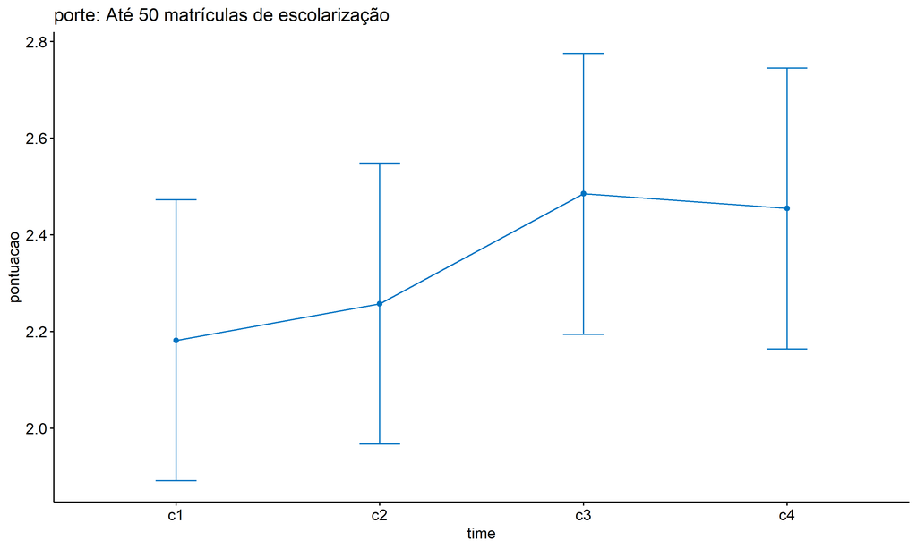

```r
emms.gg <- emms[which(emms$porte == "Até 50 matrículas de escolarização"),]
if (nrow(emms.gg) > 0)
  ggline(emms.gg, x = "time", y = "emmean", color = "#0073C2FF", ylab = "pontuacao") +
    geom_errorbar(aes(ymin = conf.low, ymax = conf.high),
                  width = 0.2, color = "#0073C2FF") +
    stat_pvalue_manual(
      add_xy_position(pwc[which(pwc$porte == "Até 50 matrículas de escolarização"),],
                      x = "time", fun = "mean_se"),
      hide.ns = T, color = "#0073C2FF", tip.length = F) +
    labs(title = "porte: Até 50 matrículas de escolarização")+
    theme(legend.text = element_blank())
```

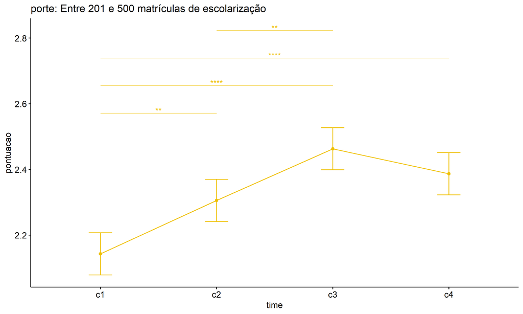

```r
emms.gg <- emms[which(emms$porte == "Entre 201 e 500 matrículas de escolarização"),]
if (nrow(emms.gg) > 0)
  ggline(emms.gg, x = "time", y = "emmean", color = "#EFC000FF", ylab = "pontuacao") +
    geom_errorbar(aes(ymin = conf.low, ymax = conf.high),
                  width = 0.2, color = "#EFC000FF") +
    stat_pvalue_manual(
      add_xy_position(pwc[which(pwc$porte == "Entre 201 e 500 matrículas de escolarização"),],
                      x = "time", fun = "mean_se"),
      hide.ns = T, color = "#EFC000FF", tip.length = F) +
    labs(title = "porte: Entre 201 e 500 matrículas de escolarização")+
    theme(legend.text = element_blank())
```

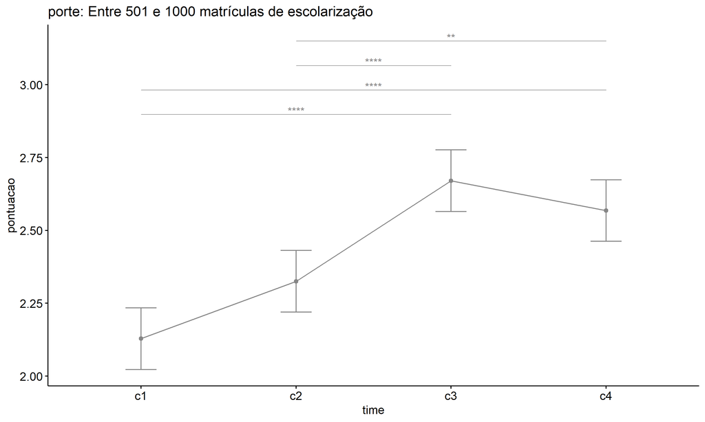

```r
emms.gg <- emms[which(emms$porte == "Entre 501 e 1000 matrículas de escolarização"),]
if (nrow(emms.gg) > 0)
  ggline(emms.gg, x = "time", y = "emmean", color = "#868686FF", ylab = "pontuacao") +
    geom_errorbar(aes(ymin = conf.low, ymax = conf.high),
                  width = 0.2, color = "#868686FF") +
    stat_pvalue_manual(
      add_xy_position(pwc[which(pwc$porte == "Entre 501 e 1000 matrículas de escolarização"),],
                      x = "time", fun = "mean_se"),
      hide.ns = T, color = "#868686FF", tip.length = F) +
    labs(title = "porte: Entre 501 e 1000 matrículas de escolarização")+
    theme(legend.text = element_blank())
```

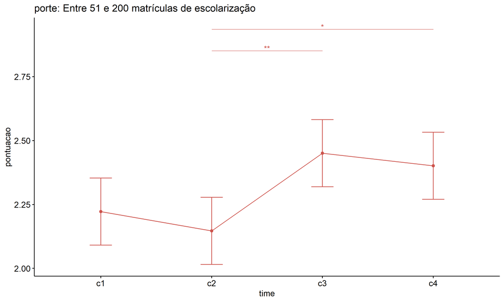

```r
emms.gg <- emms[which(emms$porte == "Entre 51 e 200 matrículas de escolarização"),]
if (nrow(emms.gg) > 0)
  ggline(emms.gg, x = "time", y = "emmean", color = "#CD534CFF", ylab = "pontuacao") +
    geom_errorbar(aes(ymin = conf.low, ymax = conf.high),
                  width = 0.2, color = "#CD534CFF") +
    stat_pvalue_manual(
      add_xy_position(pwc[which(pwc$porte == "Entre 51 e 200 matrículas de escolarização"),],
                      x = "time", fun = "mean_se"),
      hide.ns = T, color = "#CD534CFF", tip.length = F) +
    labs(title = "porte: Entre 51 e 200 matrículas de escolarização")+
    theme(legend.text = element_blank())
```

```r
emms.gg <- emms[which(emms$porte == "Mais de 1000 matrículas de escolarização"),]
if (nrow(emms.gg) > 0)
  ggline(emms.gg, x = "time", y = "emmean", color = "#7AA6DCFF", ylab = "pontuacao") +
    geom_errorbar(aes(ymin = conf.low, ymax = conf.high),
                  width = 0.2, color = "#7AA6DCFF") +
    stat_pvalue_manual(
      add_xy_position(pwc[which(pwc$porte == "Mais de 1000 matrículas de escolarização"),],
                      x = "time", fun = "mean_se"),
      hide.ns = T, color = "#7AA6DCFF", tip.length = F) +
    labs(title = "porte: Mais de 1000 matrículas de escolarização")+
    theme(legend.text = element_blank())
```

## PairWise Computation after removing non.normal data

```r
if (length(non.ids) > 0)
  (pwc2 <- ldat2 %>% group_by(time) %>%
     emmeans_test(pontuacao ~ porte, detailed = T, p.adjust.method = "bonferroni"))
```

```
## # A tibble: 24 × 15
##    time  term  .y.    group1 group2 null.value estimate     se    df conf.low conf.high statistic
##  * <fct> <chr> <chr>  <chr>  <chr>       <dbl>    <dbl>  <dbl> <dbl>    <dbl>     <dbl>     <dbl>
##  1 c1    porte pontu… Até 5… Entre…          0  -0.0462 0.156   4452   -0.351    0.259     -0.297
##  2 c1    porte pontu… Até 5… Entre…          0  -0.0317 0.161   4452   -0.348    0.285     -0.197
##  3 c1    porte pontu… Até 5… Entre…          0  -0.125  0.166   4452   -0.451    0.200     -0.755
##  4 c1    porte pontu… Entre… Entre…          0   0.0144 0.0628  4452   -0.109    0.138      0.230
##  5 c1    porte pontu… Entre… Entre…          0  -0.0793 0.0741  4452   -0.225    0.0661    -1.07
##  6 c1    porte pontu… Entre… Entre…          0  -0.0937 0.0855  4452   -0.261    0.0740    -1.10
##  7 c2    porte pontu… Até 5… Entre…          0  -0.225  0.156   4452   -0.530    0.0805    -1.44
##  8 c2    porte pontu… Até 5… Entre…          0  -0.245  0.161   4452   -0.561    0.0718    -1.52
##  9 c2    porte pontu… Até 5… Entre…          0  -0.0660 0.166   4452   -0.392    0.260     -0.397
## 10 c2    porte pontu… Entre… Entre…          0  -0.0200 0.0628  4452   -0.143    0.103     -0.318
## # ℹ 14 more rows
## # ℹ 3 more variables: p <dbl>, p.adj <dbl>, p.adj.signif <chr>
```

| time | term | .y. | group1 | group2 | null.value | estimate | se | df | conf.low | conf.high | statistic | p | p.adj | p.adj.signif |
| --- | --- | --- | --- | --- | --- | --- | --- | --- | --- | --- | --- | --- | --- | --- |
| c1 | porte | pontuacao | Até 50 matrículas de escolarização | Entre 201 e 500 matrículas de escolarização | 0 | -0.046 | 0.156 | 4452 | -0.351 | 0.259 | -0.297 | 0.767 | 1.000 | ns |
| c1 | porte | pontuacao | Até 50 matrículas de escolarização | Entre 501 e 1000 matrículas de escolarização | 0 | -0.032 | 0.161 | 4452 | -0.348 | 0.285 | -0.197 | 0.844 | 1.000 | ns |
| c1 | porte | pontuacao | Até 50 matrículas de escolarização | Entre 51 e 200 matrículas de escolarização | 0 | -0.125 | 0.166 | 4452 | -0.451 | 0.200 | -0.755 | 0.450 | 1.000 | ns |
| c1 | porte | pontuacao | Entre 201 e 500 matrículas de escolarização | Entre 501 e 1000 matrículas de escolarização | 0 | 0.014 | 0.063 | 4452 | -0.109 | 0.138 | 0.230 | 0.818 | 1.000 | ns |
| c1 | porte | pontuacao | Entre 201 e 500 matrículas de escolarização | Entre 51 e 200 matrículas de escolarização | 0 | -0.079 | 0.074 | 4452 | -0.225 | 0.066 | -1.069 | 0.285 | 1.000 | ns |
| c1 | porte | pontuacao | Entre 501 e 1000 matrículas de escolarização | Entre 51 e 200 matrículas de escolarização | 0 | -0.094 | 0.086 | 4452 | -0.261 | 0.074 | -1.095 | 0.273 | 1.000 | ns |
| c2 | porte | pontuacao | Até 50 matrículas de escolarização | Entre 201 e 500 matrículas de escolarização | 0 | -0.225 | 0.156 | 4452 | -0.530 | 0.081 | -1.443 | 0.149 | 0.894 | ns |
| c2 | porte | pontuacao | Até 50 matrículas de escolarização | Entre 501 e 1000 matrículas de escolarização | 0 | -0.245 | 0.161 | 4452 | -0.561 | 0.072 | -1.516 | 0.130 | 0.778 | ns |
| c2 | porte | pontuacao | Até 50 matrículas de escolarização | Entre 51 e 200 matrículas de escolarização | 0 | -0.066 | 0.166 | 4452 | -0.392 | 0.260 | -0.397 | 0.691 | 1.000 | ns |
| c2 | porte | pontuacao | Entre 201 e 500 matrículas de escolarização | Entre 501 e 1000 matrículas de escolarização | 0 | -0.020 | 0.063 | 4452 | -0.143 | 0.103 | -0.318 | 0.750 | 1.000 | ns |
| c2 | porte | pontuacao | Entre 201 e 500 matrículas de escolarização | Entre 51 e 200 matrículas de escolarização | 0 | 0.159 | 0.074 | 4452 | 0.013 | 0.304 | 2.140 | 0.032 | 0.194 | ns |
| c2 | porte | pontuacao | Entre 501 e 1000 matrículas de escolarização | Entre 51 e 200 matrículas de escolarização | 0 | 0.179 | 0.086 | 4452 | 0.011 | 0.346 | 2.089 | 0.037 | 0.221 | ns |
| c3 | porte | pontuacao | Até 50 matrículas de escolarização | Entre 201 e 500 matrículas de escolarização | 0 | -0.044 | 0.156 | 4452 | -0.349 | 0.262 | -0.280 | 0.779 | 1.000 | ns |
| c3 | porte | pontuacao | Até 50 matrículas de escolarização | Entre 501 e 1000 matrículas de escolarização | 0 | -0.251 | 0.161 | 4452 | -0.568 | 0.065 | -1.557 | 0.120 | 0.717 | ns |
| c3 | porte | pontuacao | Até 50 matrículas de escolarização | Entre 51 e 200 matrículas de escolarização | 0 | -0.031 | 0.166 | 4452 | -0.357 | 0.294 | -0.188 | 0.851 | 1.000 | ns |
| c3 | porte | pontuacao | Entre 201 e 500 matrículas de escolarização | Entre 501 e 1000 matrículas de escolarização | 0 | -0.208 | 0.063 | 4452 | -0.331 | -0.085 | -3.306 | 0.001 | 0.006 | ** |
| c3 | porte | pontuacao | Entre 201 e 500 matrículas de escolarização | Entre 51 e 200 matrículas de escolarização | 0 | 0.012 | 0.074 | 4452 | -0.133 | 0.158 | 0.167 | 0.868 | 1.000 | ns |
| c3 | porte | pontuacao | Entre 501 e 1000 matrículas de escolarização | Entre 51 e 200 matrículas de escolarização | 0 | 0.220 | 0.086 | 4452 | 0.052 | 0.388 | 2.573 | 0.010 | 0.061 | ns |
| c4 | porte | pontuacao | Até 50 matrículas de escolarização | Entre 201 e 500 matrículas de escolarização | 0 | 0.097 | 0.156 | 4452 | -0.208 | 0.402 | 0.624 | 0.532 | 1.000 | ns |
| c4 | porte | pontuacao | Até 50 matrículas de escolarização | Entre 501 e 1000 matrículas de escolarização | 0 | -0.084 | 0.161 | 4452 | -0.401 | 0.232 | -0.523 | 0.601 | 1.000 | ns |
| c4 | porte | pontuacao | Até 50 matrículas de escolarização | Entre 51 e 200 matrículas de escolarização | 0 | 0.083 | 0.166 | 4452 | -0.243 | 0.408 | 0.497 | 0.619 | 1.000 | ns |
| c4 | porte | pontuacao | Entre 201 e 500 matrículas de escolarização | Entre 501 e 1000 matrículas de escolarização | 0 | -0.182 | 0.063 | 4452 | -0.305 | -0.058 | -2.890 | 0.004 | 0.023 | * |
| c4 | porte | pontuacao | Entre 201 e 500 matrículas de escolarização | Entre 51 e 200 matrículas de escolarização | 0 | -0.015 | 0.074 | 4452 | -0.160 | 0.131 | -0.196 | 0.844 | 1.000 | ns |
| c4 | porte | pontuacao | Entre 501 e 1000 matrículas de escolarização | Entre 51 e 200 matrículas de escolarização | 0 | 0.167 | 0.086 | 4452 | -0.001 | 0.335 | 1.953 | 0.051 | 0.306 | ns |

```r
if (length(non.ids) > 0)
  (emms2 <- get_emmeans(pwc2))
```

```
## # A tibble: 16 × 8
##    time  porte                                      emmean     se    df conf.low conf.high method
##    <fct> <fct>                                       <dbl>  <dbl> <dbl>    <dbl>     <dbl> <chr>
##  1 c1    Até 50 matrículas de escolarização           2.10 0.152   4452     1.80      2.40 Emmea…
##  2 c1    Entre 201 e 500 matrículas de escolarizaç…   2.14 0.0326  4452     2.08      2.21 Emmea…
##  3 c1    Entre 501 e 1000 matrículas de escolariza…   2.13 0.0537  4452     2.02      2.23 Emmea…
##  4 c1    Entre 51 e 200 matrículas de escolarização   2.22 0.0666  4452     2.09      2.35 Emmea…
##  5 c2    Até 50 matrículas de escolarização           2.08 0.152   4452     1.78      2.38 Emmea…
##  6 c2    Entre 201 e 500 matrículas de escolarizaç…   2.31 0.0326  4452     2.24      2.37 Emmea…
##  7 c2    Entre 501 e 1000 matrículas de escolariza…   2.33 0.0537  4452     2.22      2.43 Emmea…
##  8 c2    Entre 51 e 200 matrículas de escolarização   2.15 0.0666  4452     2.02      2.28 Emmea…
##  9 c3    Até 50 matrículas de escolarização           2.42 0.152   4452     2.12      2.72 Emmea…
## 10 c3    Entre 201 e 500 matrículas de escolarizaç…   2.46 0.0326  4452     2.40      2.53 Emmea…
## 11 c3    Entre 501 e 1000 matrículas de escolariza…   2.67 0.0537  4452     2.57      2.78 Emmea…
## 12 c3    Entre 51 e 200 matrículas de escolarização   2.45 0.0666  4452     2.32      2.58 Emmea…
## 13 c4    Até 50 matrículas de escolarização           2.48 0.152   4452     2.19      2.78 Emmea…
## 14 c4    Entre 201 e 500 matrículas de escolarizaç…   2.39 0.0326  4452     2.32      2.45 Emmea…
## 15 c4    Entre 501 e 1000 matrículas de escolariza…   2.57 0.0537  4452     2.46      2.67 Emmea…
## 16 c4    Entre 51 e 200 matrículas de escolarização   2.40 0.0666  4452     2.27      2.53 Emmea…
```

| time | porte | emmean | se | df | conf.low | conf.high | method |
| --- | --- | --- | --- | --- | --- | --- | --- |
| c1 | Até 50 matrículas de escolarização | 2.097 | 0.152 | 4452 | 1.798 | 2.395 | Emmeans test |
| c1 | Entre 201 e 500 matrículas de escolarização | 2.143 | 0.033 | 4452 | 2.079 | 2.207 | Emmeans test |
| c1 | Entre 501 e 1000 matrículas de escolarização | 2.129 | 0.054 | 4452 | 2.023 | 2.234 | Emmeans test |
| c1 | Entre 51 e 200 matrículas de escolarização | 2.222 | 0.067 | 4452 | 2.092 | 2.353 | Emmeans test |
| c2 | Até 50 matrículas de escolarização | 2.081 | 0.152 | 4452 | 1.782 | 2.379 | Emmeans test |
| c2 | Entre 201 e 500 matrículas de escolarização | 2.305 | 0.033 | 4452 | 2.241 | 2.369 | Emmeans test |
| c2 | Entre 501 e 1000 matrículas de escolarização | 2.325 | 0.054 | 4452 | 2.220 | 2.431 | Emmeans test |
| c2 | Entre 51 e 200 matrículas de escolarização | 2.147 | 0.067 | 4452 | 2.016 | 2.277 | Emmeans test |
| c3 | Até 50 matrículas de escolarização | 2.419 | 0.152 | 4452 | 2.121 | 2.718 | Emmeans test |
| c3 | Entre 201 e 500 matrículas de escolarização | 2.463 | 0.033 | 4452 | 2.399 | 2.527 | Emmeans test |
| c3 | Entre 501 e 1000 matrículas de escolarização | 2.671 | 0.054 | 4452 | 2.565 | 2.776 | Emmeans test |
| c3 | Entre 51 e 200 matrículas de escolarização | 2.451 | 0.067 | 4452 | 2.320 | 2.581 | Emmeans test |
| c4 | Até 50 matrículas de escolarização | 2.484 | 0.152 | 4452 | 2.185 | 2.782 | Emmeans test |
| c4 | Entre 201 e 500 matrículas de escolarização | 2.387 | 0.033 | 4452 | 2.323 | 2.451 | Emmeans test |
| c4 | Entre 501 e 1000 matrículas de escolarização | 2.568 | 0.054 | 4452 | 2.463 | 2.674 | Emmeans test |
| c4 | Entre 51 e 200 matrículas de escolarização | 2.401 | 0.067 | 4452 | 2.271 | 2.532 | Emmeans test |

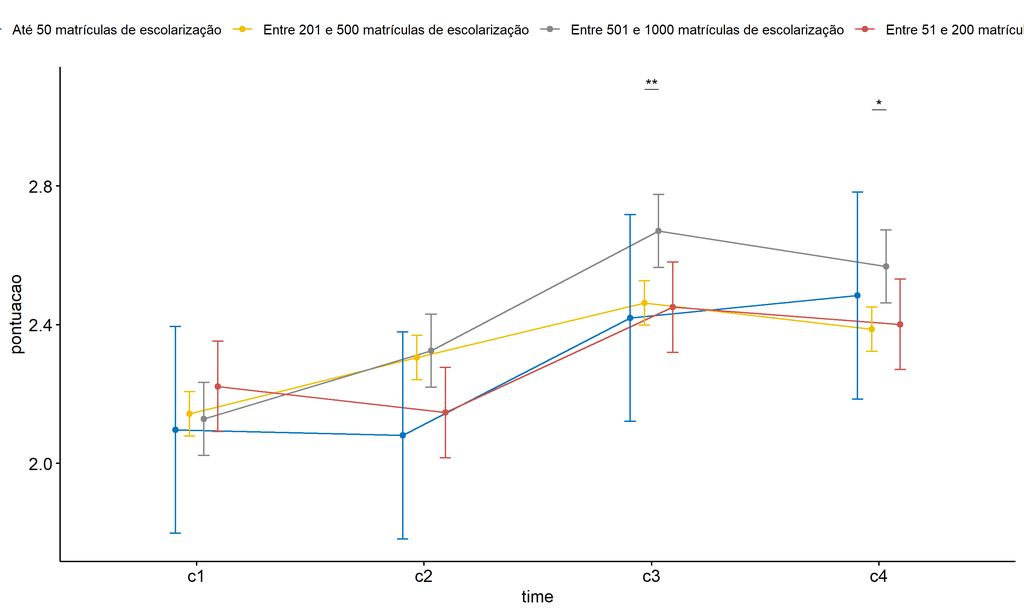

```r
if (length(non.ids) > 0) {
  pwc2 <- add_xy_position(pwc2, x = "time", fun = "mean_se", dodge = 0.25)
  pd2 <- position_dodge(width = 0.25)

  ggline(emms2, x = "time", y = "emmean", color = "porte",
         palette = c("#0073C2FF","#EFC000FF","#868686FF","#CD534CFF","#7AA6DCFF"),
         position = pd, ylab = "pontuacao") +
    geom_errorbar(aes(ymin = conf.low, ymax = conf.high, color = porte),
                position = pd, width = 0.2) +
    stat_pvalue_manual(pwc2, hide.ns = T, tip.length = F, linetype = 1)
}
```

```r
if (length(non.ids) > 0)
  (pwc2 <- ldat2 %>% group_by(porte) %>%
     emmeans_test(pontuacao ~ time, detailed = T, p.adjust.method = "bonferroni"))
```

```
## # A tibble: 24 × 15
##    porte  term  .y.   group1 group2 null.value estimate     se    df conf.low conf.high statistic
##  * <fct>  <chr> <chr> <chr>  <chr>       <dbl>    <dbl>  <dbl> <dbl>    <dbl>     <dbl>     <dbl>
##  1 Até 5… time  pont… c1     c2              0   0.0161 0.215   4452   -0.406    0.438     0.0749
##  2 Até 5… time  pont… c1     c3              0  -0.323  0.215   4452   -0.745    0.0994   -1.50
##  3 Até 5… time  pont… c1     c4              0  -0.387  0.215   4452   -0.809    0.0349   -1.80
##  4 Até 5… time  pont… c2     c3              0  -0.339  0.215   4452   -0.761    0.0833   -1.57
##  5 Até 5… time  pont… c2     c4              0  -0.403  0.215   4452   -0.825    0.0188   -1.87
##  6 Até 5… time  pont… c3     c4              0  -0.0645 0.215   4452   -0.487    0.357    -0.300
##  7 Entre… time  pont… c1     c2              0  -0.162  0.0461  4452   -0.253   -0.0719   -3.52
##  8 Entre… time  pont… c1     c3              0  -0.320  0.0461  4452   -0.410   -0.230    -6.94
##  9 Entre… time  pont… c1     c4              0  -0.244  0.0461  4452   -0.334   -0.153    -5.28
## 10 Entre… time  pont… c2     c3              0  -0.158  0.0461  4452   -0.248   -0.0672   -3.42
## # ℹ 14 more rows
## # ℹ 3 more variables: p <dbl>, p.adj <dbl>, p.adj.signif <chr>
```

| porte | term | .y. | group1 | group2 | null.value | estimate | se | df | conf.low | conf.high | statistic | p | p.adj | p.adj.signif |
| --- | --- | --- | --- | --- | --- | --- | --- | --- | --- | --- | --- | --- | --- | --- |
| Até 50 matrículas de escolarização | time | pontuacao | c1 | c2 | 0 | 0.016 | 0.215 | 4452 | -0.406 | 0.438 | 0.075 | 0.940 | 1.000 | ns |
| Até 50 matrículas de escolarização | time | pontuacao | c1 | c3 | 0 | -0.323 | 0.215 | 4452 | -0.745 | 0.099 | -1.499 | 0.134 | 0.804 | ns |
| Até 50 matrículas de escolarização | time | pontuacao | c1 | c4 | 0 | -0.387 | 0.215 | 4452 | -0.809 | 0.035 | -1.798 | 0.072 | 0.433 | ns |
| Até 50 matrículas de escolarização | time | pontuacao | c2 | c3 | 0 | -0.339 | 0.215 | 4452 | -0.761 | 0.083 | -1.574 | 0.116 | 0.694 | ns |
| Até 50 matrículas de escolarização | time | pontuacao | c2 | c4 | 0 | -0.403 | 0.215 | 4452 | -0.825 | 0.019 | -1.873 | 0.061 | 0.367 | ns |
| Até 50 matrículas de escolarização | time | pontuacao | c3 | c4 | 0 | -0.065 | 0.215 | 4452 | -0.487 | 0.357 | -0.300 | 0.764 | 1.000 | ns |
| Entre 201 e 500 matrículas de escolarização | time | pontuacao | c1 | c2 | 0 | -0.162 | 0.046 | 4452 | -0.253 | -0.072 | -3.519 | 0.000 | 0.003 | ** |
| Entre 201 e 500 matrículas de escolarização | time | pontuacao | c1 | c3 | 0 | -0.320 | 0.046 | 4452 | -0.410 | -0.230 | -6.937 | 0.000 | 0.000 | **** |
| Entre 201 e 500 matrículas de escolarização | time | pontuacao | c1 | c4 | 0 | -0.244 | 0.046 | 4452 | -0.334 | -0.153 | -5.283 | 0.000 | 0.000 | **** |
| Entre 201 e 500 matrículas de escolarização | time | pontuacao | c2 | c3 | 0 | -0.158 | 0.046 | 4452 | -0.248 | -0.067 | -3.418 | 0.001 | 0.004 | ** |
| Entre 201 e 500 matrículas de escolarização | time | pontuacao | c2 | c4 | 0 | -0.081 | 0.046 | 4452 | -0.172 | 0.009 | -1.764 | 0.078 | 0.467 | ns |
| Entre 201 e 500 matrículas de escolarização | time | pontuacao | c3 | c4 | 0 | 0.076 | 0.046 | 4452 | -0.014 | 0.167 | 1.654 | 0.098 | 0.589 | ns |
| Entre 501 e 1000 matrículas de escolarização | time | pontuacao | c1 | c2 | 0 | -0.197 | 0.076 | 4452 | -0.346 | -0.048 | -2.591 | 0.010 | 0.058 | ns |
| Entre 501 e 1000 matrículas de escolarização | time | pontuacao | c1 | c3 | 0 | -0.542 | 0.076 | 4452 | -0.691 | -0.393 | -7.138 | 0.000 | 0.000 | **** |
| Entre 501 e 1000 matrículas de escolarização | time | pontuacao | c1 | c4 | 0 | -0.440 | 0.076 | 4452 | -0.589 | -0.291 | -5.790 | 0.000 | 0.000 | **** |
| Entre 501 e 1000 matrículas de escolarização | time | pontuacao | c2 | c3 | 0 | -0.345 | 0.076 | 4452 | -0.494 | -0.196 | -4.547 | 0.000 | 0.000 | **** |
| Entre 501 e 1000 matrículas de escolarização | time | pontuacao | c2 | c4 | 0 | -0.243 | 0.076 | 4452 | -0.392 | -0.094 | -3.199 | 0.001 | 0.008 | ** |
| Entre 501 e 1000 matrículas de escolarização | time | pontuacao | c3 | c4 | 0 | 0.102 | 0.076 | 4452 | -0.046 | 0.251 | 1.348 | 0.178 | 1.000 | ns |
| Entre 51 e 200 matrículas de escolarização | time | pontuacao | c1 | c2 | 0 | 0.076 | 0.094 | 4452 | -0.109 | 0.260 | 0.803 | 0.422 | 1.000 | ns |
| Entre 51 e 200 matrículas de escolarização | time | pontuacao | c1 | c3 | 0 | -0.228 | 0.094 | 4452 | -0.413 | -0.044 | -2.426 | 0.015 | 0.092 | ns |
| Entre 51 e 200 matrículas de escolarização | time | pontuacao | c1 | c4 | 0 | -0.179 | 0.094 | 4452 | -0.364 | 0.006 | -1.901 | 0.057 | 0.344 | ns |
| Entre 51 e 200 matrículas de escolarização | time | pontuacao | c2 | c3 | 0 | -0.304 | 0.094 | 4452 | -0.489 | -0.119 | -3.229 | 0.001 | 0.008 | ** |
| Entre 51 e 200 matrículas de escolarização | time | pontuacao | c2 | c4 | 0 | -0.255 | 0.094 | 4452 | -0.439 | -0.070 | -2.704 | 0.007 | 0.041 | * |
| Entre 51 e 200 matrículas de escolarização | time | pontuacao | c3 | c4 | 0 | 0.049 | 0.094 | 4452 | -0.135 | 0.234 | 0.524 | 0.600 | 1.000 | ns |

```r
if (length(non.ids) > 0)
  (emms2 <- get_emmeans(pwc2))
```

```
## # A tibble: 16 × 8
##    porte                                      time  emmean     se    df conf.low conf.high method
##    <fct>                                      <fct>  <dbl>  <dbl> <dbl>    <dbl>     <dbl> <chr>
##  1 Até 50 matrículas de escolarização         c1      2.10 0.152   4452     1.80      2.40 Emmea…
##  2 Até 50 matrículas de escolarização         c2      2.08 0.152   4452     1.78      2.38 Emmea…
##  3 Até 50 matrículas de escolarização         c3      2.42 0.152   4452     2.12      2.72 Emmea…
##  4 Até 50 matrículas de escolarização         c4      2.48 0.152   4452     2.19      2.78 Emmea…
##  5 Entre 201 e 500 matrículas de escolarizaç… c1      2.14 0.0326  4452     2.08      2.21 Emmea…
##  6 Entre 201 e 500 matrículas de escolarizaç… c2      2.31 0.0326  4452     2.24      2.37 Emmea…
##  7 Entre 201 e 500 matrículas de escolarizaç… c3      2.46 0.0326  4452     2.40      2.53 Emmea…
##  8 Entre 201 e 500 matrículas de escolarizaç… c4      2.39 0.0326  4452     2.32      2.45 Emmea…
##  9 Entre 501 e 1000 matrículas de escolariza… c1      2.13 0.0537  4452     2.02      2.23 Emmea…
## 10 Entre 501 e 1000 matrículas de escolariza… c2      2.33 0.0537  4452     2.22      2.43 Emmea…
## 11 Entre 501 e 1000 matrículas de escolariza… c3      2.67 0.0537  4452     2.57      2.78 Emmea…
## 12 Entre 501 e 1000 matrículas de escolariza… c4      2.57 0.0537  4452     2.46      2.67 Emmea…
## 13 Entre 51 e 200 matrículas de escolarização c1      2.22 0.0666  4452     2.09      2.35 Emmea…
## 14 Entre 51 e 200 matrículas de escolarização c2      2.15 0.0666  4452     2.02      2.28 Emmea…
## 15 Entre 51 e 200 matrículas de escolarização c3      2.45 0.0666  4452     2.32      2.58 Emmea…
## 16 Entre 51 e 200 matrículas de escolarização c4      2.40 0.0666  4452     2.27      2.53 Emmea…
```

| porte | time | emmean | se | df | conf.low | conf.high | method |
| --- | --- | --- | --- | --- | --- | --- | --- |
| Até 50 matrículas de escolarização | c1 | 2.097 | 0.152 | 4452 | 1.798 | 2.395 | Emmeans test |
| Até 50 matrículas de escolarização | c2 | 2.081 | 0.152 | 4452 | 1.782 | 2.379 | Emmeans test |
| Até 50 matrículas de escolarização | c3 | 2.419 | 0.152 | 4452 | 2.121 | 2.718 | Emmeans test |
| Até 50 matrículas de escolarização | c4 | 2.484 | 0.152 | 4452 | 2.185 | 2.782 | Emmeans test |
| Entre 201 e 500 matrículas de escolarização | c1 | 2.143 | 0.033 | 4452 | 2.079 | 2.207 | Emmeans test |
| Entre 201 e 500 matrículas de escolarização | c2 | 2.305 | 0.033 | 4452 | 2.241 | 2.369 | Emmeans test |
| Entre 201 e 500 matrículas de escolarização | c3 | 2.463 | 0.033 | 4452 | 2.399 | 2.527 | Emmeans test |
| Entre 201 e 500 matrículas de escolarização | c4 | 2.387 | 0.033 | 4452 | 2.323 | 2.451 | Emmeans test |
| Entre 501 e 1000 matrículas de escolarização | c1 | 2.129 | 0.054 | 4452 | 2.023 | 2.234 | Emmeans test |
| Entre 501 e 1000 matrículas de escolarização | c2 | 2.325 | 0.054 | 4452 | 2.220 | 2.431 | Emmeans test |
| Entre 501 e 1000 matrículas de escolarização | c3 | 2.671 | 0.054 | 4452 | 2.565 | 2.776 | Emmeans test |
| Entre 501 e 1000 matrículas de escolarização | c4 | 2.568 | 0.054 | 4452 | 2.463 | 2.674 | Emmeans test |
| Entre 51 e 200 matrículas de escolarização | c1 | 2.222 | 0.067 | 4452 | 2.092 | 2.353 | Emmeans test |
| Entre 51 e 200 matrículas de escolarização | c2 | 2.147 | 0.067 | 4452 | 2.016 | 2.277 | Emmeans test |
| Entre 51 e 200 matrículas de escolarização | c3 | 2.451 | 0.067 | 4452 | 2.320 | 2.581 | Emmeans test |
| Entre 51 e 200 matrículas de escolarização | c4 | 2.401 | 0.067 | 4452 | 2.271 | 2.532 | Emmeans test |

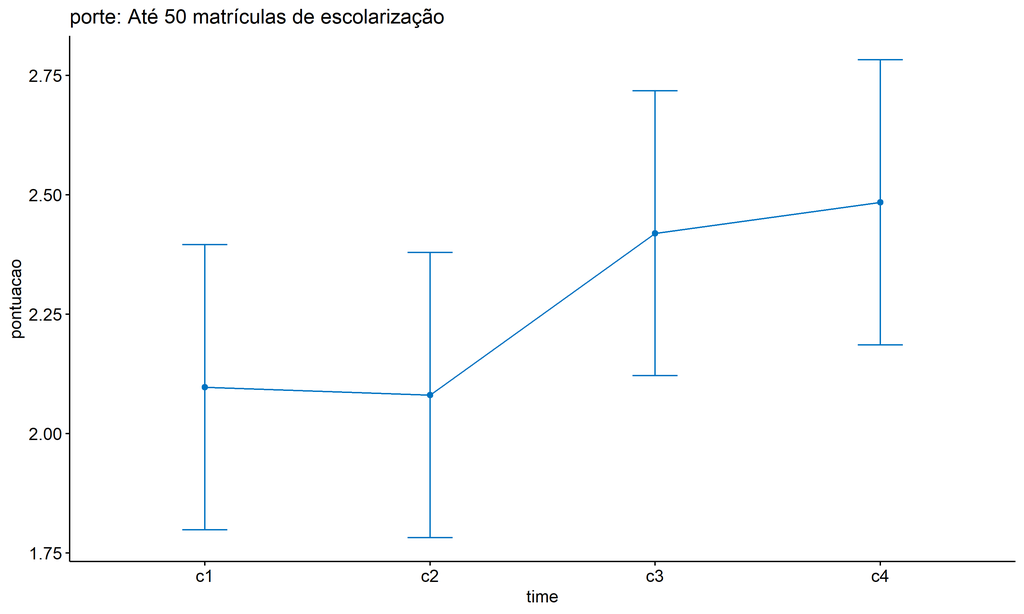

```r
if (length(non.ids) > 0) {
  emms.gg <- emms2[which(emms2$porte == "Até 50 matrículas de escolarização"),]
  if (nrow(emms.gg) > 0)
    ggline(emms.gg, x = "time", y = "emmean", color = "#0073C2FF", ylab = "pontuacao") +
    geom_errorbar(aes(ymin = conf.low, ymax = conf.high),
                  width = 0.2, color = "#0073C2FF") +
    stat_pvalue_manual(
      add_xy_position(pwc[which(pwc$porte == "Até 50 matrículas de escolarização"),],
                      x = "time", fun = "mean_se"),
      hide.ns = T, color = "#0073C2FF", tip.length = F) +
    labs(title = "porte: Até 50 matrículas de escolarização") +
    theme(legend.text = element_blank())
}
```

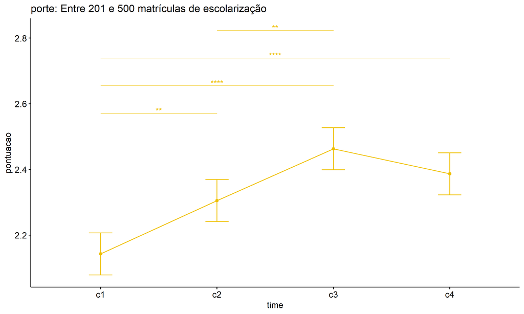

```r
if (length(non.ids) > 0) {
  emms.gg <- emms2[which(emms2$porte == "Entre 201 e 500 matrículas de escolarização"),]
  if (nrow(emms.gg) > 0)
    ggline(emms.gg, x = "time", y = "emmean", color = "#EFC000FF", ylab = "pontuacao") +
    geom_errorbar(aes(ymin = conf.low, ymax = conf.high),
                  width = 0.2, color = "#EFC000FF") +
    stat_pvalue_manual(
      add_xy_position(pwc[which(pwc$porte == "Entre 201 e 500 matrículas de escolarização"),],
                      x = "time", fun = "mean_se"),
      hide.ns = T, color = "#EFC000FF", tip.length = F) +
    labs(title = "porte: Entre 201 e 500 matrículas de escolarização") +
    theme(legend.text = element_blank())
}
```

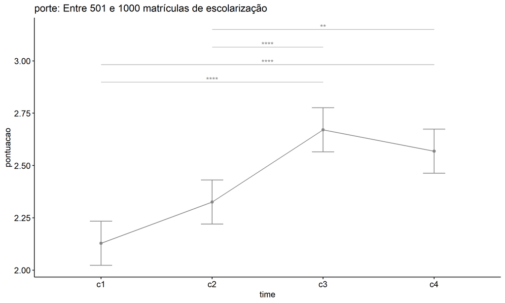

```r
if (length(non.ids) > 0) {
  emms.gg <- emms2[which(emms2$porte == "Entre 501 e 1000 matrículas de escolarização"),]
  if (nrow(emms.gg) > 0)
    ggline(emms.gg, x = "time", y = "emmean", color = "#868686FF", ylab = "pontuacao") +
    geom_errorbar(aes(ymin = conf.low, ymax = conf.high),
                  width = 0.2, color = "#868686FF") +
    stat_pvalue_manual(
      add_xy_position(pwc[which(pwc$porte == "Entre 501 e 1000 matrículas de escolarização"),],
                      x = "time", fun = "mean_se"),
      hide.ns = T, color = "#868686FF", tip.length = F) +
    labs(title = "porte: Entre 501 e 1000 matrículas de escolarização") +
    theme(legend.text = element_blank())
}
```

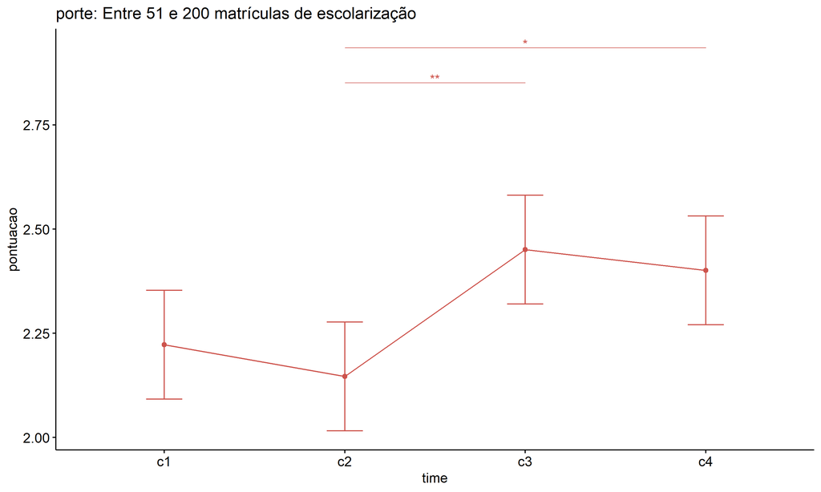

```r
if (length(non.ids) > 0) {
  emms.gg <- emms2[which(emms2$porte == "Entre 51 e 200 matrículas de escolarização"),]
  if (nrow(emms.gg) > 0)
    ggline(emms.gg, x = "time", y = "emmean", color = "#CD534CFF", ylab = "pontuacao") +
    geom_errorbar(aes(ymin = conf.low, ymax = conf.high),
                  width = 0.2, color = "#CD534CFF") +
    stat_pvalue_manual(
      add_xy_position(pwc[which(pwc$porte == "Entre 51 e 200 matrículas de escolarização"),],
                      x = "time", fun = "mean_se"),
      hide.ns = T, color = "#CD534CFF", tip.length = F) +
    labs(title = "porte: Entre 51 e 200 matrículas de escolarização") +
    theme(legend.text = element_blank())
}
```

```r
if (length(non.ids) > 0) {
  emms.gg <- emms2[which(emms2$porte == "Mais de 1000 matrículas de escolarização"),]
  if (nrow(emms.gg) > 0)
    ggline(emms.gg, x = "time", y = "emmean", color = "#7AA6DCFF", ylab = "pontuacao") +
    geom_errorbar(aes(ymin = conf.low, ymax = conf.high),
                  width = 0.2, color = "#7AA6DCFF") +
    stat_pvalue_manual(
      add_xy_position(pwc[which(pwc$porte == "Mais de 1000 matrículas de escolarização"),],
                      x = "time", fun = "mean_se"),
      hide.ns = T, color = "#7AA6DCFF", tip.length = F) +
    labs(title = "porte: Mais de 1000 matrículas de escolarização") +
    theme(legend.text = element_blank())
}
```